# **Stage 04 — Operational Target Investigation**

```
S04_operational_target_investigation.ipynb
```

## **Configuración del Entorno**

### **Importación de librerías**

```python
import sys
import re
#Instalación de librería pandas_market_calendars
#!{sys.executable} -m pip install -q pandas_market_calendars
#print("Librería instalada: pandas_market_calendars")


from functools import reduce
# Utilidades generales
from datetime import datetime, timedelta
import os
import glob
import requests
import warnings
warnings.filterwarnings('ignore')

# Manejo y procesamiento de datos
#import ta
import pandas as pd
import numpy as np
from tabulate import tabulate
import matplotlib.pyplot as plt
# Calendario de mercados
#import pandas_market_calendars as mcal

#from ta.momentum import StochasticOscillator, ROCIndicator
#from ta.volatility import BollingerBands, AverageTrueRange

#from scipy.stats import spearmanr
from __future__ import annotations  # permite type hints modernos (Python < 3.11)
import json                         # para guardar el summary como JSON
import os                           # para leer variables de entorno
from pathlib import Path            # manejo robusto de rutas
import pandas as pd
```

### **Rutas de archivos**

```python
from pathlib import Path

# Buscar la raíz del proyecto
PROJECT_ROOT = Path.cwd()

while PROJECT_ROOT.name != "neural_profit_local":
    PROJECT_ROOT = PROJECT_ROOT.parent

print("Project root:", PROJECT_ROOT)
```

```
Project root: c:\Users\heguu\OneDrive\Escritorio\neural_profit_local
```

### **Carga de dataset `mnq_intraday.parquet`**

```python
MNQ_INTRADAY_PATH = PROJECT_ROOT / "data" / "02_mnq_intraday"
MNQ_INTRADAY_PATH.mkdir(parents=True, exist_ok=True)
MNQ_INTRADAY_PARQUET = MNQ_INTRADAY_PATH / "mnq_intraday.parquet"
```

```python
def load_mnq_parquet(dataset_path):
    os.path.exists(dataset_path)
    print("Archivo encontrado en disco. Cargando dataset local...")
    mnq_parquet = pd.read_parquet(dataset_path)
    return mnq_parquet

mnq_intraday = load_mnq_parquet(MNQ_INTRADAY_PARQUET)
```

```
Archivo encontrado en disco. Cargando dataset local...
```

### **Función para ver información de dataset**

```python
from __future__ import annotations

from dataclasses import dataclass
from typing import Any, Dict, Optional, Tuple

import pandas as pd


def mnq_dataset_info(
    df: pd.DataFrame,
    *,
    name: str = "mnq_raw",
    tz_assume_if_naive: Optional[str] = None,  # ej: "UTC" o "America/New_York"
    day_def: str = "calendar",  # "calendar" (fecha calendario) o "trading" (días con datos)
) -> Dict[str, Any]:
    """
    Resume un dataset OHLCV con DatetimeIndex (ideal para mnq_raw).

    - Si el índice es tz-naive:
        - Si tz_assume_if_naive != None, lo localiza a esa tz.
        - Si no, reporta "tz-naive" (no se puede afirmar horario UTC).
    - Devuelve dict con métricas principales (y lo imprime bonito si se desea).
    """
    if not isinstance(df.index, pd.DatetimeIndex):
        raise TypeError(f"{name}: se requiere DatetimeIndex, recibido: {type(df.index)}")

    idx = df.index

    # --- timezone / UTC info ---
    tzinfo = idx.tz
    if tzinfo is None:
        tz_status = "tz-naive (sin zona horaria)"
        if tz_assume_if_naive:
            idx = idx.tz_localize(tz_assume_if_naive)
            tzinfo = idx.tz
            tz_status = f"localizado como {tzinfo}"
    else:
        tz_status = f"{tzinfo}"

    # --- rango temporal ---
    ts_min = idx.min()
    ts_max = idx.max()

    first_day = ts_min.date()
    last_day = ts_max.date()

    # --- días ---
    if day_def == "calendar":
        total_days = (pd.Timestamp(last_day) - pd.Timestamp(first_day)).days + 1
    elif day_def == "trading":
        total_days = idx.normalize().nunique()
    else:
        raise ValueError("day_def debe ser 'calendar' o 'trading'")

    # --- columnas ---
    columns = list(df.columns)

    # --- checks útiles ---
    n_rows = len(df)
    n_cols = df.shape[1]
    n_missing = int(df.isna().sum().sum())
    missing_by_col = df.isna().sum().to_dict()
    dup_index = int(idx.duplicated().sum())
    is_monotonic = bool(idx.is_monotonic_increasing)

    # Frecuencia estimada (puede fallar si hay huecos grandes)
    freq = pd.infer_freq(idx[: min(50000, len(idx))])  # muestra grande pero acotada

    # Cobertura por día (min/max de hora del día, en tz del índice)
    # (Útil para ver si es 24/7 o horario de sesión)
    tod = pd.Series(idx.time)
    # Convertimos time a minutos del día para resumen robusto
    tod_minutes = pd.Series([t.hour * 60 + t.minute for t in tod])
    typical_minute_min = int(tod_minutes.min())
    typical_minute_max = int(tod_minutes.max())

    # Rango promedio de filas por día (sólo días con datos)
    rows_per_day = df.groupby(idx.normalize()).size()
    rows_per_day_stats = {
        "days_with_data": int(rows_per_day.shape[0]),
        "rows_per_day_min": int(rows_per_day.min()),
        "rows_per_day_p50": float(rows_per_day.median()),
        "rows_per_day_max": int(rows_per_day.max()),
    }

    # Si hay tz, también mostramos rango en UTC
    if tzinfo is not None:
        ts_min_utc = ts_min.tz_convert("UTC")
        ts_max_utc = ts_max.tz_convert("UTC")
        utc_range = (str(ts_min_utc), str(ts_max_utc))
        utc_note = "El índice está tz-aware; el horario UTC es inequívoco."
    else:
        utc_range = None
        utc_note = "El índice es tz-naive; no se puede asegurar si está en UTC sin suposiciones."

    info: Dict[str, Any] = {
        "name": name,
        "shape": (n_rows, n_cols),
        "columns": columns,
        "index_type": type(df.index).__name__,
        "index_tz": tz_status,
        "utc_note": utc_note,
        "datetime_min": str(ts_min),
        "datetime_max": str(ts_max),
        "first_day": str(first_day),
        "last_day": str(last_day),
        "total_days": int(total_days),
        "day_definition": day_def,
        "utc_range_if_applicable": utc_range,
        "is_index_monotonic_increasing": is_monotonic,
        "duplicated_timestamps_in_index": dup_index,
        "inferred_freq_sample": freq,
        "missing_total_cells": n_missing,
        "missing_by_col": missing_by_col,
        "rows_per_day_stats": rows_per_day_stats,
        "time_of_day_minutes_range": {
            "min_minute_of_day": typical_minute_min,
            "max_minute_of_day": typical_minute_max,
        },
    }
    return info


def print_mnq_dataset_info(info: Dict[str, Any]) -> None:
    """Imprime el dict de mnq_dataset_info de forma ordenada."""
    print(f"Dataset: {info['name']}")
    print(f"Shape: {info['shape']}")
    print(f"Columns: {info['columns']}")
    print(f"Index: {info['index_type']} | TZ: {info['index_tz']}")
    print(f"Datetime min/max: {info['datetime_min']}  ->  {info['datetime_max']}")
    print(f"First/Last day: {info['first_day']}  ->  {info['last_day']}")
    print(f"Total days ({info['day_definition']}): {info['total_days']}")
    #print(f"Inferred freq (sample): {info['inferred_freq_sample']}")
    #print(f"Index monotonic increasing: {info['is_index_monotonic_increasing']}")
    #print(f"Duplicated timestamps in index: {info['duplicated_timestamps_in_index']}")
    #print(f"Missing total cells: {info['missing_total_cells']}")
    #print(f"Missing by col: {info['missing_by_col']}")
    #print(f"Rows/day stats: {info['rows_per_day_stats']}")
    print(f"Time-of-day range (minutes): {info['time_of_day_minutes_range']}")
    print(f"UTC note: {info['utc_note']}")
    if info["utc_range_if_applicable"] is not None:
        print(f"UTC range: {info['utc_range_if_applicable'][0]}  ->  {info['utc_range_if_applicable'][1]}")
```

```python
info = mnq_dataset_info(mnq_intraday, name="mnq_intraday", tz_assume_if_naive=None, day_def="trading")
print_mnq_dataset_info(info)
```

```
Dataset: mnq_intraday
Shape: (1024062, 9)
Columns: ['date', 'minute_of_day', 'regime_id', 'open', 'high', 'low', 'close', 'volume', 'contract']
Index: DatetimeIndex | TZ: America/New_York
Datetime min/max: 2020-01-02 04:30:00-05:00  ->  2026-04-17 16:00:00-04:00
First/Last day: 2020-01-02  ->  2026-04-17
Total days (trading): 1482
Time-of-day range (minutes): {'min_minute_of_day': 270, 'max_minute_of_day': 960}
UTC note: El índice está tz-aware; el horario UTC es inequívoco.
UTC range: 2020-01-02 09:30:00+00:00  ->  2026-04-17 20:00:00+00:00
```

### **Validación temporal de dataset `mnq_intraday`**

Valida lo esencial para series temporales antes de construir targets: orden cronológico, duplicados, consistencia por día, monotonicidad de minute_of_day, gaps temporales y saltos sospechosos. Esto es importante porque en trading hay que validar cuidadosamente los timestamps para evitar look-ahead bias, y porque en series temporales el orden secuencial es parte central del problema.

```python
import pandas as pd
import numpy as np

# ============================================================
# Validación temporal de mnq_intraday
# Ejecutar inmediatamente después de:
# mnq_intraday = load_mnq_parquet()
# ============================================================

def validate_mnq_intraday(df: pd.DataFrame, verbose: bool = True) -> dict:
    """
    Valida consistencia temporal básica para un dataset intradía.

    Chequeos:
    1) Índice datetime válido
    2) Orden cronológico global
    3) Duplicados de timestamp
    4) Consistencia de columna `date`
    5) Monotonía de `minute_of_day` dentro de cada día
    6) Duplicados de `minute_of_day` dentro de cada día
    7) Saltos temporales negativos o nulos
    8) Gaps intradía distintos de 1 minuto
    """

    result = {
        "ok": True,
        "checks": {},
        "summary": {},
        "artifacts": {}
    }

    df = df.copy()

    # ------------------------------------------------------------
    # 0) Verificaciones básicas de estructura
    # ------------------------------------------------------------
    required_cols = ["date", "minute_of_day", "open", "high", "low", "close", "volume"]
    missing_cols = [c for c in required_cols if c not in df.columns]
    if missing_cols:
        raise ValueError(f"Faltan columnas requeridas: {missing_cols}")

    if not isinstance(df.index, pd.DatetimeIndex):
        raise TypeError("El índice del DataFrame debe ser un pd.DatetimeIndex")

    if df.empty:
        raise ValueError("El DataFrame está vacío")

    # ------------------------------------------------------------
    # 1) Orden global del índice
    # ------------------------------------------------------------
    is_monotonic = df.index.is_monotonic_increasing
    has_unique_index = df.index.is_unique
    duplicated_index = df.index[df.index.duplicated()].unique()

    result["checks"]["index_is_monotonic_increasing"] = bool(is_monotonic)
    result["checks"]["index_is_unique"] = bool(has_unique_index)
    result["summary"]["n_duplicated_timestamps"] = int(len(duplicated_index))
    result["artifacts"]["duplicated_timestamps"] = duplicated_index

    # Si no está ordenado, mostramos evidencia pero no reordenamos silenciosamente
    if not is_monotonic:
        diffs_ns = pd.Series(df.index.view("i8")).diff()
        bad_order_pos = np.where(diffs_ns <= 0)[0]
        result["artifacts"]["bad_global_order_positions"] = bad_order_pos[:20]
        result["ok"] = False

    if not has_unique_index:
        result["ok"] = False

    # ------------------------------------------------------------
    # 2) Consistencia entre index.date y columna `date`
    # ------------------------------------------------------------
    # Normalizamos ambos a fecha sin hora
    index_dates = pd.Index(df.index.tz_localize(None).date if df.index.tz is not None else df.index.date)
    col_dates = pd.to_datetime(df["date"]).dt.date

    date_match = (index_dates == col_dates).all()
    result["checks"]["date_column_matches_index_date"] = bool(date_match)

    if not date_match:
        mismatch_mask = index_dates != col_dates
        mismatches = df.loc[mismatch_mask, ["date", "minute_of_day", "close"]].head(20)
        result["artifacts"]["date_mismatches_head"] = mismatches
        result["summary"]["n_date_mismatches"] = int(mismatch_mask.sum())
        result["ok"] = False
    else:
        result["summary"]["n_date_mismatches"] = 0

    # ------------------------------------------------------------
    # 3) Diferencias temporales globales
    # ------------------------------------------------------------
    # Trabajamos en segundos
    diffs_sec = pd.Series(df.index).diff().dt.total_seconds()

    n_non_positive_diffs = int((diffs_sec.iloc[1:] <= 0).sum())
    result["checks"]["all_global_time_diffs_positive"] = (n_non_positive_diffs == 0)
    result["summary"]["n_non_positive_global_diffs"] = n_non_positive_diffs

    if n_non_positive_diffs > 0:
        bad_diff_rows = df.iloc[np.where((diffs_sec <= 0).fillna(False))[0][:20]]
        result["artifacts"]["non_positive_global_diffs_head"] = bad_diff_rows
        result["ok"] = False

    # ------------------------------------------------------------
    # 4) Validación por día
    # ------------------------------------------------------------
    daily_stats = []
    bad_minute_order_days = []
    duplicate_minute_days = []
    intraday_gap_rows = []

    grouped = df.groupby("date", sort=False)

    for day, g in grouped:
        g = g.copy()

        # 4.1 orden del índice dentro del día
        idx_mono = g.index.is_monotonic_increasing

        # 4.2 minute_of_day creciente dentro del día
        mod_diff = g["minute_of_day"].diff()
        minute_order_ok = bool((mod_diff.iloc[1:] > 0).all())

        # 4.3 duplicados de minute_of_day dentro del día
        dup_mod = g["minute_of_day"].duplicated().sum()
        has_dup_mod = dup_mod > 0

        # 4.4 gaps intradía del índice
        idx_diff_sec = pd.Series(g.index).diff().dt.total_seconds()
        gap_mask = (~idx_diff_sec.isna()) & (idx_diff_sec != 60)

        n_intraday_gaps = int(gap_mask.sum())

        if not minute_order_ok:
            bad_minute_order_days.append(day)

        if has_dup_mod:
            duplicate_minute_days.append(day)

        if n_intraday_gaps > 0:
            gap_info = g.loc[gap_mask, ["date", "minute_of_day", "open", "high", "low", "close", "volume"]].copy()
            gap_info["gap_seconds"] = idx_diff_sec[gap_mask].values
            intraday_gap_rows.append(gap_info)

        daily_stats.append({
            "date": day,
            "n_rows": len(g),
            "index_monotonic": bool(idx_mono),
            "minute_of_day_monotonic": minute_order_ok,
            "n_duplicate_minute_of_day": int(dup_mod),
            "n_intraday_gaps_not_60s": n_intraday_gaps,
            "minute_min": int(g["minute_of_day"].min()),
            "minute_max": int(g["minute_of_day"].max()),
        })

        if not idx_mono or not minute_order_ok or has_dup_mod:
            result["ok"] = False

    daily_stats_df = pd.DataFrame(daily_stats)

    result["artifacts"]["daily_stats"] = daily_stats_df
    result["summary"]["n_days"] = int(daily_stats_df.shape[0])
    result["summary"]["days_with_bad_minute_order"] = int(len(bad_minute_order_days))
    result["summary"]["days_with_duplicate_minute_of_day"] = int(len(duplicate_minute_days))
    result["summary"]["days_with_intraday_gaps_not_60s"] = int((daily_stats_df["n_intraday_gaps_not_60s"] > 0).sum())

    result["checks"]["all_days_have_monotonic_minute_of_day"] = (len(bad_minute_order_days) == 0)
    result["checks"]["no_duplicate_minute_of_day_within_day"] = (len(duplicate_minute_days) == 0)
    result["checks"]["all_intraday_steps_are_60s_within_day"] = bool(
        (daily_stats_df["n_intraday_gaps_not_60s"] == 0).all()
    )

    result["artifacts"]["bad_minute_order_days"] = bad_minute_order_days
    result["artifacts"]["duplicate_minute_days"] = duplicate_minute_days

    if intraday_gap_rows:
        result["artifacts"]["intraday_gaps_head"] = pd.concat(intraday_gap_rows, axis=0).head(50)
    else:
        result["artifacts"]["intraday_gaps_head"] = pd.DataFrame()

    # ------------------------------------------------------------
    # 5) Resumen global
    # ------------------------------------------------------------
    result["summary"]["n_rows"] = int(len(df))
    result["summary"]["start"] = df.index.min()
    result["summary"]["end"] = df.index.max()

    # ------------------------------------------------------------
    # 6) Reporte por pantalla
    # ------------------------------------------------------------
    if verbose:
        print("=" * 70)
        print("VALIDACIÓN TEMPORAL DE mnq_intraday")
        print("=" * 70)
        print(f"Rows                     : {result['summary']['n_rows']}")
        print(f"Days                     : {result['summary']['n_days']}")
        print(f"Start                    : {result['summary']['start']}")
        print(f"End                      : {result['summary']['end']}")
        print("-" * 70)
        print(f"Index monotonic          : {result['checks']['index_is_monotonic_increasing']}")
        print(f"Index unique             : {result['checks']['index_is_unique']}")
        print(f"Date == index.date       : {result['checks']['date_column_matches_index_date']}")
        print(f"Global diffs > 0         : {result['checks']['all_global_time_diffs_positive']}")
        print(f"minute_of_day monotonic  : {result['checks']['all_days_have_monotonic_minute_of_day']}")
        print(f"No dup minute_of_day     : {result['checks']['no_duplicate_minute_of_day_within_day']}")
        print(f"Intraday steps = 60s     : {result['checks']['all_intraday_steps_are_60s_within_day']}")
        print("-" * 70)
        print(f"Duplicated timestamps    : {result['summary']['n_duplicated_timestamps']}")
        print(f"Date mismatches          : {result['summary']['n_date_mismatches']}")
        print(f"Non-positive global diffs: {result['summary']['n_non_positive_global_diffs']}")
        print(f"Bad minute order days    : {result['summary']['days_with_bad_minute_order']}")
        print(f"Dup minute_of_day days   : {result['summary']['days_with_duplicate_minute_of_day']}")
        print(f"Days with !=60s gaps     : {result['summary']['days_with_intraday_gaps_not_60s']}")
        print("-" * 70)
        print(f"DATASET OK               : {result['ok']}")
        print("=" * 70)

        if result["summary"]["n_duplicated_timestamps"] > 0:
            print("\nDuplicated timestamps (head):")
            print(pd.Index(result["artifacts"]["duplicated_timestamps"][:10]))

        if result["summary"]["n_date_mismatches"] > 0:
            print("\nDate mismatches (head):")
            print(result["artifacts"]["date_mismatches_head"])

        if result["summary"]["days_with_bad_minute_order"] > 0:
            print("\nDays with bad minute_of_day order (head):")
            print(result["artifacts"]["bad_minute_order_days"][:10])

        if result["summary"]["days_with_duplicate_minute_of_day"] > 0:
            print("\nDays with duplicate minute_of_day (head):")
            print(result["artifacts"]["duplicate_minute_days"][:10])

        if not result["artifacts"]["intraday_gaps_head"].empty:
            print("\nIntraday gaps != 60 seconds (head):")
            print(result["artifacts"]["intraday_gaps_head"])

    return result


# ============================================================
# Ejecución inmediata
# ============================================================
validation = validate_mnq_intraday(mnq_intraday, verbose=True)

# Si quiere abortar automáticamente cuando haya problemas críticos:
critical_checks = [
    "index_is_monotonic_increasing",
    "index_is_unique",
    "date_column_matches_index_date",
    "all_global_time_diffs_positive",
    "all_days_have_monotonic_minute_of_day",
    "no_duplicate_minute_of_day_within_day",
]

failed_critical = [k for k in critical_checks if not validation["checks"].get(k, False)]

if failed_critical:
    raise ValueError(
        "Validación temporal fallida. Checks críticos con error: "
        + ", ".join(failed_critical)
    )
```

```
======================================================================
VALIDACIÓN TEMPORAL DE mnq_intraday
======================================================================
Rows                     : 1024062
Days                     : 1482
Start                    : 2020-01-02 04:30:00-05:00
End                      : 2026-04-17 16:00:00-04:00
----------------------------------------------------------------------
Index monotonic          : True
Index unique             : True
Date == index.date       : True
Global diffs > 0         : True
minute_of_day monotonic  : True
No dup minute_of_day     : True
Intraday steps = 60s     : True
----------------------------------------------------------------------
Duplicated timestamps    : 0
Date mismatches          : 0
Non-positive global diffs: 0
Bad minute order days    : 0
Dup minute_of_day days   : 0
Days with !=60s gaps     : 0
----------------------------------------------------------------------
DATASET OK               : True
======================================================================
```

El dataset `mnq_intraday` se encuentra correctamente estructurado para la construcción de targets temporales.

En particular, se verificó que:

- el índice `datetime` está ordenado cronológicamente en forma ascendente,
- no existen timestamps duplicados,
- la columna `date` coincide con la fecha derivada del índice,
- no hay saltos temporales negativos ni diferencias no positivas,
- dentro de cada jornada, `minute_of_day` es estrictamente creciente,
- no existen duplicados de `minute_of_day` dentro de un mismo día,
- y todos los pasos intradía son consistentes con una frecuencia de 1 minuto.

Por lo tanto, el dataset queda validado como temporalmente consistente y apto para construir targets forward del tipo `delta_h` y `ret_h`, siempre que dichos horizontes se calculen respetando los límites de cada jornada y evitando cruces entre días.

# **1. Introducción**

El objetivo de este capítulo es investigar targets operativos candidatos para futuros modelos predictivos aplicados al contrato intradiario MNQ.

A diferencia de etapas posteriores, en este capítulo todavía no se evaluará la relación entre variables predictivas y targets. Es decir, no se analizarán features, indicadores técnicos, correlaciones, Information Coefficient ni modelos de Machine Learning.

El foco de este stage será exclusivamente el target: cómo se construye, qué representa, qué distribución tiene, qué tan balanceado es, qué tan estable resulta a lo largo del tiempo y qué tan razonable parece desde una perspectiva operativa.

Esta separación es importante porque, antes de preguntarnos qué variables pueden predecir algo, primero necesitamos definir con claridad qué queremos predecir.

En este capítulo se investigarán tres familias de targets:

```
    DIR  = Dirección significativa con umbral
    BAR  = Resultado por barreras TP/SL
    OPC  = Target operativo combinado
```

**Este stage toma como insumo los thresholds operativos calibrados previamente en el Stage 03, los cuales serán utilizados para transformar excursiones futuras del precio en targets discretos evaluables.**

## 1.1. DIR: Dirección significativa con umbral

El target `DIR` tiene como objetivo clasificar la dirección relevante del movimiento futuro del precio dentro de un horizonte operativo `H`.

La pregunta que busca responder es:

**¿El precio se movió lo suficiente hacia arriba, hacia abajo o no presentó un movimiento relevante dentro del horizonte evaluado?**

Los valores posibles del target son:

| Valor | Interpretación |
| --- | --- |
| `1` | Movimiento alcista significativo. Posible escenario LONG. |
| `-1` | Movimiento bajista significativo. Posible escenario SHORT. |
| `0` | Movimiento no significativo. No existe una dirección operativa clara. |

La clave de `DIR` es que no intenta predecir simplemente si el precio sube o baja en términos absolutos. Su objetivo es identificar si el movimiento futuro supera un umbral mínimo de relevancia operativa.

De esta forma, se filtran movimientos pequeños que podrían corresponder a ruido de mercado y se concentra el análisis en desplazamientos que, al menos desde el punto de vista del target, tienen mayor sentido operativo.

Es importante remarcar que `DIR` no representa todavía una estrategia de trading ni una orden de ejecución. Es una etiqueta candidata que permitirá estudiar si existen movimientos futuros suficientemente relevantes y direccionales para ser modelados posteriormente.

## 1.2. BAR: Resultado por barreras TP/SL

El target `BAR` tiene como objetivo evaluar el resultado operativo de una operación hipotética dentro de un horizonte `H`, considerando la secuencia interna del precio.

La pregunta que busca responder es:

**Si se entra en una operación, ¿qué ocurre primero dentro del horizonte evaluado: Take Profit, Stop Loss o ninguno de los dos eventos?**

Los valores posibles del target son:

| Valor | Interpretación |
| --- | --- |
| `1` | Se alcanza primero el Take Profit. Trade exitoso. |
| `-1` | Se alcanza primero el Stop Loss. Trade fallido. |
| `0` | No se alcanza ni TP ni SL dentro del horizonte. Trade sin resolución operativa clara. |

A diferencia de un target basado únicamente en el precio final del horizonte, `BAR` analiza la trayectoria interna del precio. Esto permite determinar qué evento ocurre primero dentro de la ventana futura: el objetivo de ganancia, la barrera de pérdida o ninguno de los dos.

Por este motivo, `BAR` se aproxima más a una lógica real de ejecución. No solo interesa hacia dónde se movió el precio, sino si ese movimiento habría permitido alcanzar un objetivo operativo antes de tocar una barrera de riesgo.

Es importante remarcar que `BAR` requiere definir previamente la dirección de la operación hipotética. Para una operación LONG, el Take Profit se ubica por encima del precio de entrada y el Stop Loss por debajo. Para una operación SHORT, ocurre lo contrario. Por lo tanto, este target depende de una regla previa que determine el lado de la operación evaluada.

## 1.3. OPC: Target operativo combinado

El target `OPC` representa un target operativo combinado. Su objetivo es integrar dos dimensiones del problema:

```
    DIR = dirección operativa del movimiento futuro
    BAR = resultado operativo asociado a esa dirección
```

A diferencia de `DIR`, que solo indica si existió un movimiento significativo hacia arriba o hacia abajo, y de `BAR`, que evalúa si una operación habría alcanzado primero el Take Profit o el Stop Loss, `OPC` combina ambas ideas en una única categoría operativa.

La pregunta que busca responder es:

**¿Qué tipo de evento operativo ocurrió dentro del horizonte evaluado?**

Conceptualmente, `OPC` se calcula a partir de la combinación entre `DIR` y `BAR`. Es decir, primero se identifica la dirección operativa del movimiento futuro mediante `DIR`, y luego se evalúa el resultado operativo de esa dirección mediante `BAR`.

La codificación base considerada es:

```
    DIR =  1  → dirección LONG
    DIR = -1  → dirección SHORT
    DIR =  0  → sin dirección operativa clara

    BAR =  1  → Take Profit alcanzado primero
    BAR = -1  → Stop Loss alcanzado primero
    BAR =  0  → sin resolución operativa
```

Por lo tanto, las combinaciones conceptuales de `OPC` son:

| DIR | BAR | Etiqueta lógica | Interpretación |
| --- | --- | --- | --- |
| `1` | `1` | `LONG_TP` | Movimiento LONG significativo con Take Profit alcanzado primero. |
| `1` | `-1` | `LONG_SL` | Movimiento LONG significativo con Stop Loss alcanzado primero. |
| `-1` | `1` | `SHORT_TP` | Movimiento SHORT significativo con Take Profit alcanzado primero. |
| `-1` | `-1` | `SHORT_SL` | Movimiento SHORT significativo con Stop Loss alcanzado primero. |
| `0` | cualquiera | `NO_TRADE` | Sin operación válida por ausencia de dirección operativa clara. |
| cualquiera | `0` | `NO_TRADE` | Sin resolución operativa dentro del horizonte evaluado. |

Es importante aclarar que no se utilizarán etiquetas lógicas del tipo `11`, `10`, `-11` o `-10`, ya que podrían generar confusión con la definición original de `BAR`. En este estudio, `BAR = -1` representa Stop Loss alcanzado primero, mientras que `BAR = 0` representa ausencia de resolución operativa. Por lo tanto, una etiqueta como `10` podría interpretarse erróneamente como `DIR = 1` y `BAR = 0`, cuando en realidad se quiere representar un LONG perdedor.

Para evitar esta ambigüedad, se utilizarán etiquetas nominales explícitas:

```
    LONG_TP
    LONG_SL
    SHORT_TP
    SHORT_SL
    NO_TRADE
```

Estas etiquetas pueden codificarse posteriormente como clases numéricas:

| Clase OPC | Etiqueta lógica | Interpretación |
| --- | --- | --- |
| `0` | `NO_TRADE` | No trade / sin resolución operativa |
| `1` | `LONG_TP` | LONG ganador |
| `2` | `LONG_SL` | LONG perdedor |
| `3` | `SHORT_TP` | SHORT ganador |
| `4` | `SHORT_SL` | SHORT perdedor |

La interpretación correcta es que `OPC` no predice una magnitud ni un retorno continuo. Predice una categoría operativa.

Por este motivo, las clases numéricas no deben interpretarse como valores ordinales. Por ejemplo, la clase `4` no es mayor que la clase `1`; simplemente representa otro tipo de evento. En etapas posteriores, si se entrena un modelo sobre `OPC`, deberá tratarse como un problema de clasificación multiclase nominal.

## 1.4. Objetivo del capítulo

El objetivo de este capítulo es evaluar y comparar las propiedades estadísticas y operativas de los targets `DIR`, `BAR` y `OPC`.

En particular, se busca responder preguntas como:

- ¿Qué tan balanceadas se encuentran las clases de cada target?
- ¿Qué porcentaje de observaciones genera una señal operable?
- ¿Cómo cambian los targets según el horizonte evaluado?
- ¿Qué tan estables son sus distribuciones a través del tiempo?
- ¿Qué diferencias aparecen por régimen intradiario?
- ¿Qué diferencias aparecen por contrato?
- ¿Qué ocurre en períodos extremos o de comportamiento particular, como `2022`, `2025Q2` y `2026`?
- ¿Qué target parece más claro, más estable y más útil desde una perspectiva operativa?

La respuesta a estas preguntas permitirá identificar targets candidatos para las siguientes etapas del proyecto.

Es importante remarcar que el análisis de períodos posteriores al período de desarrollo, como `2025` y `2026`, deberá interpretarse como una evaluación de validación o estrés fuera de muestra. Estos períodos no deberán utilizarse para diseñar thresholds, ajustar reglas ni seleccionar targets de forma retroactiva.

## 1.5. Metodología general

La investigación se realizará utilizando el dataset intradiario del MNQ previamente preparado y analizado en stages anteriores.

Para cada target se seguirá una metodología común:

1. Definición conceptual del target.
2. Construcción práctica del target.
3. Validación de consistencia.
4. Análisis de distribución de clases.
5. Evaluación de frecuencia operativa.
6. Análisis por horizonte.
7. Análisis por año.
8. Análisis por régimen intradiario.
9. Análisis por contrato.
10. Análisis por combinaciones de contexto.
11. Comparación entre targets.
12. Selección preliminar de targets candidatos.

La lógica será avanzar desde lo más simple hacia lo más operativo. Primero se analizará `DIR`, que permite estudiar la dirección significativa del movimiento futuro. Luego se evaluará `BAR`, que incorpora la lógica de barreras tipo Take Profit y Stop Loss. Finalmente, se analizará `OPC`, que combina dirección y resultado operativo en una única categoría multiclase.

En esta etapa no se evaluará todavía qué variables pueden predecir estos targets. Tampoco se entrenarán modelos ni se seleccionarán features. Ese análisis se realizará posteriormente, una vez que los targets hayan sido definidos, construidos y validados.

## 1.6. Restricción temporal, no cruce de días y prevención de leakage

Un aspecto fundamental de esta investigación es garantizar que la construcción de los targets respete la estructura temporal real de los mercados.

Todos los targets deberán construirse sin cruzar días. Esto significa que cada observación solo podrá utilizar información futura perteneciente a su mismo trading day.

Si el horizonte requerido para calcular un target excede el final de la sesión correspondiente, esa observación será considerada inválida y se marcará como valor faltante.

Este criterio garantiza que:

- No exista contaminación entre sesiones consecutivas.
- Las observaciones sean temporalmente consistentes.
- Los targets respeten una lógica operativa realista.
- No se utilice información futura mal alineada.
- Los futuros modelos no sean entrenados con datos contaminados por leakage.

Además, debe mantenerse la separación temporal definida previamente en el proyecto. El período `2020-2024` corresponde al período de desarrollo, utilizado para diseñar y analizar los targets. En cambio, el período `2025-2026` debe quedar reservado para evaluación posterior fuera de muestra.

Por lo tanto, la construcción y validación inicial de los targets deberá evitar cualquier decisión basada en el comportamiento del período final de test. Esto incluye la selección de thresholds, la elección de reglas operativas y la selección preliminar de targets candidatos.

En síntesis, este capítulo no busca todavía entrenar modelos ni seleccionar features. Su objetivo es definir, construir y evaluar targets operativos candidatos de forma rigurosa, estadística y contextual, manteniendo una separación clara entre diseño, validación y evaluación final.

## 1.7. Principio metodológico: targets separados y features causales

Antes de continuar con la construcción y análisis de los targets, es importante dejar explícito un principio metodológico central para este estudio.

Todos los modelos predictivos que se desarrollen en etapas posteriores deberán utilizar únicamente información disponible en el instante `t`. Esto significa que las variables explicativas deberán construirse a partir de datos históricos o contemporáneos al momento de decisión, como precios `OHLCV`, contexto temporal, régimen intradiario, contrato, volumen, volatilidad reciente, momentum e indicadores técnicos calculados hasta `t`.

Por lo tanto, ningún modelo deberá utilizar información futura ni variables derivadas de la ventana que se intenta predecir.

La regla general es:

```
    Para cualquier modelo predictivo, las features deben estar disponibles en t.

    Nunca se deben usar targets DIR, BAR u OPC como features.

    Nunca se debe usar la predicción de un modelo como feature de entrada de otro modelo en esta etapa.
```

Conceptualmente, cada target deberá evaluarse como un problema predictivo independiente:

```
    Modelo DIR:
    X_t = OHLCV histórico + contexto + indicadores calculados hasta t
    y   = DIR

    Modelo BAR:
    X_t = OHLCV histórico + contexto + indicadores calculados hasta t
    y   = BAR

    Modelo OPC:
    X_t = OHLCV histórico + contexto + indicadores calculados hasta t
    y   = OPC
```

En cambio, no se utilizarán esquemas como los siguientes:

```
    Modelo BAR:
    X_t = features + DIR real

    Modelo BAR:
    X_t = features + predicción DIR

    Modelo OPC:
    X_t = features + DIR + BAR

    Modelo OPC:
    X_t = features + predicción DIR + predicción BAR
```

La diferencia metodológica es importante. `BAR` está condicionado por `DIR` en su construcción, porque primero se necesita conocer si la operación es `LONG` o `SHORT` para evaluar las barreras de `Take Profit` y `Stop Loss`. Sin embargo, esto no significa que `DIR` pueda utilizarse como variable explicativa para predecir `BAR`.

En otras palabras:

```
    DIR se usa para construir BAR.
    DIR no se usa para predecir BAR.
```

De forma equivalente, `OPC` se construye combinando `DIR` y `BAR`, pero estos targets no deben utilizarse como entradas para predecir `OPC`.

```
    DIR y BAR se usan para construir OPC.
    DIR y BAR no se usan como inputs para predecir OPC.
```

Esto evita introducir información del propio target dentro del modelo y reduce el riesgo de `data leakage`. También evita construir un sistema artificialmente favorecido, donde un modelo se beneficie directa o indirectamente de información que no estaría disponible en una situación real de decisión.

Por lo tanto, en este estudio los targets `DIR`, `BAR` y `OPC` deberán entenderse como alternativas de modelado independientes. En etapas posteriores se podrá evaluar si existe señal predictiva para cada uno de ellos, pero siempre respetando la misma regla: las features deben ser causales y estar disponibles en el instante `t`.

Cualquier arquitectura encadenada, donde una predicción de `DIR` alimente un modelo de `BAR`, o donde predicciones de `DIR` y `BAR` alimenten un modelo de `OPC`, deberá considerarse una investigación posterior y separada. No forma parte de la evaluación inicial de targets de este stage.

En síntesis, el principio metodológico de esta notebook es:

```
    Targets separados.
    Features causales.
    Sin encadenamiento de modelos.
    Sin uso de targets como variables explicativas.
```

# **2. Construcción práctica de targets**

Una vez establecidas las definiciones conceptuales de los targets candidatos, el siguiente paso consiste en describir su construcción práctica a partir de los datos intradiarios del MNQ.

En este capítulo se investigarán únicamente los targets. Todavía no se evaluará la relación entre variables predictivas y targets, ni se entrenarán modelos de Machine Learning. El objetivo de esta etapa es construir, validar y analizar estadísticamente los targets operativos candidatos.

La construcción de los targets se realizará a partir de dos insumos principales: el dataset intradiario base del MNQ y la tabla de thresholds operativos calibrada previamente en el Stage 03. Los thresholds utilizados provienen exclusivamente del período de desarrollo `2020-2024` y permanecerán fijos al aplicarse sobre el resto del dataset.

Los targets podrán construirse sobre todo el período disponible, incluyendo `2025` y `2026`. Sin embargo, estos últimos períodos serán utilizados únicamente para evaluación posterior fuera de muestra, no para recalibrar thresholds, ajustar reglas ni seleccionar targets de forma retroactiva.

Los targets evaluados serán:

```
    DIR  = Dirección significativa con umbral
    BAR  = Resultado por barreras TP/SL
    OPC  = Target operativo combinado
```

## 2.1. Dataset base

La investigación utiliza datos intradiarios del contrato de futuros MNQ, almacenados en el dataset `mnq_intraday`.

Cada observación representa una vela temporal de un minuto e incluye información OHLCV:

```
    open
    high
    low
    close
    volume
```

Además, el dataset incluye variables de contexto temporal y operativo, tales como:

[output not shown]

Estas variables no se utilizarán todavía como features predictivas. En este capítulo se emplearán principalmente para construir, segmentar y analizar la distribución de los targets por año, régimen intradiario, contrato y otros contextos relevantes.

Los targets serán construidos sobre el dataset intradiario disponible completo. Esto permite generar etiquetas para todo el período analizado, incluyendo tanto el período de desarrollo como el período final de evaluación. Sin embargo, el uso metodológico de cada período será diferente: `2020-2024` corresponde al período de desarrollo, mientras que `2025-2026` quedará reservado para evaluación posterior fuera de muestra.

Los datasets con los targets calculados serán guardados en las siguientes rutas:

```
    MNQ_TARGETS_PATH = PROJECT_ROOT / "data" / "04_mnq_targets"
    MNQ_TARGETS_PATH.mkdir(parents=True, exist_ok=True)

    MNQ_TARGETS_DIR_PARQUET = MNQ_TARGETS_PATH / "mnq_targets_dir.parquet"
    MNQ_TARGETS_BAR_PARQUET = MNQ_TARGETS_PATH / "mnq_targets_bar.parquet"
    MNQ_TARGETS_OPC_PARQUET = MNQ_TARGETS_PATH / "mnq_targets_opc.parquet"

    MNQ_TARGETS_ALL_PARQUET = MNQ_TARGETS_PATH / "mnq_targets_all.parquet"
```

Los archivos individuales permitirán analizar cada familia de targets por separado. Adicionalmente, se guardará un dataset consolidado, `mnq_targets_all.parquet`, que integrará los targets `DIR`, `BAR` y `OPC` en una única tabla. Este archivo será útil para realizar comparaciones generales entre targets sin necesidad de unir manualmente los resultados en etapas posteriores.

## 2.2. Dataset de thresholds operativos

Además del dataset intradiario base, la construcción de los targets requiere utilizar los thresholds operativos calibrados previamente en el Stage 03.

Estos thresholds fueron calculados exclusivamente con observaciones del período de desarrollo `2020-2024`. Por lo tanto, representan valores definidos antes de la evaluación final y permanecerán fijos al aplicarse sobre el resto del dataset, incluyendo `2025` y `2026`.

Las tablas finales de thresholds fueron guardadas en las siguientes rutas:

```
    MNQ_THRESHOLDS_PATH = PROJECT_ROOT / "data" / "03_mnq_thresholds"

    MNQ_THRESHOLDS_GLOBAL_BENCHMARK_PARQUET = (
        MNQ_THRESHOLDS_PATH / "mnq_thresholds_global_benchmark.parquet"
    )

    MNQ_THRESHOLDS_REGIME_PRIMARY_PARQUET = (
        MNQ_THRESHOLDS_PATH / "mnq_thresholds_regime_primary.parquet"
    )

    MNQ_THRESHOLDS_REGIME_ROBUST_CHECK_PARQUET = (
        MNQ_THRESHOLDS_PATH / "mnq_thresholds_regime_robust_check.parquet"
    )

    MNQ_THRESHOLDS_FINAL_CANDIDATES_PARQUET = (
        MNQ_THRESHOLDS_PATH / "mnq_thresholds_final_candidates.parquet"
    )

    MNQ_THRESHOLDS_FINAL_CANDIDATES_CSV = (
        MNQ_THRESHOLDS_PATH / "mnq_thresholds_final_candidates.csv"
    )

    MNQ_THRESHOLDS_FINAL_SUMMARY_JSON = (
        MNQ_THRESHOLDS_PATH / "mnq_thresholds_final_summary.json"
    )
```

La tabla principal para la construcción de targets será:

```
    MNQ_THRESHOLDS_REGIME_PRIMARY_PARQUET
```

Esta tabla contiene la metodología principal seleccionada para Stage 04:

```
    threshold_method = regime_pooled_2020_2024
    threshold_scope  = regime
    selection_period = development_2020_2024
    threshold_type   = common
    threshold_col    = threshold_common_pts
```

La lógica principal consiste en utilizar thresholds por régimen intradiario. Esto significa que cada target no se construye con un único threshold global, sino con un threshold condicionado por:

```
    horizon
    percentile
    regime_id
```

Por ejemplo, el target `DIR p50 h30` representa una sola definición de target, pero internamente utiliza distintos thresholds según el régimen intradiario correspondiente a cada observación.

La tabla consolidada final, `mnq_thresholds_final_candidates.parquet`, contiene todas las metodologías seleccionadas para Stage 04:

| Método | Rol | Uso |
| --- | --- | --- |
| `regime_pooled_2020_2024` | Principal | Construcción principal de targets por régimen |
| `global_pooled_2020_2024` | Benchmark | Comparación contra threshold global |
| `regime_median_year_2020_2024` | Control robusto | Validación de robustez frente a años extremos |

Para la construcción principal de `DIR`, `BAR` y `OPC`, se utilizará inicialmente la columna:

```
    threshold_common_pts
```

Esta columna representa un threshold común de relevancia operativa y será aplicada según la combinación correspondiente de horizonte, percentil y régimen intradiario.

Los horizontes y percentiles principales definidos para Stage 04 son:

```
    horizons    = [30, 60, 90]
    percentiles = [40, 50, 60]
```

De esta forma, los thresholds quedan congelados antes de construir los targets sobre el dataset completo. Esto evita que el período final de evaluación influya en la definición de los targets y reduce el riesgo de leakage o ajuste retroactivo.

### 2.2.1 Carga de thersholds operativos

```python
# 2.2.1 Carga de thersholds operativos
# ============================================================

import json
from pathlib import Path

import pandas as pd


# ------------------------------------------------------------
# Rutas de thresholds generadas en Stage 03
# ------------------------------------------------------------

MNQ_THRESHOLDS_PATH = PROJECT_ROOT / "data" / "03_mnq_thresholds"

MNQ_THRESHOLDS_GLOBAL_BENCHMARK_PARQUET = (
    MNQ_THRESHOLDS_PATH / "mnq_thresholds_global_benchmark.parquet"
)

MNQ_THRESHOLDS_REGIME_PRIMARY_PARQUET = (
    MNQ_THRESHOLDS_PATH / "mnq_thresholds_regime_primary.parquet"
)

MNQ_THRESHOLDS_REGIME_ROBUST_CHECK_PARQUET = (
    MNQ_THRESHOLDS_PATH / "mnq_thresholds_regime_robust_check.parquet"
)

MNQ_THRESHOLDS_FINAL_CANDIDATES_PARQUET = (
    MNQ_THRESHOLDS_PATH / "mnq_thresholds_final_candidates.parquet"
)

MNQ_THRESHOLDS_FINAL_CANDIDATES_CSV = (
    MNQ_THRESHOLDS_PATH / "mnq_thresholds_final_candidates.csv"
)

MNQ_THRESHOLDS_FINAL_SUMMARY_JSON = (
    MNQ_THRESHOLDS_PATH / "mnq_thresholds_final_summary.json"
)


# ------------------------------------------------------------
# Funciones auxiliares de carga
# ------------------------------------------------------------

def load_parquet_checked(path, name):
    """
    Carga un archivo parquet y valida que exista en disco.
    """
    path = Path(path)

    if not path.exists():
        raise FileNotFoundError(f"No se encontró el archivo {name}: {path}")

    print(f"Cargando {name}...")
    print(f"Ruta: {path}")

    df = pd.read_parquet(path)

    print(f"{name} cargado correctamente.")
    print(f"Filas: {df.shape[0]:,}")
    print(f"Columnas: {df.shape[1]:,}")
    print("-" * 80)

    return df


def load_csv_checked(path, name):
    """
    Carga un archivo CSV y valida que exista en disco.
    """
    path = Path(path)

    if not path.exists():
        raise FileNotFoundError(f"No se encontró el archivo {name}: {path}")

    print(f"Cargando {name}...")
    print(f"Ruta: {path}")

    df = pd.read_csv(path)

    print(f"{name} cargado correctamente.")
    print(f"Filas: {df.shape[0]:,}")
    print(f"Columnas: {df.shape[1]:,}")
    print("-" * 80)

    return df


def load_json_checked(path, name):
    """
    Carga un archivo JSON y valida que exista en disco.
    """
    path = Path(path)

    if not path.exists():
        raise FileNotFoundError(f"No se encontró el archivo {name}: {path}")

    print(f"Cargando {name}...")
    print(f"Ruta: {path}")

    with path.open("r", encoding="utf-8") as f:
        data = json.load(f)

    print(f"{name} cargado correctamente.")
    print("-" * 80)

    return data


# ------------------------------------------------------------
# Carga de datasets de thresholds
# ------------------------------------------------------------

df_thresholds_global_benchmark = load_parquet_checked(
    MNQ_THRESHOLDS_GLOBAL_BENCHMARK_PARQUET,
    "df_thresholds_global_benchmark"
)

df_thresholds_regime_primary = load_parquet_checked(
    MNQ_THRESHOLDS_REGIME_PRIMARY_PARQUET,
    "df_thresholds_regime_primary"
)

df_thresholds_regime_robust_check = load_parquet_checked(
    MNQ_THRESHOLDS_REGIME_ROBUST_CHECK_PARQUET,
    "df_thresholds_regime_robust_check"
)

df_thresholds_final_candidates = load_parquet_checked(
    MNQ_THRESHOLDS_FINAL_CANDIDATES_PARQUET,
    "df_thresholds_final_candidates"
)

df_thresholds_final_candidates_csv = load_csv_checked(
    MNQ_THRESHOLDS_FINAL_CANDIDATES_CSV,
    "df_thresholds_final_candidates_csv"
)

thresholds_final_summary = load_json_checked(
    MNQ_THRESHOLDS_FINAL_SUMMARY_JSON,
    "thresholds_final_summary"
)


# ------------------------------------------------------------
# Validación básica de las tablas cargadas
# ------------------------------------------------------------

print("VALIDACIÓN BÁSICA DE THRESHOLDS")
print("=" * 80)

threshold_tables = {
    "global_benchmark": df_thresholds_global_benchmark,
    "regime_primary": df_thresholds_regime_primary,
    "regime_robust_check": df_thresholds_regime_robust_check,
    "final_candidates": df_thresholds_final_candidates,
    "final_candidates_csv": df_thresholds_final_candidates_csv,
}

for name, df in threshold_tables.items():
    print(f"\nTabla: {name}")
    print(f"Filas: {df.shape[0]:,}")
    print(f"Columnas: {df.shape[1]:,}")

    if "horizon" in df.columns:
        print(f"Horizontes: {sorted(df['horizon'].dropna().astype(int).unique().tolist())}")

    if "percentile" in df.columns:
        print(f"Percentiles: {sorted(df['percentile'].dropna().astype(int).unique().tolist())}")

    if "threshold_method" in df.columns:
        print(f"Métodos: {df['threshold_method'].dropna().unique().tolist()}")

    if "threshold_scope" in df.columns:
        print(f"Scopes: {df['threshold_scope'].dropna().unique().tolist()}")

    if "threshold_common_pts" in df.columns:
        missing_common = df["threshold_common_pts"].isna().sum()
        non_positive_common = (df["threshold_common_pts"] <= 0).sum()

        print(f"threshold_common_pts faltantes: {missing_common}")
        print(f"threshold_common_pts no positivos: {non_positive_common}")

print("\nValidación básica completada.")
```

```
Cargando df_thresholds_global_benchmark...
Ruta: c:\Users\heguu\OneDrive\Escritorio\neural_profit_local\data\03_mnq_thresholds\mnq_thresholds_global_benchmark.parquet
df_thresholds_global_benchmark cargado correctamente.
Filas: 9
Columnas: 26
--------------------------------------------------------------------------------
Cargando df_thresholds_regime_primary...
Ruta: c:\Users\heguu\OneDrive\Escritorio\neural_profit_local\data\03_mnq_thresholds\mnq_thresholds_regime_primary.parquet
df_thresholds_regime_primary cargado correctamente.
Filas: 39
Columnas: 26
--------------------------------------------------------------------------------
Cargando df_thresholds_regime_robust_check...
Ruta: c:\Users\heguu\OneDrive\Escritorio\neural_profit_local\data\03_mnq_thresholds\mnq_thresholds_regime_robust_check.parquet
df_thresholds_regime_robust_check cargado correctamente.
Filas: 39
Columnas: 26
--------------------------------------------------------------------------------
Cargando df_thresholds_final_candidates...
Ruta: c:\Users\heguu\OneDrive\Escritorio\neural_profit_local\data\03_mnq_thresholds\mnq_thresholds_final_candidates.parquet
df_thresholds_final_candidates cargado correctamente.
Filas: 87
Columnas: 27
--------------------------------------------------------------------------------
Cargando df_thresholds_final_candidates_csv...
Ruta: c:\Users\heguu\OneDrive\Escritorio\neural_profit_local\data\03_mnq_thresholds\mnq_thresholds_final_candidates.csv
df_thresholds_final_candidates_csv cargado correctamente.
Filas: 87
Columnas: 27
--------------------------------------------------------------------------------
Cargando thresholds_final_summary...
Ruta: c:\Users\heguu\OneDrive\Escritorio\neural_profit_local\data\03_mnq_thresholds\mnq_thresholds_final_summary.json
thresholds_final_summary cargado correctamente.
--------------------------------------------------------------------------------
VALIDACIÓN BÁSICA DE THRESHOLDS
================================================================================

Tabla: global_benchmark
Filas: 9
Columnas: 26
```

[output cut: 33 more lines]

```
Scopes: ['regime', 'global']
threshold_common_pts faltantes: 0
threshold_common_pts no positivos: 0

Tabla: final_candidates_csv
Filas: 87
Columnas: 27
Horizontes: [30, 60, 90]
Percentiles: [40, 50, 60]
Métodos: ['regime_pooled_2020_2024', 'global_pooled_2020_2024', 'regime_median_year_2020_2024']
Scopes: ['regime', 'global']
threshold_common_pts faltantes: 0
threshold_common_pts no positivos: 0

Validación básica completada.
```

### 2.2.2 Selección de thresholds principales para Stage 04

```python
# 2.2.2. Selección de thresholds principales para Stage 04
# ============================================================

# Configuración principal definida para Stage 04
DIR_HORIZONS = [30, 60, 90]
DIR_PERCENTILES = [40, 50, 60]

# Tabla principal de thresholds:
# - por régimen
# - calibrada con 2020-2024
# - usando threshold_common_pts
df_dir_thresholds_primary = df_thresholds_regime_primary.copy()

# Normalización de tipos
df_dir_thresholds_primary["horizon"] = df_dir_thresholds_primary["horizon"].astype(int)
df_dir_thresholds_primary["percentile"] = df_dir_thresholds_primary["percentile"].astype(int)
df_dir_thresholds_primary["regime_id"] = df_dir_thresholds_primary["regime_id"].astype(int)

# Filtro de horizontes y percentiles principales
df_dir_thresholds_primary = df_dir_thresholds_primary[
    df_dir_thresholds_primary["horizon"].isin(DIR_HORIZONS)
    & df_dir_thresholds_primary["percentile"].isin(DIR_PERCENTILES)
].copy()

# Validación de duplicados por clave de construcción
duplicated_keys = df_dir_thresholds_primary.duplicated(
    subset=["horizon", "percentile", "regime_id"]
).sum()

missing_thresholds = df_dir_thresholds_primary["threshold_common_pts"].isna().sum()
non_positive_thresholds = (df_dir_thresholds_primary["threshold_common_pts"] <= 0).sum()

print("THRESHOLDS PRINCIPALES PARA DIR")
print("=" * 80)
print(f"Filas disponibles: {len(df_dir_thresholds_primary):,}")
print(f"Horizontes: {sorted(df_dir_thresholds_primary['horizon'].unique().tolist())}")
print(f"Percentiles: {sorted(df_dir_thresholds_primary['percentile'].unique().tolist())}")
print(f"Regímenes: {sorted(df_dir_thresholds_primary['regime_id'].unique().tolist())}")
print(f"Claves duplicadas horizon-percentile-regime_id: {duplicated_keys}")
print(f"threshold_common_pts faltantes: {missing_thresholds}")
print(f"threshold_common_pts no positivos: {non_positive_thresholds}")

if duplicated_keys > 0:
    raise ValueError("Existen thresholds duplicados por horizon, percentile y regime_id.")

if missing_thresholds > 0:
    raise ValueError("Existen thresholds faltantes en threshold_common_pts.")

if non_positive_thresholds > 0:
    raise ValueError("Existen thresholds no positivos en threshold_common_pts.")

print("\nTabla df_dir_thresholds_primary lista para construir DIR.")
```

```
THRESHOLDS PRINCIPALES PARA DIR
================================================================================
Filas disponibles: 39
Horizontes: [30, 60, 90]
Percentiles: [40, 50, 60]
Regímenes: [0, 1, 2, 3, 4]
Claves duplicadas horizon-percentile-regime_id: 0
threshold_common_pts faltantes: 0
threshold_common_pts no positivos: 0

Tabla df_dir_thresholds_primary lista para construir DIR.
```

```python
# Vista compacta de thresholds principales

cols_preview = [
    "threshold_method",
    "threshold_scope",
    "selection_period",
    "horizon",
    "percentile",
    "regime_id",
    "regime_name",
    "threshold_common_pts",
    "n_valid",
]

print("Vista previa de df_dir_thresholds_primary:")
print(df_dir_thresholds_primary[cols_preview].head(20).to_string(index=False))
```

```
Vista previa de df_dir_thresholds_primary:
       threshold_method threshold_scope      selection_period  horizon  percentile  regime_id regime_name  threshold_common_pts  n_valid
regime_pooled_2020_2024          regime development_2020_2024       30          40          0   Overnight                 14.00   284400
regime_pooled_2020_2024          regime development_2020_2024       30          50          0   Overnight                 16.50   284400
regime_pooled_2020_2024          regime development_2020_2024       30          60          0   Overnight                 19.25   284400
regime_pooled_2020_2024          regime development_2020_2024       30          40          1  Pre-market                 25.25    71100
regime_pooled_2020_2024          regime development_2020_2024       30          50          1  Pre-market                 31.00    71100
regime_pooled_2020_2024          regime development_2020_2024       30          60          1  Pre-market                 38.25    71100
regime_pooled_2020_2024          regime development_2020_2024       30          40          2     Opening                 42.75    71100
regime_pooled_2020_2024          regime development_2020_2024       30          50          2     Opening                 50.00    71100
regime_pooled_2020_2024          regime development_2020_2024       30          60          2     Opening                 58.50    71100
regime_pooled_2020_2024          regime development_2020_2024       30          40          3     Regular                 25.50   355500
regime_pooled_2020_2024          regime development_2020_2024       30          50          3     Regular                 30.00   355500
regime_pooled_2020_2024          regime development_2020_2024       30          60          3     Regular                 35.50   355500
regime_pooled_2020_2024          regime development_2020_2024       30          40          4     Closing                 30.00     1185
regime_pooled_2020_2024          regime development_2020_2024       30          50          4     Closing                 35.50     1185
regime_pooled_2020_2024          regime development_2020_2024       30          60          4     Closing                 41.75     1185
regime_pooled_2020_2024          regime development_2020_2024       60          40          0   Overnight                 21.00   284400
regime_pooled_2020_2024          regime development_2020_2024       60          50          0   Overnight                 24.75   284400
regime_pooled_2020_2024          regime development_2020_2024       60          60          0   Overnight                 29.25   284400
regime_pooled_2020_2024          regime development_2020_2024       60          40          1  Pre-market                 54.00    71100
regime_pooled_2020_2024          regime development_2020_2024       60          50          1  Pre-market                 63.25    71100
```

## 2.3. Horizontes temporales

La construcción de targets se basa en horizontes forward definidos en cantidad de velas futuras.

Sea `H` el horizonte de evaluación. Dado que el dataset intradiario está compuesto por velas de un minuto, un horizonte de `H=30` representa 30 barras futuras, equivalente a 30 minutos.

En este proyecto se analizarán inicialmente los siguientes horizontes:

```
    30 minutos
    60 minutos
    90 minutos
```

Para una observación ubicada en el instante `t`, la barra actual representa el momento de decisión. Por lo tanto, el target no debe utilizar información de la propia barra `t` como resultado futuro, sino únicamente información posterior.

La ventana futura asociada al horizonte `H` estará compuesta por las barras:

```
    t+1, t+2, ..., t+H
```

Es importante destacar que esta ventana deberá construirse siempre dentro del mismo trading day. Si el horizonte requerido excede el final de la sesión correspondiente, la observación será considerada inválida y se marcará como valor faltante.

Los horizontes utilizados en esta etapa coinciden con los horizontes empleados previamente para calibrar los thresholds operativos en el Stage 03:

```
    H = 30, 60, 90
```

De esta manera, cada target será construido utilizando el threshold correspondiente a su misma combinación de horizonte, percentil y régimen intradiario.

Horizontes más cortos, como `30m`, suelen capturar movimientos más locales y potencialmente más ruidosos. Horizontes más amplios, como `60m` o `90m`, pueden capturar movimientos de mayor tamaño, aunque también modifican la naturaleza operativa del problema.

En esta etapa no se elegirá todavía un único horizonte definitivo. El objetivo será comparar cómo cambian las propiedades estadísticas y operativas de los targets según el horizonte utilizado.

## 2.4. Construcción de la ventana futura

Para cada instante `t` y horizonte `H`, se construye una ventana futura sin cruzar días:

```
    Future Window(t, H) = [t+1, t+2, ..., t+H]
```

La barra actual `t` representa el momento de decisión. Por lo tanto, no forma parte de la ventana futura utilizada para calcular el target.

A partir de esa ventana se calcularán distintos valores futuros necesarios para construir los targets. En esta etapa, el análisis principal se basará en precios de cierre futuros, manteniendo consistencia con la metodología utilizada en la calibración de thresholds del Stage 03.

Para cada horizonte `H`, se calcularán:

```
    future_close_max_H = máximo precio close observado entre t+1 y t+H
    future_close_min_H = mínimo precio close observado entre t+1 y t+H
```

Estos valores permiten medir la máxima excursión alcista y bajista del precio de cierre dentro del horizonte futuro.

Las excursiones se definen como:

```
    up_excursion_pts_H   = future_close_max_H - close_t
    down_excursion_pts_H = close_t - future_close_min_H
```

donde:

```
    close_t = precio de cierre en el instante actual t
```

De esta forma, el target no depende únicamente del precio final observado en `t+H`, sino del movimiento máximo alcanzado dentro de toda la ventana futura.

Esta decisión es importante porque, desde una perspectiva operativa, puede ser más relevante saber si el precio llegó a moverse significativamente dentro del horizonte, aunque luego haya retrocedido antes del cierre de la ventana.

Todas las ventanas futuras deberán construirse sin cruzar días. Si una observación no cuenta con suficientes barras futuras dentro del mismo trading day para completar el horizonte `H`, será marcada como inválida para ese horizonte.

## 2.5. Construcción del target DIR

El target `DIR` busca clasificar la dirección significativa del movimiento futuro.

Para cada combinación de horizonte `H`, percentil `p` y régimen intradiario, se utilizará un threshold operativo expresado en puntos. Este threshold permite diferenciar movimientos relevantes de fluctuaciones pequeñas o ruido de mercado.

La lógica general será:

| Condición | Valor DIR | Interpretación |
| --- | --- | --- |
| La excursión alcista supera el threshold y domina a la bajista | `1` | Movimiento alcista significativo |
| La excursión bajista supera el threshold y domina a la alcista | `-1` | Movimiento bajista significativo |
| Ninguna excursión supera el threshold, o no hay dirección dominante clara | `0` | Movimiento no significativo o ambiguo |

En términos simples, `DIR` intenta responder:

```
    ¿Dentro del horizonte H, el precio tuvo un movimiento suficientemente claro hacia arriba, hacia abajo o no tuvo una dirección operable?
```

La construcción puede expresarse de forma conceptual como:

```
    Si up_excursion_pts_H >= threshold y up_excursion_pts_H > down_excursion_pts_H:
        DIR = 1

    Si down_excursion_pts_H >= threshold y down_excursion_pts_H > up_excursion_pts_H:
        DIR = -1

    En caso contrario:
        DIR = 0
```

En los casos donde ambas excursiones superen el threshold, se asignará la dirección de la excursión dominante. Si ambas excursiones son iguales o no existe una dirección claramente dominante, la observación será clasificada como `0`.

Este target no busca predecir cualquier movimiento mínimo. Su objetivo es filtrar movimientos pequeños y concentrarse en desplazamientos con mayor relevancia operativa.

Los thresholds utilizados no serán recalibrados en esta etapa. Provienen del Stage 03 y serán aplicados según la combinación correspondiente de horizonte, percentil y régimen intradiario. Posteriormente se analizará cómo cambia la distribución de clases de `DIR` según el horizonte y el percentil seleccionado.

## 2.6. Construcción del target BAR

El target `BAR` busca evaluar el resultado operativo de una posible operación mediante barreras de Take Profit y Stop Loss.

A diferencia de `DIR`, que analiza la dirección significativa del movimiento, `BAR` incorpora una lógica más cercana a una operación real.

La pregunta principal es:

```
    Si se toma una operación en una dirección determinada,
    ¿qué ocurre primero dentro del horizonte H:
    Take Profit, Stop Loss o ninguno?
```

Para construir `BAR` se requiere definir:

```
    dirección de la operación
    take profit
    stop loss
    horizonte máximo de evaluación
    regla de prioridad si TP y SL aparecen en la misma barra
```

En esta investigación, la dirección de la operación será definida a partir del target `DIR`:

```
    DIR = 1   → evaluar operación LONG
    DIR = -1  → evaluar operación SHORT
    DIR = 0   → no hay operación direccional clara
```

La interpretación general de `BAR` será:

| Valor BAR | Interpretación |
| --- | --- |
| `1` | Se alcanza primero el Take Profit |
| `-1` | Se alcanza primero el Stop Loss |
| `0` | No se alcanza ni TP ni SL dentro del horizonte |
| `NaN` | No corresponde evaluar operación, por ejemplo cuando no existe señal direccional válida |

Para una operación LONG, el Take Profit se ubica por encima del precio de entrada y el Stop Loss por debajo:

```
    TP_LONG = close_t + threshold
    SL_LONG = close_t - threshold
```

Para una operación SHORT, el Take Profit se ubica por debajo del precio de entrada y el Stop Loss por encima:

```
    TP_SHORT = close_t - threshold
    SL_SHORT = close_t + threshold
```

En esta etapa, el criterio principal será evaluar las barreras utilizando precios `close`, para mantener consistencia con los thresholds calibrados previamente a partir de excursiones de cierre.

El uso de precios `high/low` puede aproximarse más a una lógica de ejecución intrabar, pero también introduce una mayor sensibilidad a movimientos extremos dentro de cada vela y posibles ambigüedades cuando TP y SL se alcanzan dentro de la misma barra. Por este motivo, podrá considerarse más adelante como análisis alternativo o prueba de sensibilidad.

Cualquier regla adoptada deberá mantenerse constante durante todo el análisis para que los resultados sean comparables entre horizontes, percentiles y regímenes.

## 2.7. Construcción del target OPC

El target `OPC` combina la dirección operable del movimiento con el resultado operativo de esa dirección.

En términos simples:

```
    OPC = DIR + BAR
```

Esta expresión no debe interpretarse como una suma matemática, sino como una combinación lógica entre:

```
    DIR = dirección significativa del movimiento futuro
    BAR = resultado operativo asociado a esa dirección
```

Primero se identifica la dirección operativa mediante `DIR`. Luego, para las observaciones con dirección válida, se evalúa el resultado operativo mediante `BAR`.

La codificación base es:

```
    DIR =  1  → dirección LONG
    DIR = -1  → dirección SHORT
    DIR =  0  → sin dirección operativa clara

    BAR =  1  → Take Profit alcanzado primero
    BAR = -1  → Stop Loss alcanzado primero
    BAR =  0  → sin resolución operativa
```

Por lo tanto, las combinaciones conceptuales de `OPC` serán:

| DIR | BAR | Etiqueta lógica | Interpretación |
| --- | --- | --- | --- |
| `1` | `1` | `LONG_TP` | LONG con Take Profit alcanzado primero |
| `1` | `-1` | `LONG_SL` | LONG con Stop Loss alcanzado primero |
| `-1` | `1` | `SHORT_TP` | SHORT con Take Profit alcanzado primero |
| `-1` | `-1` | `SHORT_SL` | SHORT con Stop Loss alcanzado primero |
| `0` | cualquiera | `NO_TRADE` | Sin operación válida |
| cualquiera | `0` | `NO_TRADE` | Sin resolución operativa dentro del horizonte |

Para evitar ambigüedades, no se utilizarán etiquetas como `11`, `10`, `-11` o `-10`. En este estudio, `BAR = -1` representa Stop Loss alcanzado primero, mientras que `BAR = 0` representa ausencia de resolución operativa. Por lo tanto, una etiqueta como `10` podría confundirse con `DIR = 1` y `BAR = 0`, cuando en realidad se quiere representar un LONG perdedor.

Por este motivo, se utilizarán etiquetas nominales explícitas:

```
    LONG_TP
    LONG_SL
    SHORT_TP
    SHORT_SL
    NO_TRADE
```

Luego, estas etiquetas podrán codificarse como clases numéricas:

| Clase OPC | Etiqueta lógica | Interpretación |
| --- | --- | --- |
| `0` | `NO_TRADE` | No trade / sin resolución operativa |
| `1` | `LONG_TP` | LONG ganador |
| `2` | `LONG_SL` | LONG perdedor |
| `3` | `SHORT_TP` | SHORT ganador |
| `4` | `SHORT_SL` | SHORT perdedor |

La interpretación correcta es que `OPC` representa una categoría operativa. No es una variable ordinal ni una magnitud continua.

Por lo tanto, la clase `4` no es mayor que la clase `1`. Simplemente representa un tipo de evento diferente. En etapas posteriores, si se utiliza como target de Machine Learning, deberá tratarse como clasificación multiclase nominal.

## 2.8. Regímenes intradiarios

Además del análisis global, todos los targets serán evaluados por régimen intradiario.

Los regímenes considerados serán:

```
    Overnight
    Pre-market
    Opening
    Regular
    Closing
```

El análisis exploratorio previo mostró que el mercado no se comporta de manera uniforme a lo largo del día. La volatilidad, el volumen, la frecuencia de movimientos significativos y la magnitud de las excursiones futuras cambian según el régimen intradiario.

Por este motivo, cada target será analizado tanto a nivel global como por régimen, con el objetivo de identificar diferencias en:

```
    distribución de clases
    frecuencia operativa
    balance del target
    estabilidad temporal
    proporción de señales LONG y SHORT
    proporción de eventos TP y SL
```

Este análisis permitirá determinar si determinadas formulaciones de target son más estables o más operables en ciertos períodos específicos de la sesión.

Es importante considerar que no todos los regímenes necesariamente tendrán la misma cantidad de observaciones válidas para todos los horizontes. En particular, los regímenes cercanos al final del día pueden perder observaciones cuando el horizonte futuro requerido excede el cierre de la sesión. En esos casos, dichas observaciones serán marcadas como inválidas para evitar cruces entre trading days.

## 2.9. Análisis por año, contrato y contexto

Además del régimen intradiario, los targets también serán evaluados por otras dimensiones temporales y operativas:

```
    year
    year_quarter
    contract
    contract_code
    year + regime
    contract + regime
```

Esto es necesario porque el análisis exploratorio mostró que el comportamiento del MNQ no fue uniforme a lo largo del tiempo.

En particular, períodos como `2022`, `2025Q2` y el tramo disponible de `2026` presentaron condiciones de mercado más activas y exigentes. Por lo tanto, no será suficiente evaluar un target únicamente mediante su distribución global. También será necesario revisar si sus clases se mantienen razonablemente estables en distintos contextos de mercado.

Un target puede parecer atractivo en promedio, pero ser poco estable por año, régimen o contrato. Esa inestabilidad podría hacerlo más difícil de modelar o menos confiable desde una perspectiva operativa.

El análisis de `2025` y `2026` deberá interpretarse como una evaluación posterior fuera de muestra. Estos períodos no serán utilizados para recalibrar thresholds, modificar reglas de construcción ni seleccionar targets de forma retroactiva. Su función será evaluar si los targets diseñados con el período de desarrollo mantienen un comportamiento razonable en datos no utilizados para su definición.

## 2.10. Integridad temporal de los targets

La construcción de targets basados en información futura requiere un control estricto de la consistencia temporal de cada observación.

Todos los targets deberán construirse sin cruzar días.

La regla principal será:

```
Ninguna observación puede utilizar información perteneciente a un trading day diferente al de su instante de origen.
```

Bajo este criterio, si el horizonte requerido para calcular un target excede el final de la sesión correspondiente, esa observación se considera inválida y se marca como valor faltante.

Como parte del proceso de validación se verificará:

```
    ausencia de cruces entre trading days
    cantidad de observaciones inválidas por horizonte
    distribución de filas descartadas
    ejemplos representativos de validación manual
    consistencia de las clases generadas
    ausencia de información futura mal alineada
```

Esta verificación garantiza que todos los análisis estadísticos posteriores se encuentren correctamente alineados con la estructura temporal real del mercado.

Además, permite reducir el riesgo de leakage en etapas posteriores de modelado, ya que los futuros modelos solo deberán utilizar como variables predictivas información disponible hasta el instante de decisión `t`, mientras que los targets se construirán exclusivamente a partir de la ventana futura válida correspondiente.

## 2.11. Resumen metodológico

En síntesis, la construcción práctica de targets en este capítulo seguirá una lógica estrictamente temporal y operativa.

Primero se construirá `DIR`, que identifica movimientos futuros significativos por dirección. Luego se construirá `BAR`, que evalúa el resultado de una operación mediante barreras TP/SL. Finalmente, se construirá `OPC`, que combina dirección y resultado en una categoría operativa más completa.

Todos los targets serán construidos sin cruzar días y serán evaluados estadísticamente por horizonte, percentil, año, régimen intradiario, contrato y combinaciones de contexto.

Los thresholds utilizados para construir los targets provienen del Stage 03 y fueron calibrados únicamente con el período de desarrollo `2020-2024`. Posteriormente, esos thresholds serán aplicados sobre todo el dataset disponible, incluyendo `2025` y `2026`, pero estos últimos períodos se utilizarán solo para evaluación fuera de muestra.

En esta etapa no se buscará todavía predecir los targets. El objetivo será determinar cuáles son estadísticamente razonables, operativamente interpretables y suficientemente estables para ser utilizados en etapas posteriores de modelado.

# **3. DIR — Investigación estadística y operativa**

El objetivo de esta sección es construir, validar y analizar el target DIR, que clasifica la dirección significativa del movimiento futuro del precio.

Este target busca responder una pregunta simple:

```
    ¿Dentro del horizonte H, el precio tuvo un movimiento relevante hacia arriba, hacia abajo o no presentó una dirección operable clara?
```

El análisis se mantendrá simple y ordenado. No se evaluarán features ni modelos predictivos. El foco estará únicamente en entender si `DIR` genera clases razonables, balanceadas, estables e interpretables desde una perspectiva operativa.

## 3.1. Construcción práctica de DIR

En este punto se construirá el target `DIR` para las combinaciones definidas de horizonte y percentil.

Se utilizarán los horizontes:

```
    H = 30, 60, 90
```

y los percentiles principales:

```
    p = 40, 50, 60
```

La construcción se basará en las excursiones futuras del precio de cierre:

```
    up_excursion_pts_H   = future_close_max_H - close_t
    down_excursion_pts_H = close_t - future_close_min_H
```

Para cada observación, el threshold correspondiente se asignará según:

```
    horizon
    percentile
    regime_id
```

La lógica del target será:

| Condición | Valor DIR | Interpretación |
| --- | --- | --- |
| La excursión alcista supera el threshold y domina a la bajista | `1` | Movimiento alcista significativo |
| La excursión bajista supera el threshold y domina a la alcista | `-1` | Movimiento bajista significativo |
| Ninguna excursión supera el threshold, o no hay dirección dominante clara | `0` | Movimiento no significativo o ambiguo |

Este punto debe dejar generado el dataset `mnq_targets_dir.parquet`.

### Celda 1 — Configuración general

Esta celda define los parámetros principales que usaremos para construir `DIR`.

Ahí se establecen:

```
    DIR_HORIZONS = [30, 60, 90]
    DIR_PERCENTILES = [40, 50, 60]
```

Es decir, vamos a construir targets para estas combinaciones:

```
    H30 p40, p50, p60
    H60 p40, p50, p60
    H90 p40, p50, p60
```

También se definen los nombres de columnas importantes:

```
    PRICE_COL = "close"
    DATE_COL = "date"
    REGIME_COL = "regime_id"
    THRESHOLD_COL = "threshold_common_pts"
```

Y se crea la ruta donde se guardará el resultado final:

```
    data/04_mnq_targets/mnq_targets_dir.parquet
```

En resumen, esta celda **no construye nada todavía**. Solo deja preparada la configuración del análisis.

```python
# 3.1. Construcción práctica del target DIR
# Celda 1 — Configuración general
# ============================================================

import numpy as np
import pandas as pd
from pathlib import Path

DIR_HORIZONS = [30, 60, 90]
DIR_PERCENTILES = [40, 50, 60]

PRICE_COL = "close"
DATE_COL = "date"
REGIME_COL = "regime_id"
THRESHOLD_COL = "threshold_common_pts"

MNQ_TARGETS_PATH = PROJECT_ROOT / "data" / "04_mnq_targets"
MNQ_TARGETS_PATH.mkdir(parents=True, exist_ok=True)

MNQ_TARGETS_DIR_PARQUET = MNQ_TARGETS_PATH / "mnq_targets_dir.parquet"

print("Configuración DIR cargada.")
print(f"Horizontes: {DIR_HORIZONS}")
print(f"Percentiles: {DIR_PERCENTILES}")
print(f"Ruta de salida: {MNQ_TARGETS_DIR_PARQUET}")
```

```
Configuración DIR cargada.
Horizontes: [30, 60, 90]
Percentiles: [40, 50, 60]
Ruta de salida: c:\Users\heguu\OneDrive\Escritorio\neural_profit_local\data\04_mnq_targets\mnq_targets_dir.parquet
```

### Celda 2 — Preparar dataset base y validar thresholds

Esta celda toma el dataset original:

```
    mnq_intraday
```

y crea una copia de trabajo:

```
    df_targets_dir
```

Esto es importante para no modificar directamente el dataset original.

También valida que existan las columnas mínimas necesarias:

```
    close
    date
    regime_id
```

Luego revisa que el índice temporal esté ordenado, porque estamos trabajando con ventanas futuras. Si el índice estuviera desordenado, los targets quedarían mal calculados.

Después prepara la tabla de thresholds:

```
    df_dir_thresholds_primary
```

y convierte a enteros columnas como:

```
    horizon
    percentile
    regime_id
```

Esto evita errores al hacer los cruces entre el dataset base y la tabla de thresholds.

En resumen, esta celda verifica que los dos insumos principales estén listos:

```
    mnq_intraday
    df_dir_thresholds_primary
```

```python
# Celda 2 — Preparación del dataset base
# ============================================================

df_targets_dir = mnq_intraday.copy()
df_targets_dir = df_targets_dir.sort_index()

required_base_cols = [PRICE_COL, DATE_COL, REGIME_COL]

missing_base_cols = [
    col for col in required_base_cols
    if col not in df_targets_dir.columns
]

if missing_base_cols:
    raise KeyError(f"Faltan columnas en mnq_intraday: {missing_base_cols}")

if not df_targets_dir.index.is_monotonic_increasing:
    raise ValueError("El índice temporal no está ordenado.")

df_targets_dir[REGIME_COL] = df_targets_dir[REGIME_COL].astype(int)

df_dir_thresholds_primary = df_dir_thresholds_primary.copy()
df_dir_thresholds_primary["horizon"] = df_dir_thresholds_primary["horizon"].astype(int)
df_dir_thresholds_primary["percentile"] = df_dir_thresholds_primary["percentile"].astype(int)
df_dir_thresholds_primary[REGIME_COL] = df_dir_thresholds_primary[REGIME_COL].astype(int)

print("Dataset base preparado.")
print(f"Filas: {len(df_targets_dir):,}")
print(f"Columnas: {df_targets_dir.shape[1]:,}")
print(f"Inicio: {df_targets_dir.index.min()}")
print(f"Fin:    {df_targets_dir.index.max()}")

print("\nThresholds principales cargados:")
print(f"Filas: {len(df_dir_thresholds_primary):,}")
print(f"Horizontes: {sorted(df_dir_thresholds_primary['horizon'].unique().tolist())}")
print(f"Percentiles: {sorted(df_dir_thresholds_primary['percentile'].unique().tolist())}")
print(f"Regímenes: {sorted(df_dir_thresholds_primary[REGIME_COL].unique().tolist())}")
```

```
Dataset base preparado.
Filas: 1,024,062
Columnas: 9
Inicio: 2020-01-02 04:30:00-05:00
Fin:    2026-04-17 16:00:00-04:00

Thresholds principales cargados:
Filas: 39
Horizontes: [30, 60, 90]
Percentiles: [40, 50, 60]
Regímenes: [0, 1, 2, 3, 4]
```

### Celda 3 — Calcular excursiones futuras con close

Esta celda calcula las ventanas futuras para cada horizonte.

Para cada instante `t`, y para cada horizonte `H`, calcula:

```
    future_close_max_H
    future_close_min_H
```

Por ejemplo, para `H=30`, calcula:

```
    future_close_max_30m = máximo close entre t+1 y t+30
    future_close_min_30m = mínimo close entre t+1 y t+30
```

Luego calcula las excursiones:

```
    up_excursion_pts_30m   = future_close_max_30m - close_t
    down_excursion_pts_30m = close_t - future_close_min_30m
```

Esto se repite para:

```
    30m
    60m
    90m
```

Lo importante es que el cálculo se hace agrupando por `date`, por lo tanto **no cruza días**.

Si una observación está cerca del final del día y no tiene suficientes barras futuras, queda como `NaN`.

En resumen, esta celda calcula la materia prima del target `DIR`: cuánto pudo subir o bajar el precio dentro de la ventana futura.

```python
# Celda 3 — Cálculo de excursiones futuras sin cruzar días
# ============================================================

def add_future_close_excursions(df, horizons, price_col="close", date_col="date"):
    """
    Calcula máximos y mínimos futuros del precio close dentro del mismo trading day.

    Ventana futura:
        t+1, t+2, ..., t+H

    La barra actual t no se incluye.
    """

    df = df.copy()

    for h in horizons:
        future_max_col = f"future_close_max_{h}m"
        future_min_col = f"future_close_min_{h}m"
        up_col = f"up_excursion_pts_{h}m"
        down_col = f"down_excursion_pts_{h}m"

        print(f"Calculando excursiones futuras para H={h}...")

        df[future_max_col] = (
            df.groupby(date_col)[price_col]
            .transform(
                lambda s: (
                    s.iloc[::-1]
                    .shift(1)
                    .rolling(window=h, min_periods=h)
                    .max()
                    .iloc[::-1]
                )
            )
        )

        df[future_min_col] = (
            df.groupby(date_col)[price_col]
            .transform(
                lambda s: (
                    s.iloc[::-1]
                    .shift(1)
                    .rolling(window=h, min_periods=h)
                    .min()
                    .iloc[::-1]
                )
            )
        )

        df[up_col] = df[future_max_col] - df[price_col]
        df[down_col] = df[price_col] - df[future_min_col]

        print(f"Filas válidas H={h}:   {df[up_col].notna().sum():,}")
        print(f"Filas inválidas H={h}: {df[up_col].isna().sum():,}")
        print("-" * 80)

    return df


df_targets_dir = add_future_close_excursions(
    df=df_targets_dir,
    horizons=DIR_HORIZONS,
    price_col=PRICE_COL,
    date_col=DATE_COL
)
```

```
Calculando excursiones futuras para H=30...
Filas válidas H=30:   979,602
Filas inválidas H=30: 44,460
--------------------------------------------------------------------------------
Calculando excursiones futuras para H=60...
Filas válidas H=60:   935,142
Filas inválidas H=60: 88,920
--------------------------------------------------------------------------------
Calculando excursiones futuras para H=90...
Filas válidas H=90:   890,682
Filas inválidas H=90: 133,380
--------------------------------------------------------------------------------
```

### Celda 4 — Función para construir un target DIR

Esta celda define una función que construye **un solo target DIR** para una combinación específica de horizonte y percentil.

Por ejemplo:

```
    H = 30
    p = 50
```

La función busca el threshold correspondiente según:

```
    horizon
    percentile
    regime_id
```

Luego aplica la lógica:

```
    Si up_excursion supera el threshold y domina:
        DIR = 1

    Si down_excursion supera el threshold y domina:
        DIR = -1

    Si no hay movimiento suficiente o no hay dirección clara:
        DIR = 0

    Si no hay ventana futura válida:
        DIR = NaN
```

Por ejemplo, si estamos construyendo:

```
    dir_p50_h30
```

la función genera dos columnas:

```
    dir_p50_h30
    dir_threshold_pts_p50_h30
```

La primera es el target. La segunda guarda el threshold que se aplicó a cada fila.

En resumen, esta celda no ejecuta todavía todos los targets. Solo crea la función que sabe construir uno.

```python
# Celda 4 — Función para construir un target DIR
# ============================================================

def build_single_dir_target(
    df,
    thresholds_df,
    horizon,
    percentile,
    regime_col="regime_id",
    threshold_col="threshold_common_pts"
):
    """
    Construye un target DIR para una combinación H/p.

    Reglas:
        DIR =  1 si up_excursion supera el threshold y domina.
        DIR = -1 si down_excursion supera el threshold y domina.
        DIR =  0 si no hay movimiento significativo o no hay dirección clara.
        DIR = NaN si no existe ventana futura válida.
    """

    up_col = f"up_excursion_pts_{horizon}m"
    down_col = f"down_excursion_pts_{horizon}m"

    target_col = f"dir_p{percentile}_h{horizon}"
    threshold_target_col = f"dir_threshold_pts_p{percentile}_h{horizon}"

    th = thresholds_df[
        (thresholds_df["horizon"] == horizon)
        & (thresholds_df["percentile"] == percentile)
    ].copy()

    if th.empty:
        raise ValueError(f"No hay thresholds para H={horizon}, p={percentile}.")

    duplicated_regimes = th.duplicated(subset=[regime_col]).sum()

    if duplicated_regimes > 0:
        raise ValueError(
            f"Hay thresholds duplicados para H={horizon}, p={percentile}."
        )

    threshold_map = th.set_index(regime_col)[threshold_col].to_dict()

    df[threshold_target_col] = df[regime_col].map(threshold_map)

    valid_future = df[up_col].notna() & df[down_col].notna()
    valid_threshold = df[threshold_target_col].notna()
    valid = valid_future & valid_threshold

    dir_values = pd.Series(pd.NA, index=df.index, dtype="Int64")

    # Si la ventana futura es válida, por defecto es 0.
    dir_values.loc[valid] = 0

    up_signal = (
        valid
        & (df[up_col] >= df[threshold_target_col])
        & (df[up_col] > df[down_col])
    )

    down_signal = (
        valid
        & (df[down_col] >= df[threshold_target_col])
        & (df[down_col] > df[up_col])
    )

    dir_values.loc[up_signal] = 1
    dir_values.loc[down_signal] = -1

    df[target_col] = dir_values

    return df, target_col, threshold_target_col
```

### Celda 5 — Construir los 9 targets DIR

Esta celda usa la función anterior y la ejecuta para todas las combinaciones:

```
    3 horizontes x 3 percentiles = 9 targets
```

Genera estas columnas:

```
    dir_p40_h30
    dir_p50_h30
    dir_p60_h30
    dir_p40_h60
    dir_p50_h60
    dir_p60_h60
    dir_p40_h90
    dir_p50_h90
    dir_p60_h90
```

También guarda los nombres de esas columnas en:

```
    dir_target_cols
```

Esto será útil después para resumir, analizar o guardar los targets.

En resumen, esta celda es la que realmente construye todos los targets `DIR`.

```python
# Celda 5 — Construcción de todos los targets DIR
# ============================================================

dir_target_cols = []
dir_threshold_cols = []

for h in DIR_HORIZONS:
    for p in DIR_PERCENTILES:
        print(f"Construyendo DIR para H={h}, p={p}...")

        df_targets_dir, target_col, threshold_col = build_single_dir_target(
            df=df_targets_dir,
            thresholds_df=df_dir_thresholds_primary,
            horizon=h,
            percentile=p,
            regime_col=REGIME_COL,
            threshold_col=THRESHOLD_COL
        )

        dir_target_cols.append(target_col)
        dir_threshold_cols.append(threshold_col)

        print(f"Target creado: {target_col}")
        print("-" * 80)

print("Targets DIR construidos:")
for col in dir_target_cols:
    print(f"- {col}")
```

```
Construyendo DIR para H=30, p=40...
Target creado: dir_p40_h30
--------------------------------------------------------------------------------
Construyendo DIR para H=30, p=50...
Target creado: dir_p50_h30
--------------------------------------------------------------------------------
Construyendo DIR para H=30, p=60...
Target creado: dir_p60_h30
--------------------------------------------------------------------------------
Construyendo DIR para H=60, p=40...
Target creado: dir_p40_h60
--------------------------------------------------------------------------------
Construyendo DIR para H=60, p=50...
Target creado: dir_p50_h60
--------------------------------------------------------------------------------
Construyendo DIR para H=60, p=60...
Target creado: dir_p60_h60
--------------------------------------------------------------------------------
Construyendo DIR para H=90, p=40...
Target creado: dir_p40_h90
--------------------------------------------------------------------------------
Construyendo DIR para H=90, p=50...
Target creado: dir_p50_h90
--------------------------------------------------------------------------------
Construyendo DIR para H=90, p=60...
Target creado: dir_p60_h90
--------------------------------------------------------------------------------
Targets DIR construidos:
- dir_p40_h30
- dir_p50_h30
- dir_p60_h30
- dir_p40_h60
- dir_p50_h60
- dir_p60_h60
- dir_p40_h90
- dir_p50_h90
- dir_p60_h90
```

### Celda 6 — Resumen rápido de distribución

Esta celda analiza cómo quedaron distribuidas las clases de cada target.

Para cada columna `DIR`, calcula:

```
    cantidad de LONG
    cantidad de SHORT
    cantidad de NO SIGNAL
    cantidad de NaN
    porcentaje de LONG
    porcentaje de SHORT
    porcentaje de NO SIGNAL
    frecuencia operativa
    balance LONG/SHORT
```

La frecuencia operativa es:

```
    DIR != 0
```

Es decir, mide qué porcentaje de filas genera una señal operable:

```
    DIR = 1  → LONG
    DIR = -1 → SHORT
```

Esto sirve para una primera revisión rápida.

Por ejemplo, si un target tiene demasiados `0`, significa que genera pocas señales. Si tiene muchos más `LONG` que `SHORT`, puede tener sesgo direccional.

En resumen, esta celda permite ver si los targets construidos tienen sentido estadístico básico antes de avanzar.

```python
# Celda 6 — Resumen rápido de targets DIR
# ============================================================

def summarize_dir_targets(df, target_cols):
    rows = []

    for col in target_cols:
        valid = df[col].notna()
        values = df.loc[valid, col]

        total_rows = len(df)
        valid_rows = valid.sum()
        nan_rows = total_rows - valid_rows

        long_count = (values == 1).sum()
        short_count = (values == -1).sum()
        no_signal_count = (values == 0).sum()

        signal_count = long_count + short_count

        rows.append({
            "target": col,
            "total_rows": total_rows,
            "valid_rows": valid_rows,
            "nan_rows": nan_rows,
            "long_count": long_count,
            "short_count": short_count,
            "no_signal_count": no_signal_count,
            "long_ratio": long_count / valid_rows if valid_rows > 0 else np.nan,
            "short_ratio": short_count / valid_rows if valid_rows > 0 else np.nan,
            "no_signal_ratio": no_signal_count / valid_rows if valid_rows > 0 else np.nan,
            "signal_ratio": signal_count / valid_rows if valid_rows > 0 else np.nan,
            "long_share_over_signals": long_count / signal_count if signal_count > 0 else np.nan,
            "short_share_over_signals": short_count / signal_count if signal_count > 0 else np.nan,
        })

    return pd.DataFrame(rows)


df_dir_summary = summarize_dir_targets(
    df=df_targets_dir,
    target_cols=dir_target_cols
)

print("Resumen de distribución de targets DIR")
print("=" * 80)
print(df_dir_summary.to_string(index=False))
```

```
Resumen de distribución de targets DIR
================================================================================
     target  total_rows  valid_rows  nan_rows  long_count  short_count  no_signal_count  long_ratio  short_ratio  no_signal_ratio  signal_ratio  long_share_over_signals  short_share_over_signals
dir_p40_h30     1024062      979602     44460      309481       314255           355866    0.315925     0.320799         0.363276      0.636724                 0.496173                  0.503827
dir_p50_h30     1024062      979602     44460      259900       270082           449620    0.265312     0.275706         0.458982      0.541018                 0.490394                  0.509606
dir_p60_h30     1024062      979602     44460      210169       224826           544607    0.214545     0.229507         0.555947      0.444053                 0.483153                  0.516847
dir_p40_h60     1024062      935142     88920      296160       300864           338118    0.316701     0.321731         0.361569      0.638431                 0.496060                  0.503940
dir_p50_h60     1024062      935142     88920      246274       258746           430122    0.263355     0.276692         0.459954      0.540046                 0.487652                  0.512348
dir_p60_h60     1024062      935142     88920      197901       215897           521344    0.211627     0.230871         0.557502      0.442498                 0.478255                  0.521745
dir_p40_h90     1024062      890682    133380      280594       287376           322712    0.315033     0.322647         0.362320      0.637680                 0.494030                  0.505970
dir_p50_h90     1024062      890682    133380      234585       248018           408079    0.263377     0.278459         0.458165      0.541835                 0.486083                  0.513917
dir_p60_h90     1024062      890682    133380      187768       206733           496181    0.210814     0.232106         0.557080      0.442920                 0.475963                  0.524037
```

### Celda 7 — Agregar split temporal y guardar dataset

Esta celda agrega variables auxiliares para análisis posterior:

```
    year
    quarter
    year_quarter
    target_analysis_split
```

La columna más importante es:

```
    target_analysis_split
```

que separa:

```
    development_2020_2024
    final_test_2025_2026
```

Después guarda el dataset en:

```
    mnq_targets_dir.parquet
```

Pero antes de guardar, elimina columnas futuras auxiliares como:

```
    future_close_max
    future_close_min
    up_excursion_pts
    down_excursion_pts
```

Esto es importante porque esas columnas contienen información futura. Sirven para construir el target, pero no deberían quedar disponibles fácilmente para el modelado posterior, porque podrían generar leakage.

En resumen, esta celda deja guardado el dataset final de `DIR` de forma más limpia y segura.

```python
# Celda 7 — Guardado del dataset DIR
# ============================================================

if "year" not in df_targets_dir.columns:
    df_targets_dir["year"] = df_targets_dir.index.year

if "quarter" not in df_targets_dir.columns:
    df_targets_dir["quarter"] = df_targets_dir.index.quarter

if "year_quarter" not in df_targets_dir.columns:
    df_targets_dir["year_quarter"] = (
        df_targets_dir["year"].astype(str)
        + "Q"
        + df_targets_dir["quarter"].astype(str)
    )

df_targets_dir["target_analysis_split"] = np.where(
    df_targets_dir["year"].between(2020, 2024),
    "development_2020_2024",
    "final_test_2025_2026"
)

# Para evitar problemas de leakage en etapas posteriores,
# guardamos el dataset principal sin columnas futuras auxiliares.
future_aux_cols = [
    col for col in df_targets_dir.columns
    if col.startswith("future_close_")
    or col.startswith("up_excursion_pts_")
    or col.startswith("down_excursion_pts_")
]

df_targets_dir_export = df_targets_dir.drop(columns=future_aux_cols)

df_targets_dir_export.to_parquet(MNQ_TARGETS_DIR_PARQUET)

print("Dataset DIR guardado correctamente.")
print(f"Ruta: {MNQ_TARGETS_DIR_PARQUET}")
print(f"Filas guardadas: {len(df_targets_dir_export):,}")
print(f"Columnas guardadas: {df_targets_dir_export.shape[1]:,}")

print("\nColumnas DIR guardadas:")
for col in dir_target_cols:
    print(f"- {col}")
```

```
Dataset DIR guardado correctamente.
Ruta: c:\Users\heguu\OneDrive\Escritorio\neural_profit_local\data\04_mnq_targets\mnq_targets_dir.parquet
Filas guardadas: 1,024,062
Columnas guardadas: 31

Columnas DIR guardadas:
- dir_p40_h30
- dir_p50_h30
- dir_p60_h30
- dir_p40_h60
- dir_p50_h60
- dir_p60_h60
- dir_p40_h90
- dir_p50_h90
- dir_p60_h90
```

La lógica completa queda así:

```
    1. Definir configuración
    2. Preparar datos
    3. Calcular excursiones futuras
    4. Definir cómo se construye un DIR
    5. Construir todos los DIR
    6. Revisar distribución inicial
    7. Guardar dataset final
```

La celda más delicada es la **Celda 3**, porque ahí se calcula la ventana futura. Si esa parte está bien construida sin cruzar días, el resto del proceso queda mucho más sólido.

## 3.2. Validación de consistencia de DIR

Antes de analizar resultados, se verificará que el target haya sido construido correctamente.

La validación deberá revisar:

```
    que no existan cruces entre trading days
    que los últimos minutos de cada día queden como NaN cuando no haya ventana futura suficiente
    que las clases generadas sean solamente -1, 0 y 1
    que cada target tenga el threshold correcto según horizonte, percentil y régimen
    que no existan columnas futuras usadas como features
```

Este punto es importante porque `DIR` se construye usando información futura. Por lo tanto, debe garantizarse que esa información solo se use para crear el target y no contamine etapas posteriores de modelado.

### Celda 1 — Configuración de validación

Esta celda prepara las listas de columnas que vamos a revisar. Esta celda no valida todavía los valores. Solo revisa que existan todas las columnas que deberían haberse creado.

```python
# Celda 1 — Configuración de validación
# ============================================================

print("Validación de consistencia del target DIR")
print("=" * 80)

# Targets DIR esperados
expected_dir_target_cols = [
    f"dir_p{p}_h{h}"
    for h in DIR_HORIZONS
    for p in DIR_PERCENTILES
]

# Columnas de threshold esperadas
expected_dir_threshold_cols = [
    f"dir_threshold_pts_p{p}_h{h}"
    for h in DIR_HORIZONS
    for p in DIR_PERCENTILES
]

missing_target_cols = [
    col for col in expected_dir_target_cols
    if col not in df_targets_dir.columns
]

missing_threshold_cols = [
    col for col in expected_dir_threshold_cols
    if col not in df_targets_dir.columns
]

if missing_target_cols:
    raise KeyError(f"Faltan columnas target DIR: {missing_target_cols}")

if missing_threshold_cols:
    raise KeyError(f"Faltan columnas de threshold DIR: {missing_threshold_cols}")

print("Columnas target DIR encontradas:")
for col in expected_dir_target_cols:
    print(f"- {col}")

print("\nColumnas threshold DIR encontradas:")
for col in expected_dir_threshold_cols:
    print(f"- {col}")

print("\nConfiguración de validación lista.")
```

```
Validación de consistencia del target DIR
================================================================================
Columnas target DIR encontradas:
- dir_p40_h30
- dir_p50_h30
- dir_p60_h30
- dir_p40_h60
- dir_p50_h60
- dir_p60_h60
- dir_p40_h90
- dir_p50_h90
- dir_p60_h90

Columnas threshold DIR encontradas:
- dir_threshold_pts_p40_h30
- dir_threshold_pts_p50_h30
- dir_threshold_pts_p60_h30
- dir_threshold_pts_p40_h60
- dir_threshold_pts_p50_h60
- dir_threshold_pts_p60_h60
- dir_threshold_pts_p40_h90
- dir_threshold_pts_p50_h90
- dir_threshold_pts_p60_h90

Configuración de validación lista.
```

### Celda 2 — Validar clases generadas

Esta celda revisa que cada target tenga únicamente estas clases:

```
    -1
    0
    1
    NaN
```

Esto es importante porque DIR debe ser un target de clasificación con tres clases válidas:

```
    1   = LONG
    -1  = SHORT
    0   = NO SIGNAL
```

Si aparece otro valor, por ejemplo 2, 99 o algún error, significa que la construcción falló.

```python
# Celda 2 — Validación de clases generadas
# ============================================================

allowed_classes = {-1, 0, 1}

print("Validación de clases DIR")
print("=" * 80)

for target_col in expected_dir_target_cols:
    observed_values = (
        df_targets_dir[target_col]
        .dropna()
        .unique()
        .tolist()
    )

    observed_values = sorted([int(v) for v in observed_values])
    invalid_values = set(observed_values) - allowed_classes

    print(f"\nTarget: {target_col}")
    print(f"Clases observadas: {observed_values}")

    if invalid_values:
        raise ValueError(
            f"{target_col} contiene clases inválidas: {invalid_values}"
        )

print("\nValidación de clases completada correctamente.")
```

```
Validación de clases DIR
================================================================================

Target: dir_p40_h30
Clases observadas: [-1, 0, 1]

Target: dir_p50_h30
Clases observadas: [-1, 0, 1]

Target: dir_p60_h30
Clases observadas: [-1, 0, 1]

Target: dir_p40_h60
Clases observadas: [-1, 0, 1]

Target: dir_p50_h60
Clases observadas: [-1, 0, 1]

Target: dir_p60_h60
Clases observadas: [-1, 0, 1]

Target: dir_p40_h90
Clases observadas: [-1, 0, 1]

Target: dir_p50_h90
Clases observadas: [-1, 0, 1]

Target: dir_p60_h90
Clases observadas: [-1, 0, 1]

Validación de clases completada correctamente.
```

### Celda 3 — Validar NaN por falta de ventana futura

Esta celda verifica que los NaN estén donde corresponde.

Como no cruzamos días, para cada horizonte H deben quedar como inválidas las últimas H filas de cada trading day.

Por ejemplo:

```
    H30 → últimos 30 minutos de cada día deben quedar NaN
    H60 → últimos 60 minutos de cada día deben quedar NaN
    H90 → últimos 90 minutos de cada día deben quedar NaN
```

Esta es una de las validaciones más importantes.

Si una fila cerca del cierre tuviera target válido, sería una señal de error, porque para construirlo habría tenido que usar información del día siguiente.

```python
# Celda 3 — Validación de NaN por falta de ventana futura
# ============================================================

print("Validación de NaN por horizonte")
print("=" * 80)

# Posición de cada barra dentro del día
df_targets_dir["_bar_number_in_day"] = (
    df_targets_dir
    .groupby(DATE_COL)
    .cumcount()
)

# Cantidad total de barras por día
df_targets_dir["_bars_in_day"] = (
    df_targets_dir
    .groupby(DATE_COL)[PRICE_COL]
    .transform("size")
)

# Cantidad de barras futuras disponibles hasta el cierre del día
df_targets_dir["_future_bars_available"] = (
    df_targets_dir["_bars_in_day"]
    - df_targets_dir["_bar_number_in_day"]
    - 1
)

for h in DIR_HORIZONS:
    expected_invalid = df_targets_dir["_future_bars_available"] < h

    expected_invalid_rows = expected_invalid.sum()
    expected_valid_rows = (~expected_invalid).sum()

    print(f"\nHorizonte H={h}")
    print(f"Filas esperadas válidas:   {expected_valid_rows:,}")
    print(f"Filas esperadas inválidas: {expected_invalid_rows:,}")

    for p in DIR_PERCENTILES:
        target_col = f"dir_p{p}_h{h}"

        observed_invalid = df_targets_dir[target_col].isna()

        unexpected_nan = (~expected_invalid & observed_invalid).sum()
        unexpected_valid = (expected_invalid & ~observed_invalid).sum()

        print(f"  {target_col}")
        print(f"    NaN inesperados en filas válidas: {unexpected_nan:,}")
        print(f"    Valores no NaN en filas inválidas: {unexpected_valid:,}")

        if unexpected_nan > 0:
            raise ValueError(
                f"{target_col} tiene NaN donde debería existir target."
            )

        if unexpected_valid > 0:
            raise ValueError(
                f"{target_col} tiene valores donde debería ser NaN."
            )

print("\nValidación de NaN por ventana futura completada correctamente.")
```

```
Validación de NaN por horizonte
================================================================================

Horizonte H=30
Filas esperadas válidas:   979,602
Filas esperadas inválidas: 44,460
  dir_p40_h30
    NaN inesperados en filas válidas: 0
    Valores no NaN en filas inválidas: 0
  dir_p50_h30
    NaN inesperados en filas válidas: 0
    Valores no NaN en filas inválidas: 0
  dir_p60_h30
    NaN inesperados en filas válidas: 0
    Valores no NaN en filas inválidas: 0

Horizonte H=60
Filas esperadas válidas:   935,142
Filas esperadas inválidas: 88,920
  dir_p40_h60
    NaN inesperados en filas válidas: 0
    Valores no NaN en filas inválidas: 0
  dir_p50_h60
    NaN inesperados en filas válidas: 0
    Valores no NaN en filas inválidas: 0
  dir_p60_h60
    NaN inesperados en filas válidas: 0
    Valores no NaN en filas inválidas: 0

Horizonte H=90
Filas esperadas válidas:   890,682
Filas esperadas inválidas: 133,380
  dir_p40_h90
    NaN inesperados en filas válidas: 0
    Valores no NaN en filas inválidas: 0
  dir_p50_h90
    NaN inesperados en filas válidas: 0
    Valores no NaN en filas inválidas: 0
  dir_p60_h90
    NaN inesperados en filas válidas: 0
    Valores no NaN en filas inválidas: 0

Validación de NaN por ventana futura completada correctamente.
```

### Celda 4 — Validar columnas de excursión futura

Esta celda revisa que las columnas futuras usadas para construir DIR respeten la misma lógica temporal.

Esta validación confirma que:

```
    future_close_max
    future_close_min
    up_excursion_pts
    down_excursion_pts
```

también quedan en NaN cuando no existe ventana futura suficiente.

```python
# Celda 4 — Validación de excursiones futuras
# ============================================================

print("Validación de excursiones futuras")
print("=" * 80)

for h in DIR_HORIZONS:
    future_max_col = f"future_close_max_{h}m"
    future_min_col = f"future_close_min_{h}m"
    up_col = f"up_excursion_pts_{h}m"
    down_col = f"down_excursion_pts_{h}m"

    required_cols = [
        future_max_col,
        future_min_col,
        up_col,
        down_col
    ]

    missing_cols = [
        col for col in required_cols
        if col not in df_targets_dir.columns
    ]

    if missing_cols:
        raise KeyError(
            f"Faltan columnas futuras para H={h}: {missing_cols}"
        )

    expected_invalid = df_targets_dir["_future_bars_available"] < h

    print(f"\nHorizonte H={h}")

    for col in required_cols:
        unexpected_nan = (
            ~expected_invalid
            & df_targets_dir[col].isna()
        ).sum()

        unexpected_valid = (
            expected_invalid
            & df_targets_dir[col].notna()
        ).sum()

        print(f"  {col}")
        print(f"    NaN inesperados en filas válidas: {unexpected_nan:,}")
        print(f"    Valores no NaN en filas inválidas: {unexpected_valid:,}")

        if unexpected_nan > 0:
            raise ValueError(
                f"{col} tiene NaN donde debería tener valor."
            )

        if unexpected_valid > 0:
            raise ValueError(
                f"{col} tiene valores donde debería ser NaN."
            )

print("\nValidación de excursiones futuras completada correctamente.")
```

```
Validación de excursiones futuras
================================================================================

Horizonte H=30
  future_close_max_30m
    NaN inesperados en filas válidas: 0
    Valores no NaN en filas inválidas: 0
  future_close_min_30m
    NaN inesperados en filas válidas: 0
    Valores no NaN en filas inválidas: 0
  up_excursion_pts_30m
    NaN inesperados en filas válidas: 0
    Valores no NaN en filas inválidas: 0
  down_excursion_pts_30m
    NaN inesperados en filas válidas: 0
    Valores no NaN en filas inválidas: 0

Horizonte H=60
  future_close_max_60m
    NaN inesperados en filas válidas: 0
    Valores no NaN en filas inválidas: 0
  future_close_min_60m
    NaN inesperados en filas válidas: 0
    Valores no NaN en filas inválidas: 0
  up_excursion_pts_60m
    NaN inesperados en filas válidas: 0
    Valores no NaN en filas inválidas: 0
  down_excursion_pts_60m
    NaN inesperados en filas válidas: 0
    Valores no NaN en filas inválidas: 0

Horizonte H=90
  future_close_max_90m
    NaN inesperados en filas válidas: 0
    Valores no NaN en filas inválidas: 0
  future_close_min_90m
    NaN inesperados en filas válidas: 0
    Valores no NaN en filas inválidas: 0
  up_excursion_pts_90m
    NaN inesperados en filas válidas: 0
    Valores no NaN en filas inválidas: 0
  down_excursion_pts_90m
    NaN inesperados en filas válidas: 0
    Valores no NaN en filas inválidas: 0

Validación de excursiones futuras completada correctamente.
```

### Celda 5 — Validar threshold aplicado por target

Esta celda verifica que cada target haya usado el threshold correcto según:

```
    horizon
    percentile
    regime_id
```

Esta celda es clave porque confirma que, por ejemplo:

```
    dir_p50_h30
```

usa el threshold `p50`, `H30`, y no otro.

Además, confirma que el threshold cambia correctamente por régimen intradiario.

```python
# Celda 5 — Validación de thresholds aplicados
# ============================================================

print("Validación de thresholds aplicados")
print("=" * 80)

for h in DIR_HORIZONS:
    for p in DIR_PERCENTILES:
        target_col = f"dir_p{p}_h{h}"
        threshold_target_col = f"dir_threshold_pts_p{p}_h{h}"

        th = df_dir_thresholds_primary[
            (df_dir_thresholds_primary["horizon"] == h)
            & (df_dir_thresholds_primary["percentile"] == p)
        ].copy()

        if th.empty:
            raise ValueError(f"No hay thresholds para H={h}, p={p}.")

        threshold_map = th.set_index(REGIME_COL)[THRESHOLD_COL].to_dict()

        expected_threshold = df_targets_dir[REGIME_COL].map(threshold_map)
        observed_threshold = df_targets_dir[threshold_target_col]

        comparison_mask = (
            expected_threshold.notna()
            & observed_threshold.notna()
        )

        mismatches = (
            expected_threshold[comparison_mask]
            != observed_threshold[comparison_mask]
        ).sum()

        valid_target_without_threshold = (
            df_targets_dir[target_col].notna()
            & observed_threshold.isna()
        ).sum()

        print(f"\nTarget: {target_col}")
        print(f"Threshold column: {threshold_target_col}")
        print(f"Diferencias contra threshold esperado: {mismatches:,}")
        print(f"Targets válidos sin threshold: {valid_target_without_threshold:,}")

        if mismatches > 0:
            raise ValueError(
                f"{threshold_target_col} no coincide con la tabla de thresholds."
            )

        if valid_target_without_threshold > 0:
            raise ValueError(
                f"{target_col} tiene valores válidos sin threshold asignado."
            )

print("\nValidación de thresholds completada correctamente.")
```

```
Validación de thresholds aplicados
================================================================================

Target: dir_p40_h30
Threshold column: dir_threshold_pts_p40_h30
Diferencias contra threshold esperado: 0
Targets válidos sin threshold: 0

Target: dir_p50_h30
Threshold column: dir_threshold_pts_p50_h30
Diferencias contra threshold esperado: 0
Targets válidos sin threshold: 0

Target: dir_p60_h30
Threshold column: dir_threshold_pts_p60_h30
Diferencias contra threshold esperado: 0
Targets válidos sin threshold: 0

Target: dir_p40_h60
Threshold column: dir_threshold_pts_p40_h60
Diferencias contra threshold esperado: 0
Targets válidos sin threshold: 0

Target: dir_p50_h60
Threshold column: dir_threshold_pts_p50_h60
Diferencias contra threshold esperado: 0
Targets válidos sin threshold: 0

Target: dir_p60_h60
Threshold column: dir_threshold_pts_p60_h60
Diferencias contra threshold esperado: 0
Targets válidos sin threshold: 0

Target: dir_p40_h90
Threshold column: dir_threshold_pts_p40_h90
Diferencias contra threshold esperado: 0
Targets válidos sin threshold: 0

Target: dir_p50_h90
Threshold column: dir_threshold_pts_p50_h90
Diferencias contra threshold esperado: 0
Targets válidos sin threshold: 0

Target: dir_p60_h90
Threshold column: dir_threshold_pts_p60_h90
Diferencias contra threshold esperado: 0
Targets válidos sin threshold: 0

Validación de thresholds completada correctamente.
```

### Celda 6 — Validar ausencia de columnas futuras en el dataset exportable

Esta celda revisa que el dataset que se use posteriormente para modelado no conserve columnas futuras.

En memoria, df_targets_dir sí puede tener columnas futuras porque las necesitamos para validar. Pero el dataset exportable no debería conservarlas.

La lógica es:

```
    df_targets_dir        → puede tener columnas futuras para análisis y validación
    df_targets_dir_export → no debe tener columnas futuras para evitar leakage
```

```python
# Celda 6 — Validación anti-leakage del dataset exportable
# ============================================================

print("Validación anti-leakage")
print("=" * 80)

future_aux_cols = [
    col for col in df_targets_dir.columns
    if col.startswith("future_close_")
    or col.startswith("up_excursion_pts_")
    or col.startswith("down_excursion_pts_")
]

print("Columnas futuras auxiliares detectadas en memoria:")
for col in future_aux_cols:
    print(f"- {col}")

# Dataset limpio para uso posterior
df_targets_dir_export = df_targets_dir.drop(columns=future_aux_cols)

leakage_cols_export = [
    col for col in df_targets_dir_export.columns
    if col.startswith("future_close_")
    or col.startswith("up_excursion_pts_")
    or col.startswith("down_excursion_pts_")
]

print(f"\nColumnas futuras en dataset exportable: {len(leakage_cols_export)}")

if leakage_cols_export:
    raise ValueError(
        f"El dataset exportable contiene columnas futuras: {leakage_cols_export}"
    )

print("\nDataset exportable libre de columnas futuras.")
print(f"Columnas en memoria:   {df_targets_dir.shape[1]:,}")
print(f"Columnas exportables: {df_targets_dir_export.shape[1]:,}")
```

```
Validación anti-leakage
================================================================================
Columnas futuras auxiliares detectadas en memoria:
- future_close_max_30m
- future_close_min_30m
- up_excursion_pts_30m
- down_excursion_pts_30m
- future_close_max_60m
- future_close_min_60m
- up_excursion_pts_60m
- down_excursion_pts_60m
- future_close_max_90m
- future_close_min_90m
- up_excursion_pts_90m
- down_excursion_pts_90m

Columnas futuras en dataset exportable: 0

Dataset exportable libre de columnas futuras.
Columnas en memoria:   46
Columnas exportables: 34
```

### Celda 7 — Resumen final de validación

Esta celda deja una tabla resumen simple para documentar que las validaciones fueron superadas.

```python
# Celda 7 — Resumen final de validación DIR
# ============================================================

validation_rows = []

for h in DIR_HORIZONS:
    expected_invalid = df_targets_dir["_future_bars_available"] < h

    for p in DIR_PERCENTILES:
        target_col = f"dir_p{p}_h{h}"
        threshold_col = f"dir_threshold_pts_p{p}_h{h}"

        valid_rows = df_targets_dir[target_col].notna().sum()
        nan_rows = df_targets_dir[target_col].isna().sum()

        class_values = sorted(
            df_targets_dir[target_col]
            .dropna()
            .astype(int)
            .unique()
            .tolist()
        )

        validation_rows.append({
            "target": target_col,
            "horizon": h,
            "percentile": p,
            "valid_rows": valid_rows,
            "nan_rows": nan_rows,
            "expected_nan_rows": expected_invalid.sum(),
            "classes": class_values,
            "threshold_column": threshold_col,
            "validation_status": "OK"
        })

df_dir_validation_summary = pd.DataFrame(validation_rows)

print("Resumen final de validación DIR")
print("=" * 80)
print(df_dir_validation_summary.to_string(index=False))

print("\nValidación de consistencia DIR completada correctamente.")
```

```
Resumen final de validación DIR
================================================================================
     target  horizon  percentile  valid_rows  nan_rows  expected_nan_rows    classes          threshold_column validation_status
dir_p40_h30       30          40      979602     44460              44460 [-1, 0, 1] dir_threshold_pts_p40_h30                OK
dir_p50_h30       30          50      979602     44460              44460 [-1, 0, 1] dir_threshold_pts_p50_h30                OK
dir_p60_h30       30          60      979602     44460              44460 [-1, 0, 1] dir_threshold_pts_p60_h30                OK
dir_p40_h60       60          40      935142     88920              88920 [-1, 0, 1] dir_threshold_pts_p40_h60                OK
dir_p50_h60       60          50      935142     88920              88920 [-1, 0, 1] dir_threshold_pts_p50_h60                OK
dir_p60_h60       60          60      935142     88920              88920 [-1, 0, 1] dir_threshold_pts_p60_h60                OK
dir_p40_h90       90          40      890682    133380             133380 [-1, 0, 1] dir_threshold_pts_p40_h90                OK
dir_p50_h90       90          50      890682    133380             133380 [-1, 0, 1] dir_threshold_pts_p50_h90                OK
dir_p60_h90       90          60      890682    133380             133380 [-1, 0, 1] dir_threshold_pts_p60_h90                OK

Validación de consistencia DIR completada correctamente.
```

## 3.3. Distribución global de clases

En este punto se analizará cuántas observaciones pertenecen a cada clase del target.

Para cada variante de `DIR`, se calculará:

```
    cantidad de LONG
    cantidad de SHORT
    cantidad de NO SIGNAL
    porcentaje de LONG
    porcentaje de SHORT
    porcentaje de NO SIGNAL
    cantidad de filas válidas
    cantidad de filas inválidas
```

El objetivo es responder:

```
    ¿El target está balanceado o domina una clase?
```

Una distribución demasiado concentrada en `0` indicaría que el target genera pocas señales operables. Una distribución demasiado inclinada hacia `1` o `-1` podría indicar sesgo direccional.

### Celda 1 — Configuración del análisis

Esta celda solo prepara las librerías, etiquetas y valida que existan los targets DIR.

```python
# Celda 1 — Configuración del análisis
# ============================================================

import re
import numpy as np
import pandas as pd
import matplotlib.pyplot as plt

# Targets DIR esperados
dir_target_cols = [
    f"dir_p{p}_h{h}"
    for h in DIR_HORIZONS
    for p in DIR_PERCENTILES
]

missing_cols = [
    col for col in dir_target_cols
    if col not in df_targets_dir.columns
]

if missing_cols:
    raise KeyError(f"Faltan columnas DIR en df_targets_dir: {missing_cols}")

DIR_CLASS_LABELS = {
    -1: "SHORT",
     0: "NO_SIGNAL",
     1: "LONG"
}

print("Análisis de distribución de clases DIR")
print("=" * 80)
print(f"Targets a analizar: {len(dir_target_cols)}")

for col in dir_target_cols:
    print(f"- {col}")
```

```
Análisis de distribución de clases DIR
================================================================================
Targets a analizar: 9
- dir_p40_h30
- dir_p50_h30
- dir_p60_h30
- dir_p40_h60
- dir_p50_h60
- dir_p60_h60
- dir_p40_h90
- dir_p50_h90
- dir_p60_h90
```

### Celda 2 — Construcción de tabla resumen

Esta celda calcula la distribución de clases para cada target.

Incluye:

```
    LONG
    SHORT
    NO SIGNAL
    filas válidas
    filas NaN
    frecuencia operativa
    balance LONG/SHORT
    clase dominante
```

```python
# Celda 2 — Tabla resumen de distribución de clases
# ============================================================

def parse_dir_target_name(target_col):
    """
    Extrae percentil y horizonte desde nombres como:
        dir_p50_h30
    """
    pattern = r"dir_p(?P<percentile>\d+)_h(?P<horizon>\d+)"
    match = re.match(pattern, target_col)

    if match is None:
        raise ValueError(f"No se pudo interpretar el nombre del target: {target_col}")

    percentile = int(match.group("percentile"))
    horizon = int(match.group("horizon"))

    return horizon, percentile


def summarize_dir_class_distribution(df, target_cols):
    """
    Calcula la distribución de clases para cada target DIR.
    """
    rows = []

    for target_col in target_cols:
        horizon, percentile = parse_dir_target_name(target_col)

        total_rows = len(df)

        valid_mask = df[target_col].notna()
        valid_values = df.loc[valid_mask, target_col].astype(int)

        valid_rows = valid_mask.sum()
        nan_rows = total_rows - valid_rows

        long_count = (valid_values == 1).sum()
        short_count = (valid_values == -1).sum()
        no_signal_count = (valid_values == 0).sum()

        signal_count = long_count + short_count

        long_ratio = long_count / valid_rows if valid_rows > 0 else np.nan
        short_ratio = short_count / valid_rows if valid_rows > 0 else np.nan
        no_signal_ratio = no_signal_count / valid_rows if valid_rows > 0 else np.nan
        signal_ratio = signal_count / valid_rows if valid_rows > 0 else np.nan

        long_share_over_signals = (
            long_count / signal_count if signal_count > 0 else np.nan
        )

        short_share_over_signals = (
            short_count / signal_count if signal_count > 0 else np.nan
        )

        class_ratios = {
            "LONG": long_ratio,
            "SHORT": short_ratio,
            "NO_SIGNAL": no_signal_ratio,
        }

        dominant_class = max(class_ratios, key=class_ratios.get)
        dominant_ratio = class_ratios[dominant_class]

        direction_imbalance = (
            abs(long_share_over_signals - 0.50)
            if signal_count > 0
            else np.nan
        )

        rows.append({
            "target": target_col,
            "horizon": horizon,
            "percentile": percentile,
            "total_rows": total_rows,
            "valid_rows": valid_rows,
            "nan_rows": nan_rows,
            "valid_ratio": valid_rows / total_rows,
            "nan_ratio": nan_rows / total_rows,
            "long_count": long_count,
            "short_count": short_count,
            "no_signal_count": no_signal_count,
            "long_ratio": long_ratio,
            "short_ratio": short_ratio,
            "no_signal_ratio": no_signal_ratio,
            "signal_count": signal_count,
            "signal_ratio": signal_ratio,
            "long_share_over_signals": long_share_over_signals,
            "short_share_over_signals": short_share_over_signals,
            "direction_imbalance": direction_imbalance,
            "dominant_class": dominant_class,
            "dominant_ratio": dominant_ratio,
        })

    summary = pd.DataFrame(rows)

    summary = summary.sort_values(
        ["horizon", "percentile"]
    ).reset_index(drop=True)

    return summary


df_dir_class_distribution = summarize_dir_class_distribution(
    df=df_targets_dir,
    target_cols=dir_target_cols
)

print("Resumen de distribución de clases DIR")
print("=" * 80)
print(df_dir_class_distribution.to_string(index=False))
```

```
Resumen de distribución de clases DIR
================================================================================
     target  horizon  percentile  total_rows  valid_rows  nan_rows  valid_ratio  nan_ratio  long_count  short_count  no_signal_count  long_ratio  short_ratio  no_signal_ratio  signal_count  signal_ratio  long_share_over_signals  short_share_over_signals  direction_imbalance dominant_class  dominant_…
dir_p40_h30       30          40     1024062      979602     44460     0.956585   0.043415      309481       314255           355866    0.315925     0.320799         0.363276        623736      0.636724                 0.496173                  0.503827             0.003827      NO_SIGNAL        0.3…
dir_p50_h30       30          50     1024062      979602     44460     0.956585   0.043415      259900       270082           449620    0.265312     0.275706         0.458982        529982      0.541018                 0.490394                  0.509606             0.009606      NO_SIGNAL        0.4…
dir_p60_h30       30          60     1024062      979602     44460     0.956585   0.043415      210169       224826           544607    0.214545     0.229507         0.555947        434995      0.444053                 0.483153                  0.516847             0.016847      NO_SIGNAL        0.5…
dir_p40_h60       60          40     1024062      935142     88920     0.913169   0.086831      296160       300864           338118    0.316701     0.321731         0.361569        597024      0.638431                 0.496060                  0.503940             0.003940      NO_SIGNAL        0.3…
dir_p50_h60       60          50     1024062      935142     88920     0.913169   0.086831      246274       258746           430122    0.263355     0.276692         0.459954        505020      0.540046                 0.487652                  0.512348             0.012348      NO_SIGNAL        0.4…
dir_p60_h60       60          60     1024062      935142     88920     0.913169   0.086831      197901       215897           521344    0.211627     0.230871         0.557502        413798      0.442498                 0.478255                  0.521745             0.021745      NO_SIGNAL        0.5…
dir_p40_h90       90          40     1024062      890682    133380     0.869754   0.130246      280594       287376           322712    0.315033     0.322647         0.362320        567970      0.637680                 0.494030                  0.505970             0.005970      NO_SIGNAL        0.3…
dir_p50_h90       90          50     1024062      890682    133380     0.869754   0.130246      234585       248018           408079    0.263377     0.278459         0.458165        482603      0.541835                 0.486083                  0.513917             0.013917      NO_SIGNAL        0.4…
dir_p60_h90       90          60     1024062      890682    133380     0.869754   0.130246      187768       206733           496181    0.210814     0.232106         0.557080        394501      0.442920                 0.475963                  0.524037             0.024037      NO_SIGNAL        0.5…
```

### Celda 3 — Lectura rápida automática

Esta celda imprime una interpretación rápida de cada target.

Sirve para ver, sin gráficos todavía, cuáles targets generan más señales y cuáles están más balanceados

```python
# Celda 3 — Lectura rápida de la distribución
# ============================================================

print("Lectura rápida de targets DIR")
print("=" * 80)

for _, row in df_dir_class_distribution.iterrows():
    print(f"\nTarget: {row['target']}")
    print(f"  Horizonte: {row['horizon']} minutos")
    print(f"  Percentil: p{row['percentile']}")
    print(f"  Filas válidas: {row['valid_rows']:,}")
    print(f"  Filas inválidas / NaN: {row['nan_rows']:,}")
    print(f"  LONG:      {row['long_ratio']:.2%}")
    print(f"  SHORT:     {row['short_ratio']:.2%}")
    print(f"  NO SIGNAL: {row['no_signal_ratio']:.2%}")
    print(f"  Frecuencia operativa: {row['signal_ratio']:.2%}")
    print(f"  Balance LONG sobre señales: {row['long_share_over_signals']:.2%}")
    print(f"  Balance SHORT sobre señales: {row['short_share_over_signals']:.2%}")
    print(f"  Clase dominante: {row['dominant_class']} ({row['dominant_ratio']:.2%})")
```

```
Lectura rápida de targets DIR
================================================================================

Target: dir_p40_h30
  Horizonte: 30 minutos
  Percentil: p40
  Filas válidas: 979,602
  Filas inválidas / NaN: 44,460
  LONG:      31.59%
  SHORT:     32.08%
  NO SIGNAL: 36.33%
  Frecuencia operativa: 63.67%
  Balance LONG sobre señales: 49.62%
  Balance SHORT sobre señales: 50.38%
  Clase dominante: NO_SIGNAL (36.33%)

Target: dir_p50_h30
  Horizonte: 30 minutos
  Percentil: p50
  Filas válidas: 979,602
  Filas inválidas / NaN: 44,460
  LONG:      26.53%
  SHORT:     27.57%
  NO SIGNAL: 45.90%
  Frecuencia operativa: 54.10%
  Balance LONG sobre señales: 49.04%
  Balance SHORT sobre señales: 50.96%
  Clase dominante: NO_SIGNAL (45.90%)

Target: dir_p60_h30
  Horizonte: 30 minutos
  Percentil: p60
  Filas válidas: 979,602
  Filas inválidas / NaN: 44,460
  LONG:      21.45%
  SHORT:     22.95%
  NO SIGNAL: 55.59%
  Frecuencia operativa: 44.41%
  Balance LONG sobre señales: 48.32%
  Balance SHORT sobre señales: 51.68%
```

[output cut: 64 more lines]

```
  Balance SHORT sobre señales: 51.39%
  Clase dominante: NO_SIGNAL (45.82%)

Target: dir_p60_h90
  Horizonte: 90 minutos
  Percentil: p60
  Filas válidas: 890,682
  Filas inválidas / NaN: 133,380
  LONG:      21.08%
  SHORT:     23.21%
  NO SIGNAL: 55.71%
  Frecuencia operativa: 44.29%
  Balance LONG sobre señales: 47.60%
  Balance SHORT sobre señales: 52.40%
  Clase dominante: NO_SIGNAL (55.71%)
```

### Celda 4 — Gráfico de distribución porcentual por target

Este es el gráfico más importante del punto 3.3.

Muestra qué proporción de cada target corresponde a:

```
    SHORT
    NO_SIGNAL
    LONG
```

Cómo leer este gráfico

Cada barra representa un target, por ejemplo:

```
    H30 p40
    H30 p50
    H30 p60
```

La barra completa suma 100% de filas válidas.

Si la zona `NO SIGNAL` es muy grande, significa que el target genera pocas oportunidades operativas.

Si `LONG` o `SHORT` domina demasiado, puede existir sesgo direccional.

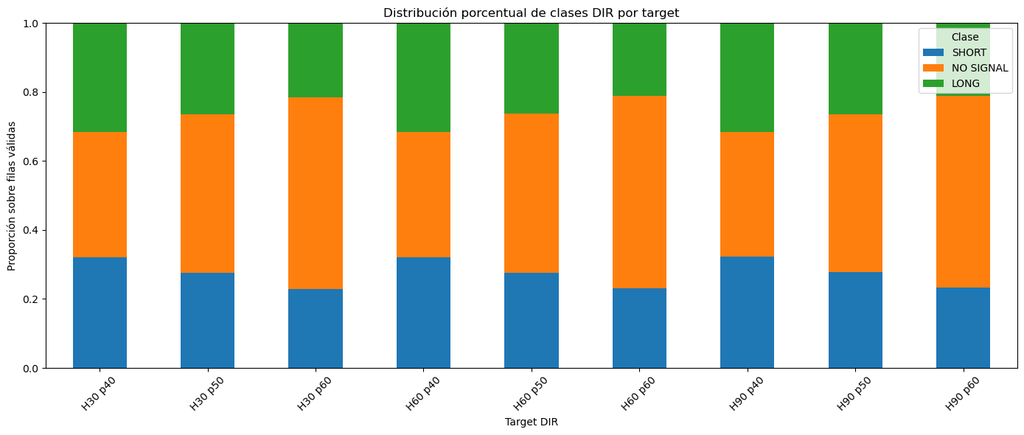

```python
# Celda 4 — Gráfico de distribución porcentual por target
# ============================================================

df_plot = df_dir_class_distribution.copy()

df_plot["target_label"] = (
    "H" + df_plot["horizon"].astype(str)
    + " p" + df_plot["percentile"].astype(str)
)

plot_data = df_plot.set_index("target_label")[
    ["short_ratio", "no_signal_ratio", "long_ratio"]
]

ax = plot_data.plot(
    kind="bar",
    stacked=True,
    figsize=(14, 6)
)

ax.set_title("Distribución porcentual de clases DIR por target")
ax.set_xlabel("Target DIR")
ax.set_ylabel("Proporción sobre filas válidas")
ax.legend(["SHORT", "NO SIGNAL", "LONG"], title="Clase")
ax.set_ylim(0, 1)

plt.xticks(rotation=45)
plt.tight_layout()
plt.show()
```

### Celda 5 — Gráfico de frecuencia operativa

Este gráfico muestra qué porcentaje de observaciones genera señal:

```
    DIR = 1  o  DIR = -1
```

Es decir, mide:

```
    signal_ratio = LONG + SHORT
```

**Cómo leer este gráfico**

Si el percentil sube, el threshold es más exigente.

Por eso esperamos que:

```
    p40 tenga más señales
    p50 tenga señales intermedias
    p60 tenga menos señales
```

Este gráfico nos ayuda a ver si esa relación se cumple.

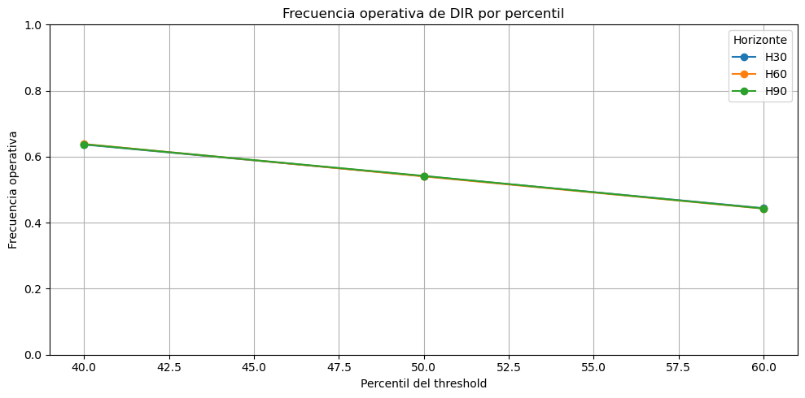

```python
# Celda 5 — Frecuencia operativa por horizonte y percentil
# ============================================================

fig, ax = plt.subplots(figsize=(10, 5))

for h in DIR_HORIZONS:
    tmp = df_dir_class_distribution[
        df_dir_class_distribution["horizon"] == h
    ].sort_values("percentile")

    ax.plot(
        tmp["percentile"],
        tmp["signal_ratio"],
        marker="o",
        label=f"H{h}"
    )

ax.set_title("Frecuencia operativa de DIR por percentil")
ax.set_xlabel("Percentil del threshold")
ax.set_ylabel("Frecuencia operativa")
ax.set_ylim(0, 1)
ax.legend(title="Horizonte")
ax.grid(True)

plt.tight_layout()
plt.show()
```

### Celda 6 — Gráfico de balance LONG/SHORT

Este gráfico analiza solo las señales operativas, es decir, excluye `DIR = 0`.

Muestra qué porcentaje de señales son LONG.

**Cómo leer este gráfico**

La línea punteada en 50% representa equilibrio perfecto entre LONG y SHORT.

Si una barra está cerca de 0.50:

```
    LONG y SHORT están balanceados
```

Si está muy por encima:

```
    predominan señales LONG
```

Si está muy por debajo:

```
    predominan señales SHORT
```

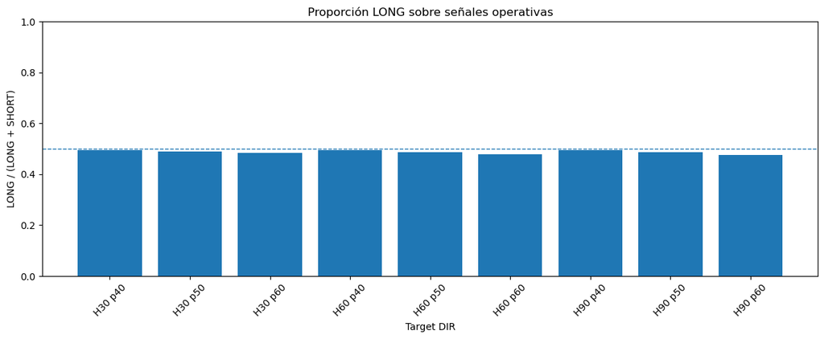

```python
# Celda 6 — Balance LONG/SHORT entre señales operativas
# ============================================================

fig, ax = plt.subplots(figsize=(12, 5))

df_balance = df_dir_class_distribution.copy()

df_balance["target_label"] = (
    "H" + df_balance["horizon"].astype(str)
    + " p" + df_balance["percentile"].astype(str)
)

ax.bar(
    df_balance["target_label"],
    df_balance["long_share_over_signals"]
)

ax.axhline(
    0.50,
    linestyle="--",
    linewidth=1
)

ax.set_title("Proporción LONG sobre señales operativas")
ax.set_xlabel("Target DIR")
ax.set_ylabel("LONG / (LONG + SHORT)")
ax.set_ylim(0, 1)

plt.xticks(rotation=45)
plt.tight_layout()
plt.show()
```

### Celda 7 — Gráfico de filas válidas e inválidas

Este gráfico sirve para confirmar visualmente que al aumentar el horizonte se pierden más filas por falta de ventana futura.

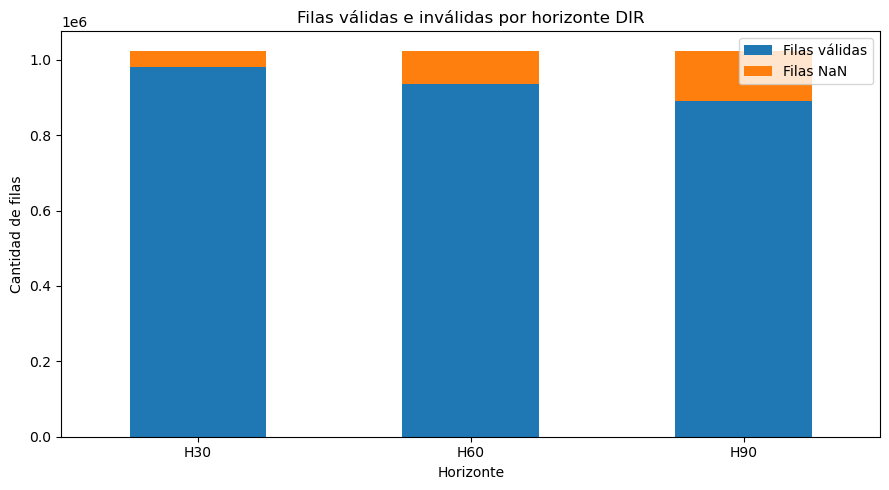

```python
# Celda 7 — Filas válidas e inválidas por horizonte
# ============================================================

df_validity = (
    df_dir_class_distribution
    .groupby("horizon", as_index=False)
    .agg(
        valid_rows=("valid_rows", "first"),
        nan_rows=("nan_rows", "first")
    )
)

df_validity["horizon_label"] = "H" + df_validity["horizon"].astype(str)

plot_data = df_validity.set_index("horizon_label")[
    ["valid_rows", "nan_rows"]
]

ax = plot_data.plot(
    kind="bar",
    stacked=True,
    figsize=(9, 5)
)

ax.set_title("Filas válidas e inválidas por horizonte DIR")
ax.set_xlabel("Horizonte")
ax.set_ylabel("Cantidad de filas")
ax.legend(["Filas válidas", "Filas NaN"])

plt.xticks(rotation=0)
plt.tight_layout()
plt.show()
```

### Observaciones preliminares — Distribución de clases DIR

La distribución global de clases muestra un comportamiento coherente para las variantes del target `DIR`.

En primer lugar, la cantidad de filas inválidas aumenta con el horizonte evaluado. Esto es esperado, ya que al usar horizontes más largos se pierden más observaciones al final de cada trading day por falta de ventana futura suficiente. Este resultado confirma que la construcción respeta la restricción de no cruzar días.

El percentil controla correctamente la frecuencia operativa del target. A medida que el percentil aumenta, el threshold se vuelve más exigente y disminuye la proporción de señales `LONG` y `SHORT`. En términos generales, `p40` genera más señales, `p60` es más restrictivo y `p50` representa un punto intermedio.

En todos los targets, la clase individual más frecuente es `NO_SIGNAL`. Sin embargo, para `p40` y `p50`, la suma de señales operativas (`LONG + SHORT`) todavía supera a `NO_SIGNAL`. En cambio, para `p60`, `NO_SIGNAL` pasa a dominar con mayor claridad, lo que indica una formulación más selectiva pero con menor frecuencia operativa.

El balance entre señales `LONG` y `SHORT` es razonablemente bueno. La proporción de señales LONG sobre el total de señales operativas se mantiene cercana al 50%, aunque se observa una leve inclinación hacia señales `SHORT`, especialmente en los percentiles más altos.

También se observa que, para un mismo percentil, los horizontes `H30`, `H60` y `H90` presentan distribuciones muy similares. Esto sugiere que los thresholds por horizonte están calibrados de forma consistente y permiten comparar variantes sin que un horizonte genere señales desproporcionadamente más frecuentes que otro.

De manera preliminar, las variantes `dir_p50_h30`, `dir_p50_h60` y `dir_p50_h90` parecen las más equilibradas a nivel global, ya que combinan una frecuencia operativa razonable con buen balance entre señales `LONG` y `SHORT`.

En síntesis, el target `DIR` quedó bien construido y presenta una distribución global estadísticamente razonable. El siguiente paso será evaluar si este comportamiento se mantiene al segmentar por régimen intradiario, año, contrato y otros contextos relevantes.

## 3.4. Frecuencia operativa DIR

En este punto se analizará qué porcentaje de observaciones genera una señal operable.

La frecuencia operativa se define como:

```
    frecuencia_operativa = proporción de observaciones donde DIR != 0
```

Es decir:

```
    DIR = 1  → señal LONG
    DIR = -1 → señal SHORT
    DIR = 0  → sin señal operable
```

Este análisis permite entender si una combinación de horizonte y percentil genera demasiadas señales, muy pocas señales o una cantidad razonable para ser estudiada posteriormente.

Un target puede estar relativamente balanceado, pero generar señales muy poco frecuentes. En ese caso, podría ser difícil de modelar o poco útil desde una perspectiva operativa.

### Celda 1 — Preparar tabla de frecuencia operativa

Esta celda toma el resumen ya creado en el punto 3.3 y se queda solo con las columnas necesarias para analizar frecuencia operativa.

```python
# Celda 1 — Preparación de tabla de frecuencia operativa
# ============================================================

required_cols = [
    "target",
    "horizon",
    "percentile",
    "valid_rows",
    "nan_rows",
    "long_count",
    "short_count",
    "no_signal_count",
    "signal_count",
    "signal_ratio",
    "no_signal_ratio",
    "long_share_over_signals",
    "short_share_over_signals",
]

missing_cols = [
    col for col in required_cols
    if col not in df_dir_class_distribution.columns
]

if missing_cols:
    raise KeyError(f"Faltan columnas en df_dir_class_distribution: {missing_cols}")

df_dir_operational_frequency = (
    df_dir_class_distribution[required_cols]
    .copy()
    .sort_values(["horizon", "percentile"])
    .reset_index(drop=True)
)

print("Tabla de frecuencia operativa DIR preparada.")
print("=" * 80)
print(df_dir_operational_frequency.to_string(index=False))
```

```
Tabla de frecuencia operativa DIR preparada.
================================================================================
     target  horizon  percentile  valid_rows  nan_rows  long_count  short_count  no_signal_count  signal_count  signal_ratio  no_signal_ratio  long_share_over_signals  short_share_over_signals
dir_p40_h30       30          40      979602     44460      309481       314255           355866        623736      0.636724         0.363276                 0.496173                  0.503827
dir_p50_h30       30          50      979602     44460      259900       270082           449620        529982      0.541018         0.458982                 0.490394                  0.509606
dir_p60_h30       30          60      979602     44460      210169       224826           544607        434995      0.444053         0.555947                 0.483153                  0.516847
dir_p40_h60       60          40      935142     88920      296160       300864           338118        597024      0.638431         0.361569                 0.496060                  0.503940
dir_p50_h60       60          50      935142     88920      246274       258746           430122        505020      0.540046         0.459954                 0.487652                  0.512348
dir_p60_h60       60          60      935142     88920      197901       215897           521344        413798      0.442498         0.557502                 0.478255                  0.521745
dir_p40_h90       90          40      890682    133380      280594       287376           322712        567970      0.637680         0.362320                 0.494030                  0.505970
dir_p50_h90       90          50      890682    133380      234585       248018           408079        482603      0.541835         0.458165                 0.486083                  0.513917
dir_p60_h90       90          60      890682    133380      187768       206733           496181        394501      0.442920         0.557080                 0.475963                  0.524037
```

### Celda 2 — Clasificación simple de frecuencia operativa

Esta celda agrega una lectura rápida: si un target genera muchas, pocas o una cantidad intermedia de señales.

Lectura

```
    Alta  → muchas señales, posible mayor ruido
    Media → frecuencia razonable para seguir estudiando
    Baja  → target más selectivo, menos oportunidades
```

```python
# Celda 2 — Clasificación simple de frecuencia operativa
# ============================================================

def classify_operational_frequency(signal_ratio):
    """
    Clasificación simple de la frecuencia operativa.
    Los rangos son criterios exploratorios, no reglas definitivas.
    """
    if signal_ratio >= 0.60:
        return "Alta"
    elif signal_ratio >= 0.45:
        return "Media"
    else:
        return "Baja"


df_dir_operational_frequency["frequency_category"] = (
    df_dir_operational_frequency["signal_ratio"]
    .apply(classify_operational_frequency)
)

print("Clasificación de frecuencia operativa")
print("=" * 80)

cols_show = [
    "target",
    "horizon",
    "percentile",
    "signal_ratio",
    "no_signal_ratio",
    "frequency_category",
]

print(df_dir_operational_frequency[cols_show].to_string(index=False))
```

```
Clasificación de frecuencia operativa
================================================================================
     target  horizon  percentile  signal_ratio  no_signal_ratio frequency_category
dir_p40_h30       30          40      0.636724         0.363276               Alta
dir_p50_h30       30          50      0.541018         0.458982              Media
dir_p60_h30       30          60      0.444053         0.555947               Baja
dir_p40_h60       60          40      0.638431         0.361569               Alta
dir_p50_h60       60          50      0.540046         0.459954              Media
dir_p60_h60       60          60      0.442498         0.557502               Baja
dir_p40_h90       90          40      0.637680         0.362320               Alta
dir_p50_h90       90          50      0.541835         0.458165              Media
dir_p60_h90       90          60      0.442920         0.557080               Baja
```

### Celda 3 — Matriz horizonte vs percentil

Esta celda permite ver rápidamente cómo cambia la frecuencia operativa según H y p.

Esta tabla es útil porque resume todo en una matriz simple:

```
    filas    = horizontes
    columnas = percentiles
    valores  = frecuencia operativa
```

```python
# Celda 3 — Matriz de frecuencia operativa H x p
# ============================================================

df_signal_pivot = df_dir_operational_frequency.pivot(
    index="horizon",
    columns="percentile",
    values="signal_ratio"
)

print("Matriz de frecuencia operativa DIR")
print("=" * 80)
print(df_signal_pivot.to_string(float_format=lambda x: f"{x:.2%}"))
```

```
Matriz de frecuencia operativa DIR
================================================================================
percentile     40     50     60
horizon
30         63.67% 54.10% 44.41%
60         63.84% 54.00% 44.25%
90         63.77% 54.18% 44.29%
```

### Celda 4 — Gráfico de frecuencia operativa por target

Este gráfico muestra directamente qué tan operable es cada variante de `DIR`.

**Cómo leerlo**

- Una barra alta significa que el target genera muchas señales `LONG` o `SHORT`.
- Una barra baja significa que el target clasifica más observaciones como `NO_SIGNAL`.

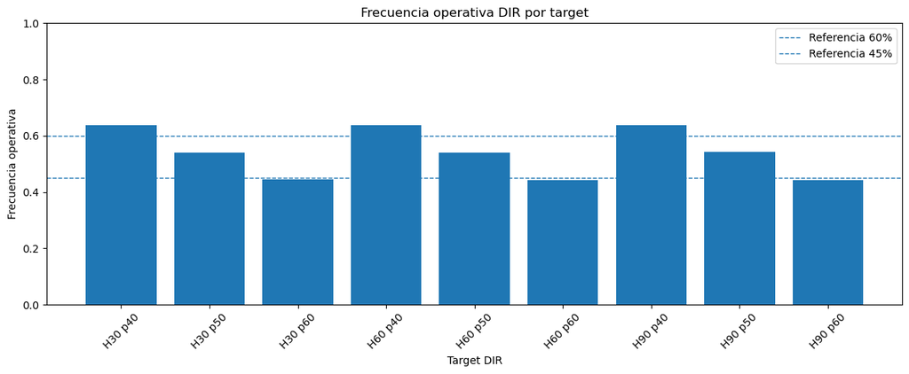

```python
# Celda 4 — Gráfico de frecuencia operativa por target
# ============================================================

df_plot = df_dir_operational_frequency.copy()

df_plot["target_label"] = (
    "H" + df_plot["horizon"].astype(str)
    + " p" + df_plot["percentile"].astype(str)
)

fig, ax = plt.subplots(figsize=(12, 5))

ax.bar(
    df_plot["target_label"],
    df_plot["signal_ratio"]
)

ax.axhline(0.60, linestyle="--", linewidth=1, label="Referencia 60%")
ax.axhline(0.45, linestyle="--", linewidth=1, label="Referencia 45%")

ax.set_title("Frecuencia operativa DIR por target")
ax.set_xlabel("Target DIR")
ax.set_ylabel("Frecuencia operativa")
ax.set_ylim(0, 1)
ax.legend()

plt.xticks(rotation=45)
plt.tight_layout()
plt.show()
```

### Celda 5 — Gráfico por percentil y horizonte

Este gráfico muestra si la frecuencia cae de forma ordenada cuando sube el percentil.

**Cómo leerlo**

Lo esperado es que la curva baje cuando sube el percentil:

```
    p40 → más señales
    p50 → frecuencia intermedia
    p60 → menos señales
```

Si eso ocurre, significa que el threshold está controlando correctamente la selectividad del target.

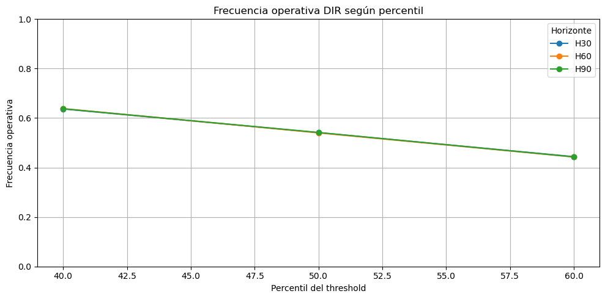

```python
# Celda 5 — Frecuencia operativa por percentil y horizonte
# ============================================================

fig, ax = plt.subplots(figsize=(10, 5))

for h in DIR_HORIZONS:
    tmp = (
        df_dir_operational_frequency
        [df_dir_operational_frequency["horizon"] == h]
        .sort_values("percentile")
    )

    ax.plot(
        tmp["percentile"],
        tmp["signal_ratio"],
        marker="o",
        label=f"H{h}"
    )

ax.set_title("Frecuencia operativa DIR según percentil")
ax.set_xlabel("Percentil del threshold")
ax.set_ylabel("Frecuencia operativa")
ax.set_ylim(0, 1)
ax.legend(title="Horizonte")
ax.grid(True)

plt.tight_layout()
plt.show()
```

### Celda 6 — Resumen automático del punto 3.4

Esta celda imprime una conclusión rápida para documentar el análisis.

```python
# Celda 6 — Resumen automático de frecuencia operativa
# ============================================================

print("Conclusiones preliminares - Frecuencia operativa DIR")
print("=" * 80)

for p in DIR_PERCENTILES:
    tmp = df_dir_operational_frequency[
        df_dir_operational_frequency["percentile"] == p
    ]

    avg_signal_ratio = tmp["signal_ratio"].mean()
    avg_no_signal_ratio = tmp["no_signal_ratio"].mean()

    print(f"\nPercentil p{p}:")
    print(f"  Frecuencia operativa promedio: {avg_signal_ratio:.2%}")
    print(f"  NO_SIGNAL promedio:            {avg_no_signal_ratio:.2%}")

print("\nLectura por target:")
for _, row in df_dir_operational_frequency.iterrows():
    print(
        f"  {row['target']}: "
        f"signal_ratio={row['signal_ratio']:.2%}, "
        f"NO_SIGNAL={row['no_signal_ratio']:.2%}, "
        f"categoría={row['frequency_category']}"
    )

print("\nInterpretación general:")
print("- p40 genera la mayor frecuencia operativa, pero puede incluir más ruido.")
print("- p50 mantiene una frecuencia intermedia y parece razonable para seguir analizando.")
print("- p60 es más selectivo, pero reduce la cantidad de señales disponibles.")
print("- La frecuencia operativa debe evaluarse luego por año, régimen y contrato.")
```

```
Conclusiones preliminares - Frecuencia operativa DIR
================================================================================

Percentil p40:
  Frecuencia operativa promedio: 63.76%
  NO_SIGNAL promedio:            36.24%

Percentil p50:
  Frecuencia operativa promedio: 54.10%
  NO_SIGNAL promedio:            45.90%

Percentil p60:
  Frecuencia operativa promedio: 44.32%
  NO_SIGNAL promedio:            55.68%

Lectura por target:
  dir_p40_h30: signal_ratio=63.67%, NO_SIGNAL=36.33%, categoría=Alta
  dir_p50_h30: signal_ratio=54.10%, NO_SIGNAL=45.90%, categoría=Media
  dir_p60_h30: signal_ratio=44.41%, NO_SIGNAL=55.59%, categoría=Baja
  dir_p40_h60: signal_ratio=63.84%, NO_SIGNAL=36.16%, categoría=Alta
  dir_p50_h60: signal_ratio=54.00%, NO_SIGNAL=46.00%, categoría=Media
  dir_p60_h60: signal_ratio=44.25%, NO_SIGNAL=55.75%, categoría=Baja
  dir_p40_h90: signal_ratio=63.77%, NO_SIGNAL=36.23%, categoría=Alta
  dir_p50_h90: signal_ratio=54.18%, NO_SIGNAL=45.82%, categoría=Media
  dir_p60_h90: signal_ratio=44.29%, NO_SIGNAL=55.71%, categoría=Baja

Interpretación general:
- p40 genera la mayor frecuencia operativa, pero puede incluir más ruido.
- p50 mantiene una frecuencia intermedia y parece razonable para seguir analizando.
- p60 es más selectivo, pero reduce la cantidad de señales disponibles.
- La frecuencia operativa debe evaluarse luego por año, régimen y contrato.
```

### Observaciones premilinares - Frecuencia operativa DIR

La frecuencia operativa se comporta de forma muy ordenada: al aumentar el percentil, baja la cantidad de señales. Esto confirma que el threshold está controlando correctamente la selectividad del target.

```
    p40 → ~63.8% de señales operativas
    p50 → ~54.1% de señales operativas
    p60 → ~44.3% de señales operativas
```

`p40` genera muchas señales. Puede ser útil si queremos más oportunidades, pero probablemente incluya más ruido.

`p50` queda como el punto más equilibrado. Mantiene una frecuencia operativa media, con aproximadamente la mitad de las observaciones generando señal y la otra parte quedando como `NO_SIGNAL`.

`p60` es más restrictivo. Genera menos señales y deja más del 55% de las observaciones como `NO_SIGNAL`. Puede ser más selectivo, pero quizás demasiado limitado para algunos modelos.

Los horizontes `H30`, `H60` y `H90` muestran frecuencias casi idénticas para un mismo percentil. Esto es positivo porque indica que los thresholds por horizonte están bien calibrados y permiten comparar targets de forma consistente.

La frecuencia operativa depende mucho más del **percentil** que del **horizonte**. En esta vista global, cambiar de `H30` a `H90` casi no modifica la proporción de señales.

Conclusión preliminar: `p50` parece la opción más razonable para seguir analizando, mientras que `p40` y `p60` deben mantenerse como variantes comparativas: `p40` por ser más activo y `p60` por ser más selectivo.

## 3.5. Sensibilidad por horizonte y percentil

En este punto se evaluará cómo cambia `DIR` cuando se modifican los parámetros principales:

```
    horizon
    percentile
```

La pregunta central será:

```
    ¿Qué ocurre con la distribución de clases y la frecuencia operativa cuando cambia el horizonte o el threshold?
```

En general, percentiles más bajos tienden a generar más señales porque el threshold es menor. Percentiles más altos tienden a generar menos señales, pero potencialmente más selectivas.

Del mismo modo, horizontes más amplios pueden capturar movimientos mayores, pero también modifican la naturaleza temporal del problema.

Este análisis permitirá comparar variantes como:

```
    dir_p40_h30
    dir_p50_h30
    dir_p60_h30
    dir_p40_h60
    dir_p50_h60
    dir_p60_h60
    dir_p40_h90
    dir_p50_h90
    dir_p60_h90
```

El objetivo no será elegir todavía un target definitivo, sino identificar cuáles combinaciones parecen más razonables.

### Celda 1 — Preparar tabla de sensibilidad

Esta celda solo prepara la tabla que vamos a usar para comparar. No calcula nada nuevo del precio.

```python
# Celda 1 — Preparación de tabla base
# ============================================================

required_cols = [
    "target",
    "horizon",
    "percentile",
    "long_ratio",
    "short_ratio",
    "no_signal_ratio",
    "signal_ratio",
    "long_share_over_signals",
    "short_share_over_signals",
]

missing_cols = [
    col for col in required_cols
    if col not in df_dir_class_distribution.columns
]

if missing_cols:
    raise KeyError(f"Faltan columnas en df_dir_class_distribution: {missing_cols}")

df_dir_sensitivity = (
    df_dir_class_distribution[required_cols]
    .copy()
    .sort_values(["horizon", "percentile"])
    .reset_index(drop=True)
)

df_dir_sensitivity["target_label"] = (
    "H" + df_dir_sensitivity["horizon"].astype(str)
    + " p" + df_dir_sensitivity["percentile"].astype(str)
)

print("Tabla base de sensibilidad DIR")
print("=" * 80)
print(df_dir_sensitivity.to_string(index=False))
```

```
Tabla base de sensibilidad DIR
================================================================================
     target  horizon  percentile  long_ratio  short_ratio  no_signal_ratio  signal_ratio  long_share_over_signals  short_share_over_signals target_label
dir_p40_h30       30          40    0.315925     0.320799         0.363276      0.636724                 0.496173                  0.503827      H30 p40
dir_p50_h30       30          50    0.265312     0.275706         0.458982      0.541018                 0.490394                  0.509606      H30 p50
dir_p60_h30       30          60    0.214545     0.229507         0.555947      0.444053                 0.483153                  0.516847      H30 p60
dir_p40_h60       60          40    0.316701     0.321731         0.361569      0.638431                 0.496060                  0.503940      H60 p40
dir_p50_h60       60          50    0.263355     0.276692         0.459954      0.540046                 0.487652                  0.512348      H60 p50
dir_p60_h60       60          60    0.211627     0.230871         0.557502      0.442498                 0.478255                  0.521745      H60 p60
dir_p40_h90       90          40    0.315033     0.322647         0.362320      0.637680                 0.494030                  0.505970      H90 p40
dir_p50_h90       90          50    0.263377     0.278459         0.458165      0.541835                 0.486083                  0.513917      H90 p50
dir_p60_h90       90          60    0.210814     0.232106         0.557080      0.442920                 0.475963                  0.524037      H90 p60
```

### Celda 2 — Matrices de sensibilidad

Estas matrices permiten ver rápidamente cómo cambian las métricas por horizonte y percentil.

Esto nos permite ver, por ejemplo, si `signal_ratio` cambia más por percentil o por horizonte.

```python
# Celda 2 — Matrices horizon x percentile
# ============================================================

metrics_to_pivot = [
    "signal_ratio",
    "no_signal_ratio",
    "long_ratio",
    "short_ratio",
    "long_share_over_signals",
]

for metric in metrics_to_pivot:
    pivot_table = df_dir_sensitivity.pivot(
        index="horizon",
        columns="percentile",
        values=metric
    )

    print(f"\nMatriz: {metric}")
    print("=" * 80)
    print(pivot_table.to_string(float_format=lambda x: f"{x:.2%}"))
```

```
Matriz: signal_ratio
================================================================================
percentile     40     50     60
horizon
30         63.67% 54.10% 44.41%
60         63.84% 54.00% 44.25%
90         63.77% 54.18% 44.29%

Matriz: no_signal_ratio
================================================================================
percentile     40     50     60
horizon
30         36.33% 45.90% 55.59%
60         36.16% 46.00% 55.75%
90         36.23% 45.82% 55.71%

Matriz: long_ratio
================================================================================
percentile     40     50     60
horizon
30         31.59% 26.53% 21.45%
60         31.67% 26.34% 21.16%
90         31.50% 26.34% 21.08%

Matriz: short_ratio
================================================================================
percentile     40     50     60
horizon
30         32.08% 27.57% 22.95%
60         32.17% 27.67% 23.09%
90         32.26% 27.85% 23.21%

Matriz: long_share_over_signals
================================================================================
percentile     40     50     60
horizon
30         49.62% 49.04% 48.32%
60         49.61% 48.77% 47.83%
90         49.40% 48.61% 47.60%
```

### Celda 3 — Sensibilidad al percentil

Acá medimos cuánto cae la frecuencia operativa cuando pasamos de `p40` a `p60`.

Lectura simple:

```
    drop_p40_to_p60 = cuánto se reduce la frecuencia operativa al hacer el target más exigente.
```

```python
# Celda 3 — Sensibilidad al percentil
# ============================================================

df_percentile_sensitivity = (
    df_dir_sensitivity
    .pivot(
        index="horizon",
        columns="percentile",
        values="signal_ratio"
    )
    .reset_index()
)

df_percentile_sensitivity["drop_p40_to_p50"] = (
    df_percentile_sensitivity[40] - df_percentile_sensitivity[50]
)

df_percentile_sensitivity["drop_p50_to_p60"] = (
    df_percentile_sensitivity[50] - df_percentile_sensitivity[60]
)

df_percentile_sensitivity["drop_p40_to_p60"] = (
    df_percentile_sensitivity[40] - df_percentile_sensitivity[60]
)

print("Sensibilidad de frecuencia operativa al percentil")
print("=" * 80)
print(df_percentile_sensitivity.to_string(
    index=False,
    float_format=lambda x: f"{x:.2%}" if isinstance(x, float) else str(x)
))
```

```
Sensibilidad de frecuencia operativa al percentil
================================================================================
 horizon     40     50     60  drop_p40_to_p50  drop_p50_to_p60  drop_p40_to_p60
      30 63.67% 54.10% 44.41%            9.57%            9.70%           19.27%
      60 63.84% 54.00% 44.25%            9.84%            9.75%           19.59%
      90 63.77% 54.18% 44.29%            9.58%            9.89%           19.48%
```

### Celda 4 — Sensibilidad al horizonte

Acá medimos si cambiar de H30 a H90 altera mucho la frecuencia operativa.

Lectura simple:

```
    signal_range bajo = el horizonte casi no cambia la frecuencia operativa.
    signal_range alto = el horizonte afecta mucho al target.
```

```python
# Celda 4 — Sensibilidad al horizonte
# ============================================================

df_horizon_sensitivity = (
    df_dir_sensitivity
    .groupby("percentile")
    .agg(
        signal_min=("signal_ratio", "min"),
        signal_max=("signal_ratio", "max"),
        signal_mean=("signal_ratio", "mean"),
        signal_range=("signal_ratio", lambda x: x.max() - x.min()),
        no_signal_mean=("no_signal_ratio", "mean"),
    )
    .reset_index()
)

print("Sensibilidad de frecuencia operativa al horizonte")
print("=" * 80)
print(df_horizon_sensitivity.to_string(
    index=False,
    float_format=lambda x: f"{x:.2%}"
))
```

```
Sensibilidad de frecuencia operativa al horizonte
================================================================================
 percentile  signal_min  signal_max  signal_mean  signal_range  no_signal_mean
         40      63.67%      63.84%       63.76%         0.17%          36.24%
         50      54.00%      54.18%       54.10%         0.18%          45.90%
         60      44.25%      44.41%       44.32%         0.16%          55.68%
```

### Celda 5 — Gráfico de sensibilidad al percentil

Este gráfico muestra si el target responde correctamente al aumento del threshold.

Lo esperado es:

```
    p40 > p50 > p60
```

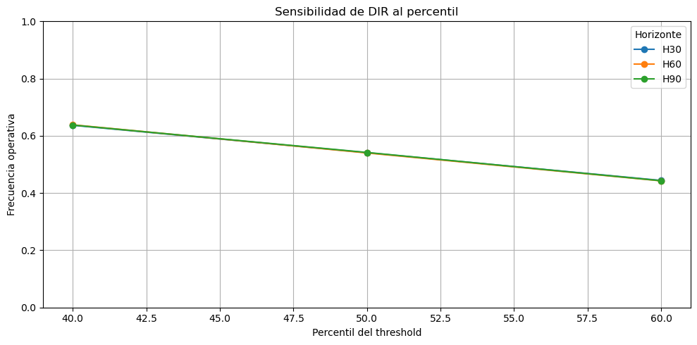

```python
# Celda 5 — Gráfico de frecuencia operativa por percentil
# ============================================================

fig, ax = plt.subplots(figsize=(10, 5))

for h in DIR_HORIZONS:
    tmp = (
        df_dir_sensitivity[df_dir_sensitivity["horizon"] == h]
        .sort_values("percentile")
    )

    ax.plot(
        tmp["percentile"],
        tmp["signal_ratio"],
        marker="o",
        label=f"H{h}"
    )

ax.set_title("Sensibilidad de DIR al percentil")
ax.set_xlabel("Percentil del threshold")
ax.set_ylabel("Frecuencia operativa")
ax.set_ylim(0, 1)
ax.legend(title="Horizonte")
ax.grid(True)

plt.tight_layout()
plt.show()
```

### Celda 6 — Gráfico de caída de frecuencia p40 → p60

Este gráfico resume cuánto se vuelve más selectivo el target al pasar de p40 a p60.

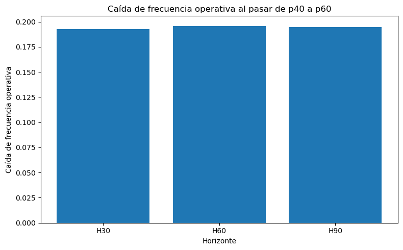

```python
# Celda 6 — Caída de frecuencia operativa p40 a p60
# ============================================================

fig, ax = plt.subplots(figsize=(8, 5))

ax.bar(
    "H" + df_percentile_sensitivity["horizon"].astype(str),
    df_percentile_sensitivity["drop_p40_to_p60"]
)

ax.set_title("Caída de frecuencia operativa al pasar de p40 a p60")
ax.set_xlabel("Horizonte")
ax.set_ylabel("Caída de frecuencia operativa")

plt.tight_layout()
plt.show()
```

### Celda 7 — Conclusión automática simple

```python
# Celda 7 — Conclusión automática de sensibilidad
# ============================================================

print("Conclusiones preliminares - Sensibilidad DIR")
print("=" * 80)

print("\nSensibilidad al percentil:")
for _, row in df_percentile_sensitivity.iterrows():
    print(
        f"H{int(row['horizon'])}: "
        f"p40={row[40]:.2%}, "
        f"p50={row[50]:.2%}, "
        f"p60={row[60]:.2%}, "
        f"caída p40→p60={row['drop_p40_to_p60']:.2%}"
    )

print("\nSensibilidad al horizonte:")
for _, row in df_horizon_sensitivity.iterrows():
    print(
        f"p{int(row['percentile'])}: "
        f"frecuencia media={row['signal_mean']:.2%}, "
        f"rango entre horizontes={row['signal_range']:.2%}"
    )

print("\nLectura general:")
print("- Si la frecuencia cae claramente de p40 a p60, el percentil está controlando bien la selectividad.")
print("- Si el rango entre horizontes es bajo, los horizontes son comparables a nivel global.")
print("- Si p50 queda en una zona intermedia, puede ser una variante candidata razonable.")
print("- La decisión final no debe tomarse solo con esta vista global; falta revisar estabilidad temporal, régimen y contrato.")
```

```
Conclusiones preliminares - Sensibilidad DIR
================================================================================

Sensibilidad al percentil:
H30: p40=63.67%, p50=54.10%, p60=44.41%, caída p40→p60=19.27%
H60: p40=63.84%, p50=54.00%, p60=44.25%, caída p40→p60=19.59%
H90: p40=63.77%, p50=54.18%, p60=44.29%, caída p40→p60=19.48%

Sensibilidad al horizonte:
p40: frecuencia media=63.76%, rango entre horizontes=0.17%
p50: frecuencia media=54.10%, rango entre horizontes=0.18%
p60: frecuencia media=44.32%, rango entre horizontes=0.16%

Lectura general:
- Si la frecuencia cae claramente de p40 a p60, el percentil está controlando bien la selectividad.
- Si el rango entre horizontes es bajo, los horizontes son comparables a nivel global.
- Si p50 queda en una zona intermedia, puede ser una variante candidata razonable.
- La decisión final no debe tomarse solo con esta vista global; falta revisar estabilidad temporal, régimen y contrato.
```

### Observaciones premilinares - Sensibilidad por horizontes y percentil

El análisis muestra que el target `DIR` es mucho más sensible al **percentil del threshold** que al **horizonte temporal**.

Al aumentar el percentil de `p40` a `p60`, la frecuencia operativa cae de forma clara y ordenada en todos los horizontes:

```
p40 → ~63.8% de señales operativas
p50 → ~54.1% de señales operativas
p60 → ~44.3% de señales operativas
```

La caída total entre `p40` y `p60` es cercana al 19% para `H30`, `H60` y `H90`. Esto confirma que el percentil controla correctamente la selectividad del target: percentiles más bajos generan más señales, mientras que percentiles más altos filtran más movimientos y aumentan la proporción de `NO_SIGNAL`.

En cambio, el horizonte tiene muy poco impacto sobre la frecuencia operativa global. Para cada percentil, las diferencias entre `H30`, `H60` y `H90` son mínimas, con rangos inferiores al 0.20%. Esto sugiere que los thresholds por horizonte están calibrados de forma consistente y permiten comparar las variantes de manera razonable.

También se observa que `NO_SIGNAL` aumenta progresivamente al subir el percentil:

```
p40 → ~36% NO_SIGNAL
p50 → ~46% NO_SIGNAL
p60 → ~56% NO_SIGNAL
```

Por lo tanto, `p40` representa una configuración más activa, `p60` una configuración más selectiva, y `p50` queda como una alternativa intermedia.

De forma preliminar, `p50` parece la variante más equilibrada a nivel global, ya que mantiene una frecuencia operativa razonable sin generar señales tan abundantes como `p40` ni tan restrictivas como `p60`.

En síntesis, la sensibilidad principal de `DIR` proviene del percentil seleccionado, no del horizonte. Sin embargo, esta conclusión todavía debe complementarse con análisis por estabilidad temporal, régimen intradiario y contrato antes de seleccionar variantes candidatas definitivas.

## 3.6. Estabilidad temporal

En este punto se evaluará si la distribución del target se mantiene razonablemente estable a lo largo del tiempo.

El análisis se realizará por:

```
    year
    year_quarter
    development_2020_2024 vs final_test_2025_2026
```

También se prestará atención a períodos particulares como:

```
    2022
    2025Q2
    2026
```

La idea es verificar si una variante de `DIR` funciona de manera razonable en distintos contextos de mercado o si depende demasiado de un período específico.

Un target puede verse bien en promedio, pero ser inestable año a año. Esa inestabilidad puede dificultar el entrenamiento de modelos que generalicen correctamente.

### Celda 1 — Configuración temporal

```python
# Celda 1 — Configuración temporal
# ============================================================

import numpy as np
import pandas as pd
import matplotlib.pyplot as plt

# Asegurar columnas temporales básicas
if "year" not in df_targets_dir.columns:
    df_targets_dir["year"] = df_targets_dir.index.year

if "quarter" not in df_targets_dir.columns:
    df_targets_dir["quarter"] = df_targets_dir.index.quarter

if "year_quarter" not in df_targets_dir.columns:
    df_targets_dir["year_quarter"] = (
        df_targets_dir["year"].astype(str)
        + "Q"
        + df_targets_dir["quarter"].astype(str)
    )

if "target_analysis_split" not in df_targets_dir.columns:
    df_targets_dir["target_analysis_split"] = np.where(
        df_targets_dir["year"].between(2020, 2024),
        "development_2020_2024",
        "final_test_2025_2026"
    )

# Targets DIR
dir_target_cols = [
    f"dir_p{p}_h{h}"
    for h in DIR_HORIZONS
    for p in DIR_PERCENTILES
]

# Variante central para gráficos simples
selected_targets_temporal = [
    "dir_p50_h30",
    "dir_p50_h60",
    "dir_p50_h90",
]

print("Configuración temporal lista.")
print("=" * 80)
print(f"Targets DIR a analizar: {len(dir_target_cols)}")
print(f"Targets seleccionados para gráficos: {selected_targets_temporal}")
print(f"Años disponibles: {sorted(df_targets_dir['year'].unique().tolist())}")
print(f"Splits disponibles: {df_targets_dir['target_analysis_split'].unique().tolist()}")
```

```
Configuración temporal lista.
================================================================================
Targets DIR a analizar: 9
Targets seleccionados para gráficos: ['dir_p50_h30', 'dir_p50_h60', 'dir_p50_h90']
Años disponibles: [2020, 2021, 2022, 2023, 2024, 2025, 2026]
Splits disponibles: ['development_2020_2024', 'final_test_2025_2026']
```

### Celda 2 — Función resumen por período

Esta función nos permite resumir `DIR` por año, trimestre o split temporal.

```python
# Celda 2 — Función de resumen temporal
# ============================================================

def summarize_dir_by_period(df, target_cols, period_col):
    """
    Resume distribución y frecuencia operativa de DIR por período temporal.
    period_col puede ser: year, year_quarter, target_analysis_split.
    """

    rows = []

    for target_col in target_cols:
        horizon, percentile = parse_dir_target_name(target_col)

        for period_value, group in df.groupby(period_col):
            total_rows = len(group)

            valid_mask = group[target_col].notna()
            valid_values = group.loc[valid_mask, target_col].astype(int)

            valid_rows = valid_mask.sum()
            nan_rows = total_rows - valid_rows

            long_count = (valid_values == 1).sum()
            short_count = (valid_values == -1).sum()
            no_signal_count = (valid_values == 0).sum()

            signal_count = long_count + short_count

            rows.append({
                "target": target_col,
                "horizon": horizon,
                "percentile": percentile,
                period_col: period_value,
                "total_rows": total_rows,
                "valid_rows": valid_rows,
                "nan_rows": nan_rows,
                "long_count": long_count,
                "short_count": short_count,
                "no_signal_count": no_signal_count,
                "signal_count": signal_count,
                "long_ratio": long_count / valid_rows if valid_rows > 0 else np.nan,
                "short_ratio": short_count / valid_rows if valid_rows > 0 else np.nan,
                "no_signal_ratio": no_signal_count / valid_rows if valid_rows > 0 else np.nan,
                "signal_ratio": signal_count / valid_rows if valid_rows > 0 else np.nan,
                "long_share_over_signals": (
                    long_count / signal_count if signal_count > 0 else np.nan
                ),
                "short_share_over_signals": (
                    short_count / signal_count if signal_count > 0 else np.nan
                ),
            })

    return pd.DataFrame(rows)
```

### Celda 3 — Comparación development vs final test

Primero vemos si los targets cambian mucho entre el período de desarrollo y el período final.

```python
# Celda 3 — Comparación development vs final test
# ============================================================

df_dir_split_distribution = summarize_dir_by_period(
    df=df_targets_dir,
    target_cols=dir_target_cols,
    period_col="target_analysis_split"
)

split_signal_pivot = df_dir_split_distribution.pivot(
    index="target",
    columns="target_analysis_split",
    values="signal_ratio"
)

split_signal_pivot["difference_final_minus_dev"] = (
    split_signal_pivot["final_test_2025_2026"]
    - split_signal_pivot["development_2020_2024"]
)

print("Frecuencia operativa por split temporal")
print("=" * 80)
print(split_signal_pivot.to_string(float_format=lambda x: f"{x:.2%}"))
```

```
Frecuencia operativa por split temporal
================================================================================
target_analysis_split  development_2020_2024  final_test_2025_2026  difference_final_minus_dev
target
dir_p40_h30                           60.20%                77.54%                      17.35%
dir_p40_h60                           60.22%                78.28%                      18.06%
dir_p40_h90                           60.16%                78.14%                      17.98%
dir_p50_h30                           50.24%                69.51%                      19.27%
dir_p50_h60                           50.03%                69.86%                      19.83%
dir_p50_h90                           50.23%                69.96%                      19.73%
dir_p60_h30                           40.32%                60.71%                      20.40%
dir_p60_h60                           40.09%                60.84%                      20.75%
dir_p60_h90                           40.08%                61.08%                      21.00%
```

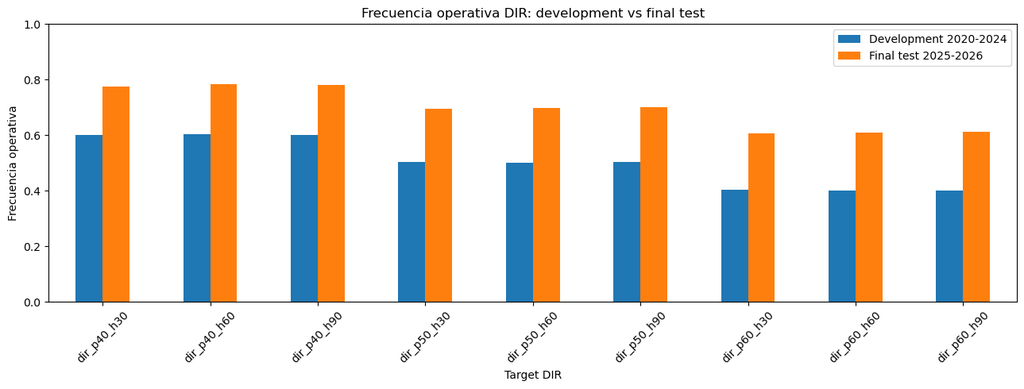

```python
# Celda 3.1 — Gráfico development vs final test
# ============================================================

plot_data = split_signal_pivot[
    ["development_2020_2024", "final_test_2025_2026"]
].copy()

ax = plot_data.plot(
    kind="bar",
    figsize=(13, 5)
)

ax.set_title("Frecuencia operativa DIR: development vs final test")
ax.set_xlabel("Target DIR")
ax.set_ylabel("Frecuencia operativa")
ax.set_ylim(0, 1)
ax.legend(["Development 2020-2024", "Final test 2025-2026"])

plt.xticks(rotation=45)
plt.tight_layout()
plt.show()
```

### Celda 4 — Estabilidad por año

Acá revisamos si la frecuencia operativa cambia mucho año a año.

```python
# Celda 4 — Estabilidad anual
# ============================================================

df_dir_year_distribution = summarize_dir_by_period(
    df=df_targets_dir,
    target_cols=dir_target_cols,
    period_col="year"
)

year_signal_pivot = df_dir_year_distribution.pivot(
    index="year",
    columns="target",
    values="signal_ratio"
)

print("Frecuencia operativa anual por target")
print("=" * 80)
print(year_signal_pivot.to_string(float_format=lambda x: f"{x:.2%}"))
```

```
Frecuencia operativa anual por target
================================================================================
target  dir_p40_h30  dir_p40_h60  dir_p40_h90  dir_p50_h30  dir_p50_h60  dir_p50_h90  dir_p60_h30  dir_p60_h60  dir_p60_h90
year
2020         51.53%       50.55%       50.23%       42.26%       41.05%       40.74%       33.57%       32.30%       31.67%
2021         48.98%       48.84%       49.19%       39.53%       39.26%       39.73%       30.80%       30.21%       30.28%
2022         80.47%       81.41%       81.27%       71.69%       72.19%       72.19%       61.37%       61.58%       61.63%
2023         55.51%       55.40%       55.29%       43.91%       43.40%       43.89%       33.06%       32.75%       32.75%
2024         64.09%       64.47%       64.37%       53.43%       53.80%       54.12%       42.45%       43.21%       43.65%
2025         74.61%       75.20%       74.94%       66.06%       66.19%       66.12%       56.97%       56.76%       56.91%
2026         87.07%       88.27%       88.54%       80.69%       81.76%       82.42%       72.84%       74.09%       74.59%
```

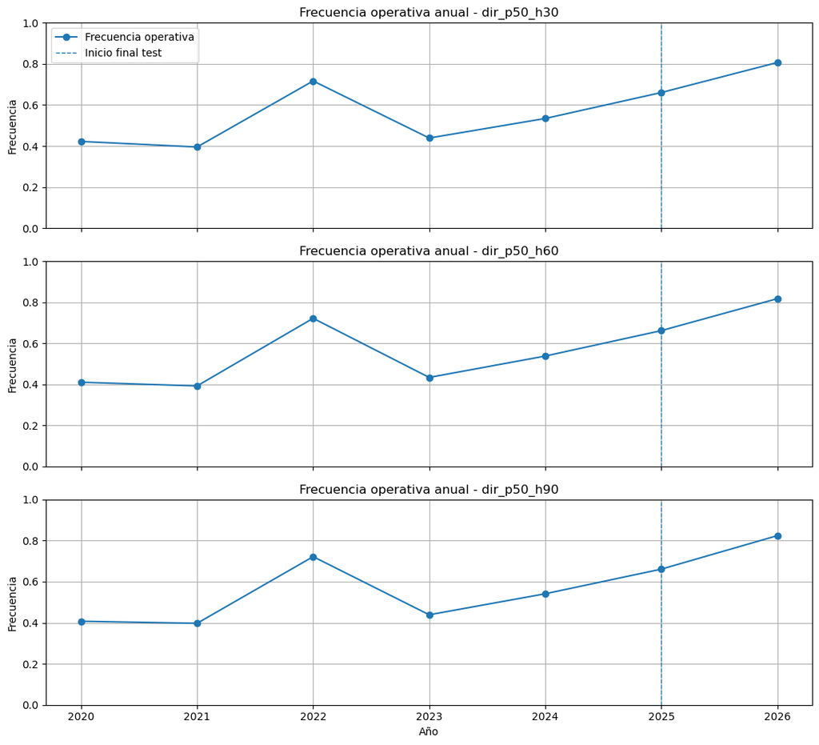

```python
# Celda 4.1 — Gráfico anual para variantes p50
# ============================================================

fig, axes = plt.subplots(
    nrows=3,
    ncols=1,
    figsize=(11, 10),
    sharex=True
)

for ax, target_col in zip(axes, selected_targets_temporal):
    tmp = df_dir_year_distribution[
        df_dir_year_distribution["target"] == target_col
    ].sort_values("year")

    ax.plot(
        tmp["year"],
        tmp["signal_ratio"],
        marker="o",
        label="Frecuencia operativa"
    )

    ax.axvline(2025, linestyle="--", linewidth=1, label="Inicio final test")

    ax.set_title(f"Frecuencia operativa anual - {target_col}")
    ax.set_ylabel("Frecuencia")
    ax.set_ylim(0, 1)
    ax.grid(True)

axes[0].legend(loc="best")
axes[-1].set_xlabel("Año")

plt.tight_layout()
plt.show()
```

### Celda 5 — Estabilidad por trimestre

Ahora bajamos a `year_quarter` para detectar cambios más finos, como `2025Q2`.

```python
# Celda 5 — Estabilidad trimestral
# ============================================================

df_dir_quarter_distribution = summarize_dir_by_period(
    df=df_targets_dir,
    target_cols=dir_target_cols,
    period_col="year_quarter"
)

quarter_signal_pivot = df_dir_quarter_distribution.pivot(
    index="year_quarter",
    columns="target",
    values="signal_ratio"
)

print("Frecuencia operativa trimestral por target")
print("=" * 80)
print(quarter_signal_pivot.to_string(float_format=lambda x: f"{x:.2%}"))
```

```
Frecuencia operativa trimestral por target
================================================================================
target        dir_p40_h30  dir_p40_h60  dir_p40_h90  dir_p50_h30  dir_p50_h60  dir_p50_h90  dir_p60_h30  dir_p60_h60  dir_p60_h90
year_quarter
2020Q1             43.44%       42.18%       41.44%       37.57%       36.47%       36.05%       32.35%       31.00%       31.07%
2020Q2             54.89%       54.15%       52.56%       43.80%       42.19%       40.67%       33.11%       31.44%       30.01%
2020Q3             57.39%       56.85%       57.93%       47.22%       46.53%       47.59%       37.63%       36.77%       36.61%
2020Q4             49.43%       47.95%       47.82%       39.68%       38.18%       37.70%       30.64%       29.40%       28.40%
2021Q1             61.54%       60.27%       59.93%       51.96%       50.76%       51.50%       42.79%       41.71%       42.21%
2021Q2             40.58%       39.50%       39.78%       31.17%       30.02%       30.34%       22.81%       21.75%       21.71%
2021Q3             39.82%       40.85%       42.32%       30.94%       31.70%       32.73%       22.99%       22.92%       23.21%
2021Q4             54.11%       54.83%       54.80%       44.17%       44.67%       44.46%       34.73%       34.59%       34.12%
2022Q1             88.83%       90.29%       90.00%       82.33%       83.29%       83.00%       73.72%       74.13%       73.52%
2022Q2             87.06%       88.71%       88.54%       80.24%       81.38%       81.18%       70.87%       71.55%       71.90%
2022Q3             73.96%       74.60%       74.03%       62.81%       62.88%       62.81%       51.01%       50.81%       51.03%
2022Q4             71.74%       71.71%       72.19%       61.03%       60.82%       61.41%       49.47%       49.43%       49.66%
2023Q1             64.11%       64.22%       64.67%       52.51%       52.37%       53.25%       41.30%       41.15%       41.17%
2023Q2             47.76%       47.51%       47.57%       36.17%       35.63%       35.92%       25.78%       25.65%       25.10%
2023Q3             58.04%       57.94%       56.13%       46.01%       44.76%       44.31%       34.27%       33.08%       32.97%
2023Q4             51.25%       51.01%       51.91%       40.05%       39.94%       41.17%       30.06%       30.30%       30.89%
2024Q1             57.86%       57.30%       57.55%       45.94%       45.84%       46.58%       34.56%       34.97%       35.77%
2024Q2             57.86%       58.12%       57.51%       47.04%       47.71%       47.26%       36.30%       37.38%       37.54%
2024Q3             74.51%       76.83%       77.10%       65.66%       67.67%       67.86%       55.49%       57.44%       57.21%
2024Q4             66.84%       66.47%       66.18%       55.89%       54.90%       55.70%       44.30%       43.94%       44.96%
2025Q1             82.74%       83.03%       83.37%       75.10%       75.24%       76.33%       66.64%       66.93%       68.27%
2025Q2             82.50%       82.95%       83.21%       74.83%       75.16%       75.47%       66.18%       66.00%       66.51%
2025Q3             58.62%       58.83%       57.85%       48.15%       47.17%       46.06%       37.64%       36.33%       35.32%
2025Q4             75.90%       77.28%       76.71%       67.66%       68.68%       68.26%       59.01%       59.39%       59.32%
2026Q1             87.43%       88.32%       88.77%       81.19%       82.24%       82.85%       73.75%       75.00%       75.15%
2026Q2             85.31%       88.02%       87.41%       78.24%       79.44%       80.38%       68.43%       69.70%       71.88%
```

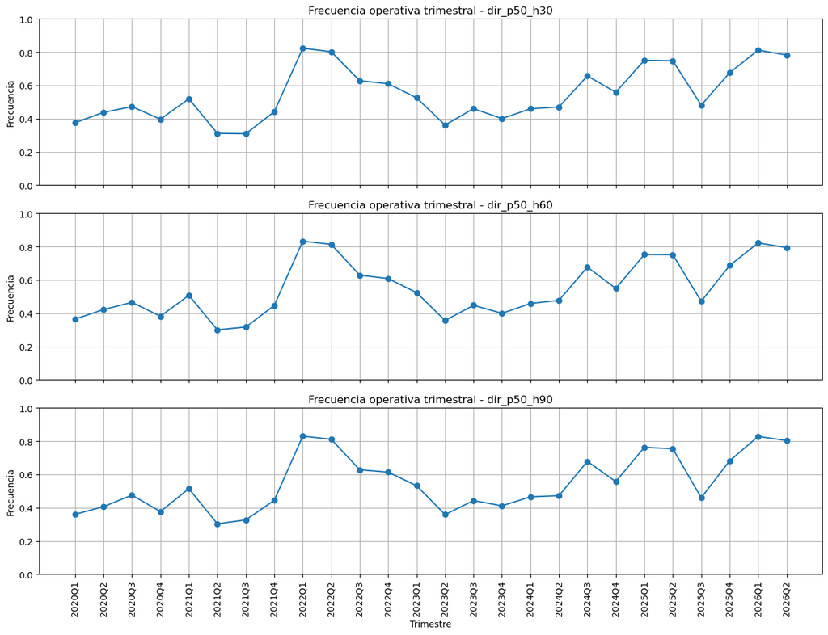

```python
# Celda 5.1 — Gráfico trimestral para variantes p50
# ============================================================

fig, axes = plt.subplots(
    nrows=3,
    ncols=1,
    figsize=(13, 10),
    sharex=True
)

for ax, target_col in zip(axes, selected_targets_temporal):
    tmp = df_dir_quarter_distribution[
        df_dir_quarter_distribution["target"] == target_col
    ].copy()

    tmp = tmp.sort_values("year_quarter")

    ax.plot(
        tmp["year_quarter"],
        tmp["signal_ratio"],
        marker="o"
    )

    ax.set_title(f"Frecuencia operativa trimestral - {target_col}")
    ax.set_ylabel("Frecuencia")
    ax.set_ylim(0, 1)
    ax.grid(True)

axes[-1].set_xlabel("Trimestre")
plt.xticks(rotation=90)

plt.tight_layout()
plt.show()
```

### Celda 6 — Períodos especiales: 2022, 2025Q2 y 2026

Esta celda extrae directamente los períodos que queremos mirar con más atención.

```python
# Celda 6 — Revisión de períodos especiales
# ============================================================

special_years = [2022, 2026]
special_quarters = ["2025Q2"]

df_special_years = df_dir_year_distribution[
    df_dir_year_distribution["year"].isin(special_years)
].copy()

df_special_quarters = df_dir_quarter_distribution[
    df_dir_quarter_distribution["year_quarter"].isin(special_quarters)
].copy()

print("Períodos especiales por año")
print("=" * 80)
print(
    df_special_years[
        ["target", "year", "signal_ratio", "no_signal_ratio", "long_share_over_signals"]
    ].to_string(index=False, float_format=lambda x: f"{x:.2%}")
)

print("\nPeríodos especiales por trimestre")
print("=" * 80)
print(
    df_special_quarters[
        ["target", "year_quarter", "signal_ratio", "no_signal_ratio", "long_share_over_signals"]
    ].to_string(index=False, float_format=lambda x: f"{x:.2%}")
)
```

```
Períodos especiales por año
================================================================================
     target  year  signal_ratio  no_signal_ratio  long_share_over_signals
dir_p40_h30  2022        80.47%           19.53%                   48.95%
dir_p40_h30  2026        87.07%           12.93%                   49.29%
dir_p50_h30  2022        71.69%           28.31%                   48.73%
dir_p50_h30  2026        80.69%           19.31%                   49.17%
dir_p60_h30  2022        61.37%           38.63%                   48.36%
dir_p60_h30  2026        72.84%           27.16%                   49.03%
dir_p40_h60  2022        81.41%           18.59%                   48.60%
dir_p40_h60  2026        88.27%           11.73%                   49.31%
dir_p50_h60  2022        72.19%           27.81%                   48.32%
dir_p50_h60  2026        81.76%           18.24%                   48.89%
dir_p60_h60  2022        61.58%           38.42%                   47.98%
dir_p60_h60  2026        74.09%           25.91%                   48.66%
dir_p40_h90  2022        81.27%           18.73%                   47.64%
dir_p40_h90  2026        88.54%           11.46%                   49.81%
dir_p50_h90  2022        72.19%           27.81%                   47.34%
dir_p50_h90  2026        82.42%           17.58%                   49.67%
dir_p60_h90  2022        61.63%           38.37%                   47.13%
dir_p60_h90  2026        74.59%           25.41%                   49.06%

Períodos especiales por trimestre
================================================================================
     target year_quarter  signal_ratio  no_signal_ratio  long_share_over_signals
dir_p40_h30       2025Q2        82.50%           17.50%                   52.12%
dir_p50_h30       2025Q2        74.83%           25.17%                   51.80%
dir_p60_h30       2025Q2        66.18%           33.82%                   51.43%
dir_p40_h60       2025Q2        82.95%           17.05%                   51.87%
dir_p50_h60       2025Q2        75.16%           24.84%                   51.35%
dir_p60_h60       2025Q2        66.00%           34.00%                   50.41%
dir_p40_h90       2025Q2        83.21%           16.79%                   52.41%
dir_p50_h90       2025Q2        75.47%           24.53%                   51.85%
dir_p60_h90       2025Q2        66.51%           33.49%                   51.03%
```

### Celda 7 — Métricas de estabilidad temporal

Esta celda resume qué targets son más o menos estables.

```python
# Celda 7 — Métricas de estabilidad temporal por target
# ============================================================

df_dir_year_stability = (
    df_dir_year_distribution
    .groupby(["target", "horizon", "percentile"], as_index=False)
    .agg(
        signal_mean=("signal_ratio", "mean"),
        signal_std=("signal_ratio", "std"),
        signal_min=("signal_ratio", "min"),
        signal_max=("signal_ratio", "max"),
        signal_range=("signal_ratio", lambda x: x.max() - x.min()),
        no_signal_mean=("no_signal_ratio", "mean"),
        long_share_mean=("long_share_over_signals", "mean"),
        long_share_range=("long_share_over_signals", lambda x: x.max() - x.min()),
    )
    .sort_values(["percentile", "horizon"])
    .reset_index(drop=True)
)

print("Métricas de estabilidad anual DIR")
print("=" * 80)
print(
    df_dir_year_stability.to_string(
        index=False,
        float_format=lambda x: f"{x:.2%}"
    )
)
```

```
Métricas de estabilidad anual DIR
================================================================================
     target  horizon  percentile  signal_mean  signal_std  signal_min  signal_max  signal_range  no_signal_mean  long_share_mean  long_share_range
dir_p40_h30       30          40       66.04%      14.94%      48.98%      87.07%        38.08%          33.96%           49.62%             2.18%
dir_p40_h60       60          40       66.30%      15.63%      48.84%      88.27%        39.42%          33.70%           49.63%             3.05%
dir_p40_h90       90          40       66.26%      15.65%      49.19%      88.54%        39.35%          33.74%           49.52%             4.87%
dir_p50_h30       30          50       56.79%      16.15%      39.53%      80.69%        41.15%          43.21%           49.03%             2.52%
dir_p50_h60       60          50       56.81%      16.79%      39.26%      81.76%        42.49%          43.19%           48.77%             2.99%
dir_p50_h90       90          50       57.03%      16.85%      39.73%      82.42%        42.70%          42.97%           48.75%             4.56%
dir_p60_h30       30          60       47.29%      16.49%      30.80%      72.84%        42.04%          52.71%           48.28%             2.63%
dir_p60_h60       60          60       47.27%      17.11%      30.21%      74.09%        43.88%          52.73%           47.81%             3.67%
dir_p60_h90       90          60       47.36%      17.33%      30.28%      74.59%        44.31%          52.64%           47.70%             4.92%
```

### Celda 8 — Conclusión automática simple

```python
# Celda 8 — Conclusión automática de estabilidad temporal
# ============================================================

print("Conclusiones preliminares - Estabilidad temporal DIR")
print("=" * 80)

print("\nTargets con menor rango anual de frecuencia operativa:")
print(
    df_dir_year_stability
    .sort_values("signal_range")
    [["target", "signal_mean", "signal_range", "signal_std"]]
    .head(5)
    .to_string(index=False, float_format=lambda x: f"{x:.2%}")
)

print("\nTargets con mayor rango anual de frecuencia operativa:")
print(
    df_dir_year_stability
    .sort_values("signal_range", ascending=False)
    [["target", "signal_mean", "signal_range", "signal_std"]]
    .head(5)
    .to_string(index=False, float_format=lambda x: f"{x:.2%}")
)

print("\nLectura general:")
print("- Un target estable debería mantener una frecuencia operativa relativamente parecida entre años.")
print("- Cambios fuertes en 2022, 2025Q2 o 2026 pueden indicar sensibilidad a regímenes de mercado extremos.")
print("- La comparación development vs final test permite revisar si el target cambia fuera de muestra.")
print("- p50 sigue siendo una variante importante para observar, pero todavía debe validarse temporalmente.")
```

```
Conclusiones preliminares - Estabilidad temporal DIR
================================================================================

Targets con menor rango anual de frecuencia operativa:
     target  signal_mean  signal_range  signal_std
dir_p40_h30       66.04%        38.08%      14.94%
dir_p40_h90       66.26%        39.35%      15.65%
dir_p40_h60       66.30%        39.42%      15.63%
dir_p50_h30       56.79%        41.15%      16.15%
dir_p60_h30       47.29%        42.04%      16.49%

Targets con mayor rango anual de frecuencia operativa:
     target  signal_mean  signal_range  signal_std
dir_p60_h90       47.36%        44.31%      17.33%
dir_p60_h60       47.27%        43.88%      17.11%
dir_p50_h90       57.03%        42.70%      16.85%
dir_p50_h60       56.81%        42.49%      16.79%
dir_p60_h30       47.29%        42.04%      16.49%

Lectura general:
- Un target estable debería mantener una frecuencia operativa relativamente parecida entre años.
- Cambios fuertes en 2022, 2025Q2 o 2026 pueden indicar sensibilidad a regímenes de mercado extremos.
- La comparación development vs final test permite revisar si el target cambia fuera de muestra.
- p50 sigue siendo una variante importante para observar, pero todavía debe validarse temporalmente.
```

### Observaciones preliminares - Estabilidad Temporal

1. **Hay una diferencia fuerte entre development y final test.** En `2025-2026` la frecuencia operativa sube mucho frente a `2020-2024`. Por ejemplo, en `dir_p50_h30` pasa de **50.24%** a **69.51%**. Esto indica que el período final tuvo movimientos mucho más frecuentes o intensos respecto al período usado para calibrar thresholds.
2. **El target no es temporalmente estable en frecuencia.** Los rangos anuales son altos, entre **38% y 44%** según el target. Eso significa que `DIR` cambia bastante de comportamiento según el año.
3. **2022 es un año claramente más activo.** En 2022, incluso `p60` supera el **61%** de frecuencia operativa. Esto confirma que fue un año de alta volatilidad / mayor movimiento relativo.
4. **2026 es todavía más extremo.** En 2026, `p50` está alrededor de **80%–82%** y `p60` alrededor de **73%–75%**. Esto es muy alto. Hay que tratarlo como período de estrés, además de recordar que 2026 está incompleto.
5. **2021 fue el período menos activo.** En 2021, `p50` ronda solo **39%–40%** y `p60` cerca de **30%**. Esto muestra que el target puede generar muy pocas señales en años más tranquilos.
6. **Trimestralmente se ven cambios fuertes.** `2022Q1`, `2022Q2`, `2025Q2` y `2026Q1` aparecen como períodos de alta frecuencia operativa. En cambio, `2021Q2` y `2021Q3` son períodos mucho más débiles.
7. **El balance LONG/SHORT se mantiene bastante bien.** Aunque la frecuencia cambia mucho, `long_share_over_signals` se mantiene cerca del **48%–50%**. Esto es positivo: el target no se vuelve extremadamente sesgado hacia LONG o SHORT.
8. **El problema principal no es el balance direccional, sino la estabilidad temporal.** `DIR` parece balanceado en dirección, pero su cantidad de señales depende mucho del régimen de mercado de cada año.
9. **Lectura preliminar:** `p50` sigue siendo una buena variante intermedia, pero no puede considerarse estable todavía. Necesitamos seguir revisando por régimen, contrato y contexto antes de decidir si es un target candidato fuerte.

Conclusión rápida: **DIR funciona bien conceptualmente, pero la frecuencia operativa es sensible al contexto temporal. Esto confirma que el mercado cambió bastante entre 2020-2026 y que el análisis por año/régimen/contrato es necesario antes de modelar.**

## 3.7. Análisis por régimen intradiario

En este punto se analizará el comportamiento de `DIR` por régimen intradiario.

Los regímenes considerados serán:

```
    Overnight
    Pre-market
    Opening
    Regular
    Closing
```

Para cada régimen se evaluará:

```
    distribución de clases
    frecuencia operativa
    proporción LONG
    proporción SHORT
    proporción NO SIGNAL
```

Este análisis es importante porque el MNQ no se comporta igual durante toda la sesión. Algunos regímenes pueden presentar más volatilidad, más direccionalidad o mayor frecuencia de movimientos significativos.

El objetivo será identificar si `DIR` es más claro, estable u operable en ciertos momentos del día.

### Celda 1 — Configuración del análisis por régimen

Esta celda solo prepara el análisis y asegura que exista `regime_name`.

```python
# Celda 1 — Configuración
# ============================================================

import re
import numpy as np
import pandas as pd
import matplotlib.pyplot as plt

REGIME_ORDER = [
    "Overnight",
    "Pre-market",
    "Opening",
    "Regular",
    "Closing"
]

REGIME_NAME_BY_ID = {
    0: "Overnight",
    1: "Pre-market",
    2: "Opening",
    3: "Regular",
    4: "Closing",
}

# Asegurar columna regime_name
if "regime_name" not in df_targets_dir.columns:
    df_targets_dir["regime_name"] = df_targets_dir["regime_id"].map(REGIME_NAME_BY_ID)

df_targets_dir["regime_name"] = pd.Categorical(
    df_targets_dir["regime_name"],
    categories=REGIME_ORDER,
    ordered=True
)

# Asegurar columna split temporal
if "target_analysis_split" not in df_targets_dir.columns:
    if "year" not in df_targets_dir.columns:
        df_targets_dir["year"] = df_targets_dir.index.year

    df_targets_dir["target_analysis_split"] = np.where(
        df_targets_dir["year"].between(2020, 2024),
        "development_2020_2024",
        "final_test_2025_2026"
    )

# Targets DIR esperados
dir_target_cols = [
    f"dir_p{p}_h{h}"
    for h in DIR_HORIZONS
    for p in DIR_PERCENTILES
]

missing_cols = [
    col for col in dir_target_cols
    if col not in df_targets_dir.columns
]

if missing_cols:
    raise KeyError(f"Faltan columnas DIR: {missing_cols}")

# Función auxiliar por si no quedó definida antes
def parse_dir_target_name(target_col):
    pattern = r"dir_p(?P<percentile>\d+)_h(?P<horizon>\d+)"
    match = re.match(pattern, target_col)

    if match is None:
        raise ValueError(f"No se pudo interpretar el target: {target_col}")

    return int(match.group("horizon")), int(match.group("percentile"))

print("Configuración del análisis por régimen lista.")
print("=" * 80)
print(f"Targets a analizar: {len(dir_target_cols)}")
print(f"Regímenes: {REGIME_ORDER}")
print(f"Splits: {df_targets_dir['target_analysis_split'].unique().tolist()}")
```

```
Configuración del análisis por régimen lista.
================================================================================
Targets a analizar: 9
Regímenes: ['Overnight', 'Pre-market', 'Opening', 'Regular', 'Closing']
Splits: ['development_2020_2024', 'final_test_2025_2026']
```

### Celda 2 — Función de resumen por régimen

```python
# Celda 2 — Función para resumir DIR por régimen
# ============================================================

def summarize_dir_by_group(df, target_cols, group_cols):
    """
    Resume la distribución de clases DIR por una o más columnas de agrupación.

    group_cols puede ser:
        ["regime_name"]
        ["regime_name", "target_analysis_split"]
    """

    rows = []

    for target_col in target_cols:
        horizon, percentile = parse_dir_target_name(target_col)

        grouped = df.groupby(group_cols, observed=False)

        for group_key, group in grouped:
            if not isinstance(group_key, tuple):
                group_key = (group_key,)

            group_info = dict(zip(group_cols, group_key))

            total_rows = len(group)

            valid_mask = group[target_col].notna()
            valid_values = group.loc[valid_mask, target_col].astype(int)

            valid_rows = valid_mask.sum()
            nan_rows = total_rows - valid_rows

            long_count = (valid_values == 1).sum()
            short_count = (valid_values == -1).sum()
            no_signal_count = (valid_values == 0).sum()

            signal_count = long_count + short_count

            row = {
                "target": target_col,
                "horizon": horizon,
                "percentile": percentile,
                "total_rows": total_rows,
                "valid_rows": valid_rows,
                "nan_rows": nan_rows,
                "long_count": long_count,
                "short_count": short_count,
                "no_signal_count": no_signal_count,
                "signal_count": signal_count,
                "long_ratio": long_count / valid_rows if valid_rows > 0 else np.nan,
                "short_ratio": short_count / valid_rows if valid_rows > 0 else np.nan,
                "no_signal_ratio": no_signal_count / valid_rows if valid_rows > 0 else np.nan,
                "signal_ratio": signal_count / valid_rows if valid_rows > 0 else np.nan,
                "long_share_over_signals": (
                    long_count / signal_count if signal_count > 0 else np.nan
                ),
                "short_share_over_signals": (
                    short_count / signal_count if signal_count > 0 else np.nan
                ),
            }

            row.update(group_info)
            rows.append(row)

    summary = pd.DataFrame(rows)

    if "regime_name" in summary.columns:
        summary["regime_name"] = pd.Categorical(
            summary["regime_name"],
            categories=REGIME_ORDER,
            ordered=True
        )

    sort_cols = ["horizon", "percentile"] + group_cols

    summary = (
        summary
        .sort_values(sort_cols)
        .reset_index(drop=True)
    )

    return summary

print("Función de resumen por grupo lista.")
```

```
Función de resumen por grupo lista.
```

### Celda 3 — Distribución global de DIR por régimen

```python
# Celda 3 — Distribución global de DIR por régimen
# ============================================================

df_dir_regime_distribution = summarize_dir_by_group(
    df=df_targets_dir,
    target_cols=dir_target_cols,
    group_cols=["regime_name"]
)

print("Distribución global de DIR por régimen intradiario")
print("=" * 80)

cols_show = [
    "target",
    "horizon",
    "percentile",
    "regime_name",
    "valid_rows",
    "nan_rows",
    "long_ratio",
    "short_ratio",
    "no_signal_ratio",
    "signal_ratio",
    "long_share_over_signals",
]

print(
    df_dir_regime_distribution[cols_show]
    .to_string(index=False, float_format=lambda x: f"{x:.2%}")
)
```

```
Distribución global de DIR por régimen intradiario
================================================================================
     target  horizon  percentile regime_name  valid_rows  nan_rows  long_ratio  short_ratio  no_signal_ratio  signal_ratio  long_share_over_signals
dir_p40_h30       30          40   Overnight      355680      1482      31.87%       32.03%           36.11%        63.89%                   49.87%
dir_p40_h30       30          40  Pre-market       88920         0      31.27%       32.44%           36.29%        63.71%                   49.08%
dir_p40_h30       30          40     Opening       88920         0      31.58%       32.49%           35.93%        64.07%                   49.29%
dir_p40_h30       30          40     Regular      444600         0      31.44%       31.97%           36.59%        63.41%                   49.59%
dir_p40_h30       30          40     Closing        1482     42978      31.04%       32.66%           36.30%        63.70%                   48.73%
dir_p50_h30       30          50   Overnight      355680      1482      26.80%       27.45%           45.76%        54.24%                   49.40%
dir_p50_h30       30          50  Pre-market       88920         0      26.33%       27.77%           45.90%        54.10%                   48.67%
dir_p50_h30       30          50     Opening       88920         0      26.33%       28.04%           45.63%        54.37%                   48.42%
dir_p50_h30       30          50     Regular      444600         0      26.40%       27.53%           46.06%        53.94%                   48.95%
dir_p50_h30       30          50     Closing        1482     42978      25.91%       27.13%           46.96%        53.04%                   48.85%
dir_p60_h30       30          60   Overnight      355680      1482      21.97%       23.04%           54.99%        45.01%                   48.82%
dir_p60_h30       30          60  Pre-market       88920         0      21.36%       22.64%           56.00%        44.00%                   48.54%
dir_p60_h30       30          60     Opening       88920         0      21.09%       23.48%           55.42%        44.58%                   47.32%
dir_p60_h30       30          60     Regular      444600         0      21.13%       22.84%           56.03%        43.97%                   48.06%
dir_p60_h30       30          60     Closing        1482     42978      21.46%       21.86%           56.68%        43.32%                   49.53%
dir_p40_h60       60          40   Overnight      355680      1482      31.91%       32.17%           35.92%        64.08%                   49.80%
dir_p40_h60       60          40  Pre-market       88920         0      31.64%       32.46%           35.90%        64.10%                   49.37%
dir_p40_h60       60          40     Opening       88920         0      31.46%       32.79%           35.75%        64.25%                   48.96%
dir_p40_h60       60          40     Regular      401622     42978      31.51%       31.98%           36.51%        63.49%                   49.63%
dir_p40_h60       60          40     Closing           0     44460         NaN          NaN              NaN           NaN                      NaN
dir_p50_h60       60          50   Overnight      355680      1482      26.74%       27.52%           45.74%        54.26%                   49.29%
dir_p50_h60       60          50  Pre-market       88920         0      26.70%       27.98%           45.32%        54.68%                   48.83%
dir_p50_h60       60          50     Opening       88920         0      26.03%       28.39%           45.58%        54.42%                   47.84%
dir_p50_h60       60          50     Regular      401622     42978      25.96%       27.58%           46.46%        53.54%                   48.49%
dir_p50_h60       60          50     Closing           0     44460         NaN          NaN              NaN           NaN                      NaN
dir_p60_h60       60          60   Overnight      355680      1482      21.42%       22.86%           55.72%        44.28%                   48.37%
dir_p60_h60       60          60  Pre-market       88920         0      22.13%       22.97%           54.90%        45.10%                   49.08%
dir_p60_h60       60          60     Opening       88920         0      20.87%       23.92%           55.21%        44.79%                   46.60%
dir_p60_h60       60          60     Regular      401622     42978      20.78%       23.13%           56.09%        43.91%                   47.33%
```

[output cut: 16 more lines]

### Celda 4 — Matriz y heatmap de frecuencia operativa por régimen

```python
# Celda 4 — Frecuencia operativa por régimen y target
# ============================================================

df_regime_signal_matrix = df_dir_regime_distribution.copy()

df_regime_signal_matrix["target_label"] = (
    "H" + df_regime_signal_matrix["horizon"].astype(str)
    + " p" + df_regime_signal_matrix["percentile"].astype(str)
)

signal_pivot_regime = df_regime_signal_matrix.pivot(
    index="regime_name",
    columns="target_label",
    values="signal_ratio"
)

print("Frecuencia operativa por régimen y target")
print("=" * 80)
print(signal_pivot_regime.to_string(float_format=lambda x: f"{x:.2%}"))
```

```
Frecuencia operativa por régimen y target
================================================================================
target_label  H30 p40  H30 p50  H30 p60  H60 p40  H60 p50  H60 p60  H90 p40  H90 p50  H90 p60
regime_name
Overnight      63.89%   54.24%   45.01%   64.08%   54.26%   44.28%   63.87%   54.30%   44.19%
Pre-market     63.71%   54.10%   44.00%   64.10%   54.68%   45.10%   64.33%   55.05%   45.43%
Opening        64.07%   54.37%   44.58%   64.25%   54.42%   44.79%   64.19%   54.61%   44.77%
Regular        63.41%   53.94%   43.97%   63.49%   53.54%   43.91%   63.42%   53.75%   43.99%
Closing        63.70%   53.04%   43.32%      NaN      NaN      NaN      NaN      NaN      NaN
```

### Celda 5 — Distribución de clases por régimen para p50

Usamos `p50` como variante central para evitar saturar el análisis con demasiados gráficos.

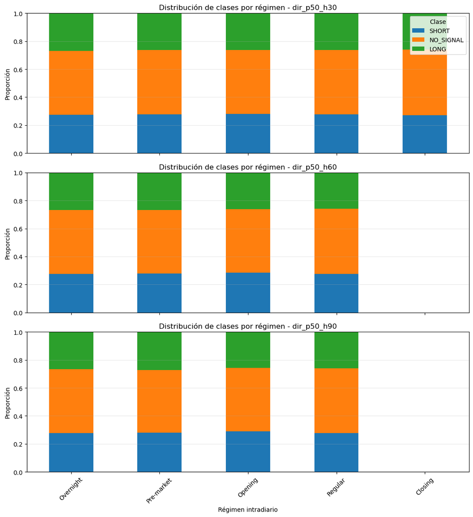

```python
# Celda 5 — Distribución de clases por régimen para p50
# Gráfico agrupado: 3 filas x 1 columna
# ============================================================

selected_targets_regime = [
    "dir_p50_h30",
    "dir_p50_h60",
    "dir_p50_h90",
]

fig, axes = plt.subplots(
    nrows=3,
    ncols=1,
    figsize=(11, 12),
    sharex=True
)

for ax, target_col in zip(axes, selected_targets_regime):
    tmp = df_dir_regime_distribution[
        df_dir_regime_distribution["target"] == target_col
    ].copy()

    tmp = tmp.sort_values("regime_name")

    plot_data = tmp.set_index("regime_name")[
        ["short_ratio", "no_signal_ratio", "long_ratio"]
    ]

    plot_data.plot(
        kind="bar",
        stacked=True,
        ax=ax,
        legend=False
    )

    ax.set_title(f"Distribución de clases por régimen - {target_col}")
    ax.set_xlabel("")
    ax.set_ylabel("Proporción")
    ax.set_ylim(0, 1)
    ax.grid(axis="y", alpha=0.3)

axes[0].legend(
    ["SHORT", "NO_SIGNAL", "LONG"],
    title="Clase",
    loc="upper right"
)

axes[-1].set_xlabel("Régimen intradiario")

plt.xticks(rotation=45)
plt.tight_layout()
plt.show()
```

### Celda 6 — Balance LONG/SHORT por régimen para p50

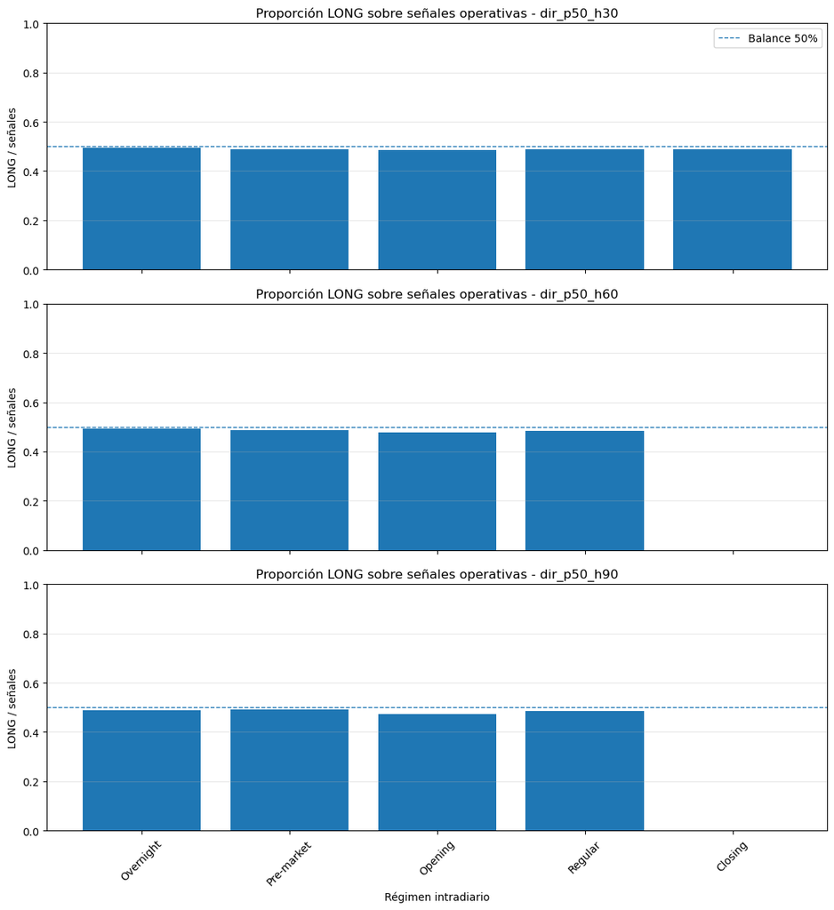

```python
# Celda 6 — Balance LONG/SHORT por régimen para p50
# Gráfico agrupado: 3 filas x 1 columna
# ============================================================

fig, axes = plt.subplots(
    nrows=3,
    ncols=1,
    figsize=(11, 12),
    sharex=True
)

for ax, target_col in zip(axes, selected_targets_regime):
    tmp = df_dir_regime_distribution[
        df_dir_regime_distribution["target"] == target_col
    ].copy()

    tmp = tmp.sort_values("regime_name")

    ax.bar(
        tmp["regime_name"].astype(str),
        tmp["long_share_over_signals"]
    )

    ax.axhline(
        0.50,
        linestyle="--",
        linewidth=1,
        label="Balance 50%"
    )

    ax.set_title(f"Proporción LONG sobre señales operativas - {target_col}")
    ax.set_xlabel("")
    ax.set_ylabel("LONG / señales")
    ax.set_ylim(0, 1)
    ax.grid(axis="y", alpha=0.3)

axes[0].legend(loc="upper right")
axes[-1].set_xlabel("Régimen intradiario")

plt.xticks(rotation=45)
plt.tight_layout()
plt.show()
```

### Celda 7 — Régimen + split temporal

Esta es la parte nueva importante. Permite ver si el aumento de frecuencia en `2025-2026` ocurre en todos los regímenes.

```python
# Celda 7 — Distribución por régimen y split temporal
# ============================================================

df_dir_regime_split_distribution = summarize_dir_by_group(
    df=df_targets_dir,
    target_cols=dir_target_cols,
    group_cols=["regime_name", "target_analysis_split"]
)

print("Distribución de DIR por régimen y split temporal")
print("=" * 80)

cols_show = [
    "target",
    "horizon",
    "percentile",
    "regime_name",
    "target_analysis_split",
    "valid_rows",
    "nan_rows",
    "signal_ratio",
    "no_signal_ratio",
    "long_share_over_signals",
]

print(
    df_dir_regime_split_distribution[cols_show]
    .to_string(index=False, float_format=lambda x: f"{x:.2%}")
)
```

```
Distribución de DIR por régimen y split temporal
================================================================================
     target  horizon  percentile regime_name target_analysis_split  valid_rows  nan_rows  signal_ratio  no_signal_ratio  long_share_over_signals
dir_p40_h30       30          40   Overnight development_2020_2024      284400      1185        59.98%           40.02%                   49.80%
dir_p40_h30       30          40   Overnight  final_test_2025_2026       71280       297        79.50%           20.50%                   50.10%
dir_p40_h30       30          40  Pre-market development_2020_2024       71100         0        60.37%           39.63%                   49.20%
dir_p40_h30       30          40  Pre-market  final_test_2025_2026       17820         0        77.06%           22.94%                   48.70%
dir_p40_h30       30          40     Opening development_2020_2024       71100         0        60.21%           39.79%                   48.71%
dir_p40_h30       30          40     Opening  final_test_2025_2026       17820         0        79.47%           20.53%                   51.07%
dir_p40_h30       30          40     Regular development_2020_2024      355500         0        60.33%           39.67%                   49.73%
dir_p40_h30       30          40     Regular  final_test_2025_2026       89100         0        75.69%           24.31%                   49.14%
dir_p40_h30       30          40     Closing development_2020_2024        1185     34365        60.42%           39.58%                   48.32%
dir_p40_h30       30          40     Closing  final_test_2025_2026         297      8613        76.77%           23.23%                   50.00%
dir_p50_h30       30          50   Overnight development_2020_2024      284400      1185        49.98%           50.02%                   49.27%
dir_p50_h30       30          50   Overnight  final_test_2025_2026       71280       297        71.27%           28.73%                   49.76%
dir_p50_h30       30          50  Pre-market development_2020_2024       71100         0        50.38%           49.62%                   48.73%
dir_p50_h30       30          50  Pre-market  final_test_2025_2026       17820         0        68.97%           31.03%                   48.50%
dir_p50_h30       30          50     Opening development_2020_2024       71100         0        50.11%           49.89%                   47.66%
dir_p50_h30       30          50     Opening  final_test_2025_2026       17820         0        71.38%           28.62%                   50.57%
dir_p50_h30       30          50     Regular development_2020_2024      355500         0        50.45%           49.55%                   48.99%
dir_p50_h30       30          50     Regular  final_test_2025_2026       89100         0        67.85%           32.15%                   48.84%
dir_p50_h30       30          50     Closing development_2020_2024        1185     34365        50.21%           49.79%                   47.73%
dir_p50_h30       30          50     Closing  final_test_2025_2026         297      8613        64.31%           35.69%                   52.36%
dir_p60_h30       30          60   Overnight development_2020_2024      284400      1185        40.62%           59.38%                   48.62%
dir_p60_h30       30          60   Overnight  final_test_2025_2026       71280       297        62.51%           37.49%                   49.33%
dir_p60_h30       30          60  Pre-market development_2020_2024       71100         0        40.09%           59.91%                   48.71%
dir_p60_h30       30          60  Pre-market  final_test_2025_2026       17820         0        59.60%           40.40%                   48.09%
dir_p60_h30       30          60     Opening development_2020_2024       71100         0        39.99%           60.01%                   46.25%
dir_p60_h30       30          60     Opening  final_test_2025_2026       17820         0        62.87%           37.13%                   50.03%
dir_p60_h30       30          60     Regular development_2020_2024      355500         0        40.18%           59.82%                   47.94%
dir_p60_h30       30          60     Regular  final_test_2025_2026       89100         0        59.09%           40.91%                   48.37%
dir_p60_h30       30          60     Closing development_2020_2024        1185     34365        40.25%           59.75%                   47.80%
dir_p60_h30       30          60     Closing  final_test_2025_2026         297      8613        55.56%           44.44%                   54.55%
dir_p40_h60       60          40   Overnight development_2020_2024      284400      1185        60.13%           39.87%                   49.70%
dir_p40_h60       60          40   Overnight  final_test_2025_2026       71280       297        79.84%           20.16%                   50.09%
dir_p40_h60       60          40  Pre-market development_2020_2024       71100         0        60.11%           39.89%                   49.40%
dir_p40_h60       60          40  Pre-market  final_test_2025_2026       17820         0        80.01%           19.99%                   49.26%
dir_p40_h60       60          40     Opening development_2020_2024       71100         0        60.20%           39.80%                   48.63%
dir_p40_h60       60          40     Opening  final_test_2025_2026       17820         0        80.38%           19.62%                   49.95%
dir_p40_h60       60          40     Regular development_2020_2024      321135     34365        60.34%           39.66%                   49.79%
```

[output cut: 38 more lines]

```
dir_p50_h90       90          50     Opening  final_test_2025_2026       17820         0        72.17%           27.83%                   48.52%
dir_p50_h90       90          50     Regular development_2020_2024      285585     69915        50.15%           49.85%                   48.51%
dir_p50_h90       90          50     Regular  final_test_2025_2026       71577     17523        68.11%           31.89%                   48.32%
dir_p50_h90       90          50     Closing development_2020_2024           0     35550           NaN              NaN                      NaN
dir_p50_h90       90          50     Closing  final_test_2025_2026           0      8910           NaN              NaN                      NaN
dir_p60_h90       90          60   Overnight development_2020_2024      284400      1185        40.05%           59.95%                   48.26%
dir_p60_h90       90          60   Overnight  final_test_2025_2026       71280       297        60.70%           39.30%                   48.84%
dir_p60_h90       90          60  Pre-market development_2020_2024       71100         0        40.07%           59.93%                   47.42%
dir_p60_h90       90          60  Pre-market  final_test_2025_2026       17820         0        66.81%           33.19%                   50.96%
dir_p60_h90       90          60     Opening development_2020_2024       71100         0        40.13%           59.87%                   45.02%
dir_p60_h90       90          60     Opening  final_test_2025_2026       17820         0        63.30%           36.70%                   47.64%
dir_p60_h90       90          60     Regular development_2020_2024      285585     69915        40.11%           59.89%                   47.02%
dir_p60_h90       90          60     Regular  final_test_2025_2026       71577     17523        59.48%           40.52%                   47.00%
dir_p60_h90       90          60     Closing development_2020_2024           0     35550           NaN              NaN                      NaN
dir_p60_h90       90          60     Closing  final_test_2025_2026           0      8910           NaN              NaN                      NaN
```

### Celda 8 — Comparación development vs final test por régimen para p50

```python
# Celda 8 — Comparación régimen + split para p50
# ============================================================

df_p50_regime_split = df_dir_regime_split_distribution[
    df_dir_regime_split_distribution["target"].isin(selected_targets_regime)
].copy()

for target_col in selected_targets_regime:
    tmp = df_p50_regime_split[
        df_p50_regime_split["target"] == target_col
    ].copy()

    pivot_tmp = tmp.pivot(
        index="regime_name",
        columns="target_analysis_split",
        values="signal_ratio"
    )

    if (
        "development_2020_2024" in pivot_tmp.columns
        and "final_test_2025_2026" in pivot_tmp.columns
    ):
        pivot_tmp["difference_final_minus_dev"] = (
            pivot_tmp["final_test_2025_2026"]
            - pivot_tmp["development_2020_2024"]
        )

    print(f"\nFrecuencia operativa por régimen y split - {target_col}")
    print("=" * 80)
    print(pivot_tmp.to_string(float_format=lambda x: f"{x:.2%}"))
```

```
Frecuencia operativa por régimen y split - dir_p50_h30
================================================================================
target_analysis_split  development_2020_2024  final_test_2025_2026  difference_final_minus_dev
regime_name
Overnight                             49.98%                71.27%                      21.29%
Pre-market                            50.38%                68.97%                      18.60%
Opening                               50.11%                71.38%                      21.27%
Regular                               50.45%                67.85%                      17.40%
Closing                               50.21%                64.31%                      14.10%

Frecuencia operativa por régimen y split - dir_p50_h60
================================================================================
target_analysis_split  development_2020_2024  final_test_2025_2026  difference_final_minus_dev
regime_name
Overnight                             50.06%                71.00%                      20.93%
Pre-market                            50.10%                72.93%                      22.83%
Opening                               50.00%                72.05%                      22.05%
Regular                               49.99%                67.69%                      17.70%
Closing                                  NaN                   NaN                         NaN

Frecuencia operativa por régimen y split - dir_p50_h90
================================================================================
target_analysis_split  development_2020_2024  final_test_2025_2026  difference_final_minus_dev
regime_name
Overnight                             50.35%                70.05%                      19.69%
Pre-market                            50.09%                74.84%                      24.75%
Opening                               50.20%                72.17%                      21.97%
Regular                               50.15%                68.11%                      17.96%
Closing                                  NaN                   NaN                         NaN
```

### Celda 9 — Gráfico development vs final test por régimen para p50

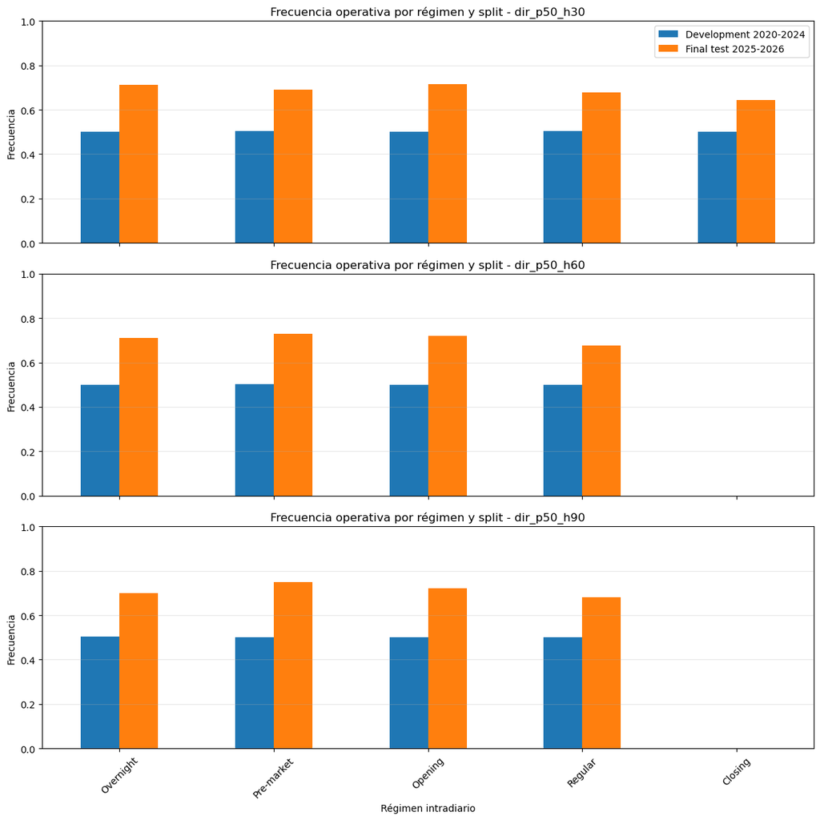

```python
# Celda 9 — Gráfico régimen + split para p50
# Gráfico agrupado: 3 filas x 1 columna
# ============================================================

fig, axes = plt.subplots(
    nrows=3,
    ncols=1,
    figsize=(12, 12),
    sharex=True
)

for ax, target_col in zip(axes, selected_targets_regime):
    tmp = df_p50_regime_split[
        df_p50_regime_split["target"] == target_col
    ].copy()

    pivot_tmp = tmp.pivot(
        index="regime_name",
        columns="target_analysis_split",
        values="signal_ratio"
    )

    pivot_tmp = pivot_tmp.reindex(REGIME_ORDER)

    plot_cols = [
        col for col in [
            "development_2020_2024",
            "final_test_2025_2026"
        ]
        if col in pivot_tmp.columns
    ]

    pivot_tmp[plot_cols].plot(
        kind="bar",
        ax=ax,
        legend=False
    )

    ax.set_title(f"Frecuencia operativa por régimen y split - {target_col}")
    ax.set_xlabel("")
    ax.set_ylabel("Frecuencia")
    ax.set_ylim(0, 1)
    ax.grid(axis="y", alpha=0.3)

axes[0].legend(
    ["Development 2020-2024", "Final test 2025-2026"],
    loc="upper right"
)

axes[-1].set_xlabel("Régimen intradiario")

plt.xticks(rotation=45)
plt.tight_layout()
plt.show()
```

### Celda 10 — Revisión especial de Closing

```python
# Celda 10 — Revisión especial del régimen Closing
# ============================================================

df_closing_check = df_dir_regime_distribution[
    df_dir_regime_distribution["regime_name"] == "Closing"
].copy()

print("Revisión especial del régimen Closing")
print("=" * 80)

cols_show = [
    "target",
    "horizon",
    "percentile",
    "total_rows",
    "valid_rows",
    "nan_rows",
    "signal_ratio",
    "no_signal_ratio",
]

print(
    df_closing_check[cols_show]
    .to_string(index=False, float_format=lambda x: f"{x:.2%}")
)

print("\nLectura:")
print("- Closing puede tener pocas observaciones válidas porque está cerca del cierre del día.")
print("- Para H60 y H90 es esperable que Closing no tenga ventana futura suficiente.")
print("- Por este motivo, Closing debe interpretarse con cuidado y probablemente limitarse a H30.")
```

```
Revisión especial del régimen Closing
================================================================================
     target  horizon  percentile  total_rows  valid_rows  nan_rows  signal_ratio  no_signal_ratio
dir_p40_h30       30          40       44460        1482     42978        63.70%           36.30%
dir_p50_h30       30          50       44460        1482     42978        53.04%           46.96%
dir_p60_h30       30          60       44460        1482     42978        43.32%           56.68%
dir_p40_h60       60          40       44460           0     44460           NaN              NaN
dir_p50_h60       60          50       44460           0     44460           NaN              NaN
dir_p60_h60       60          60       44460           0     44460           NaN              NaN
dir_p40_h90       90          40       44460           0     44460           NaN              NaN
dir_p50_h90       90          50       44460           0     44460           NaN              NaN
dir_p60_h90       90          60       44460           0     44460           NaN              NaN

Lectura:
- Closing puede tener pocas observaciones válidas porque está cerca del cierre del día.
- Para H60 y H90 es esperable que Closing no tenga ventana futura suficiente.
- Por este motivo, Closing debe interpretarse con cuidado y probablemente limitarse a H30.
```

### Celda 11 — Resumen automático del punto 3.7

```python
# Celda 11 — Resumen automático por régimen
# ============================================================

print("Resumen por régimen intradiario - DIR")
print("=" * 80)

for regime in REGIME_ORDER:
    tmp = df_dir_regime_distribution[
        df_dir_regime_distribution["regime_name"] == regime
    ].copy()

    avg_signal = tmp["signal_ratio"].mean()
    avg_no_signal = tmp["no_signal_ratio"].mean()
    avg_long_share = tmp["long_share_over_signals"].mean()
    total_valid = tmp["valid_rows"].sum()

    print(f"\nRégimen: {regime}")
    print(f"  Frecuencia operativa promedio: {avg_signal:.2%}")
    print(f"  NO_SIGNAL promedio:            {avg_no_signal:.2%}")
    print(f"  LONG sobre señales promedio:   {avg_long_share:.2%}")
    print(f"  Filas válidas acumuladas:      {total_valid:,}")

print("\nLectura general:")
print("- Se evalúa si DIR genera más o menos señales según el momento del día.")
print("- Se revisa si el balance LONG/SHORT se mantiene cerca de 50%.")
print("- Se compara development vs final test para ver si el aumento de señales ocurre en todos los regímenes.")
print("- Closing se analiza por separado porque puede no tener ventana futura válida para H60 y H90.")
```

```
Resumen por régimen intradiario - DIR
================================================================================

Régimen: Overnight
  Frecuencia operativa promedio: 54.24%
  NO_SIGNAL promedio:            45.76%
  LONG sobre señales promedio:   49.15%
  Filas válidas acumuladas:      3,201,120

Régimen: Pre-market
  Frecuencia operativa promedio: 54.50%
  NO_SIGNAL promedio:            45.50%
  LONG sobre señales promedio:   48.99%
  Filas válidas acumuladas:      800,280

Régimen: Opening
  Frecuencia operativa promedio: 54.45%
  NO_SIGNAL promedio:            45.55%
  LONG sobre señales promedio:   47.77%
  Filas válidas acumuladas:      800,280

Régimen: Regular
  Frecuencia operativa promedio: 53.71%
  NO_SIGNAL promedio:            46.29%
  LONG sobre señales promedio:   48.56%
  Filas válidas acumuladas:      3,610,152

Régimen: Closing
  Frecuencia operativa promedio: 53.35%
  NO_SIGNAL promedio:            46.65%
  LONG sobre señales promedio:   49.04%
  Filas válidas acumuladas:      4,446

Lectura general:
- Se evalúa si DIR genera más o menos señales según el momento del día.
- Se revisa si el balance LONG/SHORT se mantiene cerca de 50%.
- Se compara development vs final test para ver si el aumento de señales ocurre en todos los regímenes.
- Closing se analiza por separado porque puede no tener ventana futura válida para H60 y H90.
```

### Observaciones preliminares - Análisis por régimen intradiario

1. **A nivel global, DIR es bastante estable por régimen.** Las frecuencias operativas son muy parecidas entre `Overnight`, `Pre-market`, `Opening` y `Regular`.
2. **No hay un régimen claramente dominante.** Para `p50`, la frecuencia ronda aproximadamente el **54%** en casi todos los regímenes. Esto indica que el target no depende excesivamente del momento del día.
3. **Pre-market y Opening son levemente más activos.** Tienen una frecuencia operativa algo superior, especialmente en `H60` y `H90`, pero la diferencia no es muy grande.
4. **Regular es apenas menos activo.** Presenta frecuencias un poco más bajas, aunque sigue estando muy cerca del resto de regímenes.
5. **El balance LONG/SHORT se mantiene razonable.** La proporción LONG sobre señales operativas se mantiene cerca del **50%**, con una leve inclinación hacia `SHORT`.
6. **Opening muestra algo más de sesgo hacia SHORT.** Especialmente en `p60` y horizontes largos, la proporción LONG baja un poco más que en otros regímenes.
7. **El aumento en final test ocurre en todos los regímenes.** En `2025-2026`, la frecuencia operativa sube claramente frente a `2020-2024` en todos los regímenes. Por lo tanto, el cambio no está concentrado en un solo momento del día.
8. **Pre-market y Opening aumentan bastante en final test.** En `p50`, varios casos suben más de **20 puntos porcentuales**, confirmando que estos regímenes fueron mucho más activos fuera de muestra.
9. **Closing debe tratarse aparte.** Para `H60` y `H90` no tiene observaciones válidas, porque no hay suficiente ventana futura antes del cierre del día. Para `H30` sí existe, pero con pocas filas válidas.
10. **Conclusión preliminar:** `DIR` se comporta de forma bastante consistente por régimen intradiario, pero el efecto temporal visto en `2025-2026` impacta a todos los regímenes. El régimen no parece ser la principal fuente de inestabilidad; la mayor diferencia viene del cambio de contexto temporal.